# 01_Code securitycopy

### **Information**

```
- Author: Lenon Ferreira
- University: Justus-Liebig
- Subject: Time Series - 2022
- Professor: Prof. Dr. Peter Winker
- Supervisor: Jenny Bethäuser
```

File accompanies following study: Term Paper

**Foreword: The Chapter and Sections of this file do not correspond to the Sections of the written paper. Neverthless, all codes and tables are found here!<\font>**

# **VAR-Estimation: The Relation between Russia's Economic Growth and Oil Price | Time Series 2022**

## **Ch. 0 | Import of Modules, Functions, Libraries and Dataset**

### **0.1. Libraries, Functions and Modules**

```python
import pandas as pd
import matplotlib.pyplot as plt
import matplotlib as mpl
import matplotlib.dates as mdates
import matplotlib.gridspec as gridspec
import numpy as np
import TSFunctions as fc
from statsmodels.tsa.api import VAR
from statsmodels.tsa.stattools import adfuller
from statsmodels.tools.eval_measures import rmse, aic
from statsmodels.tsa.stattools import coint
import statsmodels.formula.api as sm
from statsmodels.tsa.vector_ar.vecm import *
import scipy.stats as stats
#from statsmodels.tsa.stattools import acf_plot, pacf_plot
from statsmodels.graphics.tsaplots import plot_acf, plot_pacf
from statsmodels.tsa.stattools import kpss
from statsmodels.tsa.vector_ar.vecm import coint_johansen
import statsmodels.tsa.vector_ar.var_model as tsa_VAR
import statsmodels.tsa as smts
import sympy as sp
from sympy import init_printing
init_printing()
import numpy as np
import pandas as pd
import sklearn
import tensorflow as tf
import matplotlib.pyplot as plt
import statsmodels.stats.diagnostic as smd
import statsmodels.stats.stattools as smt
import seaborn as sns
import statsmodels.api as smpi
from statsmodels.compat import lzip
# Check for TensorFlow GPU access
print(f"TensorFlow has access to the following devices:\n{tf.config.list_physical_devices()}")

# See TensorFlow version
print(f"TensorFlow version: {tf.__version__}")
```

```
TensorFlow has access to the following devices:
[PhysicalDevice(name='/physical_device:CPU:0', device_type='CPU'), PhysicalDevice(name='/physical_device:GPU:0', device_type='GPU')]
TensorFlow version: 2.9.2
```

### **Extra: The Importance of OIL in Russia's Balance of Trade**

```python
# Import Data
# path
path = '/Users/ferreira/Documents/01_Studies/01_University/01_Master/S.S.2022/07_SS.2022_Time_Series/00_Project/02_Processed_Data/02_Russia_Exports_Pandas.xlsx'

# Create dataframe
df_exp = pd.read_excel(path, parse_dates = ['Date'], index_col = 'Date')

million = 1000000

# Transform exports and imports
df_exp = df_exp[['Total Exports in Dollar', 'Oil Products Exports', 'Crude Oil Exports', 'Crude Oil + Products']] / million

df_exp.rename(columns = {
    'Total Exports in Dollar': 'T. Exp.',
    'Oil Products Exports': 'Oil Prod.',
    'Crude Oil Exports': 'Crude Oil',
    'Crude Oil + Products': 'Oil and Prod.'
}, inplace = True)

# Get yearly mean
df_Yexp = df_exp.groupby(pd.Grouper(freq = '1Y')).sum()

df_Yexp.index = pd.date_range(start = '2000', freq = 'Y', periods = len(df_Yexp.index))

df_Yexp.index = df_Yexp.index.strftime('%Y')
```

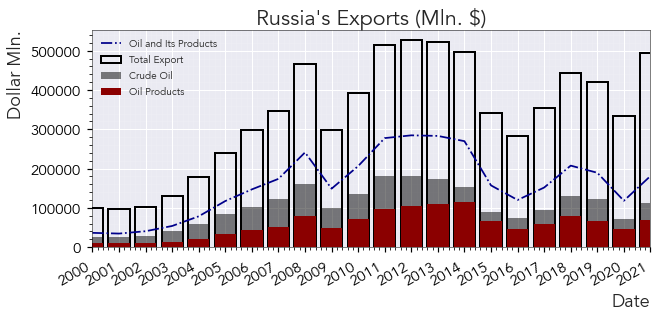

```python
# Vizualize dataset
mpl.style.use('seaborn')
mpl.rcParams['font.family'] = 'Avenir'
plt.rcParams['font.size'] = 18
mpl.rcParams['axes.linewidth'] = 0.5
mpl.rc('axes',edgecolor='black')

#data_oil_p
# plot total export
fig, ax = plt.subplots(figsize = (10, 4))

ax.bar(df_Yexp['T. Exp.'].index, df_Yexp['T. Exp.'], fill = None, edgecolor = 'black', label = 'Total Export', linewidth = 2)

ax.bar(df_Yexp['Crude Oil'].index, df_Yexp['Crude Oil'], color = 'black', label = 'Crude Oil', alpha = 0.5)
ax.bar(df_Yexp['Oil Prod.'].index, df_Yexp['Oil Prod.'], color = 'darkred', label = 'Oil Products')
ax.plot(df_Yexp['Oil and Prod.'].index, df_Yexp['Oil and Prod.'], color = 'darkblue', label = 'Oil and Its Products', linestyle = '-.')


# Organize ticks
# format axis
ax.set_title('Russia\'s Exports (Mln. $)', fontsize = 'large')
ax.set_xlabel('Date', loc = 'right', fontsize = 'medium')

ax.grid(True, which = 'minor', color = 'white', alpha = 0.1)
ax.set_xlim(df_Yexp['Oil and Prod.'].index[0], df_Yexp['Oil and Prod.'].index[-1])
ax.xaxis.set_minor_locator(mpl.ticker.AutoMinorLocator())
ax.yaxis.set_minor_locator(mpl.ticker.AutoMinorLocator())



#for label in ax[0].get_xticklabels(which='major'):
  #  label.set(rotation=30, horizontalalignment='right')


ax.tick_params(which = 'major', colors = 'black', length = 5, width = 1.2,
               labelsize = 'medium')
ax.tick_params(which = 'minor', length = 3, colors = 'black', width = 0.8)



# format axis
ax.set_ylabel('Dollar Mln.', loc = 'top', fontsize = 'medium')
ax.set_xlabel('Date', loc = 'right', fontsize = 'medium')


ax.grid(True, which = 'minor', color = 'white', alpha = 0.1)

ax.xaxis.set_minor_locator(mpl.ticker.AutoMinorLocator())
ax.yaxis.set_minor_locator(mpl.ticker.AutoMinorLocator())



for label in ax.get_xticklabels(which='major'):
    label.set(rotation=30, horizontalalignment='right')

ax.tick_params(which = 'major', colors = 'black', length = 5, width = 1.2,
               labelsize = 'small')
ax.tick_params(which = 'minor', length = 3, colors = 'black', width = 0.8)

plt.legend()

#fig.savefig(save_graph + '01_N_RussGDP_OilPrice.png', bbox_inches = 'tight')
path_savefig = '/Users/ferreira/Documents/01_Studies/01_University/01_Master/S.S.2022/07_SS.2022_Time_Series/04_Project/04_Presentation_1/00_Graphs/'
#plt.savefig(path_savefig + '00_Rus_Export.png', bbox_inches = 'tight')
```

### **0.2. Import Data Set in PandasDataFrame**

```python
# Theses are the data sets used in the Analysis
```

```python
import_path = '02_Processed_Data/'
data_agg_path = '02_Processed_Data/01_Dataset.xlsm'
save_graph = '03_Graphics/'
path_export = '02_Processed_Data/'
path_sd = '02_Processed_Data/SD.csv'
path_bootstrapp = '02_Processed_Data/00_Bootstrapps/'

data_sd = pd.read_csv(path_sd) # Dataset with rnsonal Dummies
data_sd.drop(data_sd.columns[0], inplace = True, axis = 1)
data_agg = pd.read_excel(data_agg_path, parse_dates = ['date'], index_col = 'date')
one_bln = 1000000000


data_sd = pd.read_csv(path_sd) # Dataset with Seasonal Dummies
data_sd.drop(data_sd.columns[0], inplace = True, axis = 1)
data_agg = pd.read_excel(data_agg_path, parse_dates = ['date'], index_col = 'date')
one_bln = 1000000000

##### 3. Create dataframe with only the data that will be used in the analysis
data = np.log(data_agg[['rgdp_2017', 'oil_price_2017']])

#### 4. Rename columns to lnRGDP, lnOIL

data.rename(columns = {'rgdp_2017': 'lnRGDP', 'oil_price_2017': 'lnOIL'}, inplace = True)
#date  = pd.PeriodIndex(data.index, freq = 'Q')
dates = data.index
```

## **Ch 1. | Data Visualization**

### **1.1. Nominal GDP & Oil Price at Current Values**

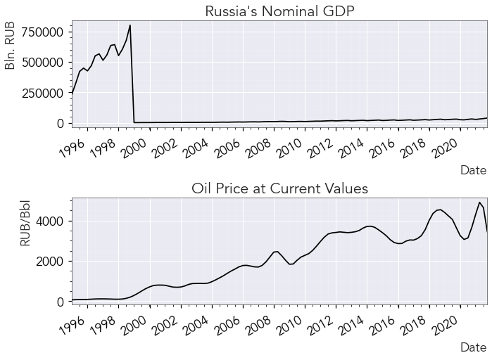

```python
mpl.style.use('seaborn')
mpl.rcParams['font.family'] = 'Avenir'
plt.rcParams['font.size'] = 18
mpl.rcParams['axes.linewidth'] = 0.5
mpl.rc('axes',edgecolor='black')
data_ngdp = data_agg[data_agg.columns[0]] / one_bln
data_oil_price = data_agg['cv_oil_price']
fig, ax = plt.subplots(figsize = (6.4 * 1.5, 7), nrows = 2, constrained_layout = True)

ax[0].plot(data_ngdp, color = 'black')


# format axis
ax[0].set_ylabel('Bln. RUB', loc = 'top', fontsize = 'medium')
ax[0].set_xlabel('Date', loc = 'right', fontsize = 'medium')
ax[0].set_title('Russia\'s Nominal GDP', fontsize = 'large', fontweight = 'bold')
ax[0].xaxis.set_major_locator(mdates.YearLocator(base = 2, month = 1, day = 1))
ax[0].xaxis.set_major_formatter(
    mdates.ConciseDateFormatter(ax[0].xaxis.get_major_locator()))
ax[0].grid(True, which = 'minor', color = 'white', alpha = 0.1)
ax[0].set_xlim(data_ngdp.index[0], data_ngdp.index[-1])
ax[0].xaxis.set_minor_locator(mpl.ticker.AutoMinorLocator())
ax[0].yaxis.set_minor_locator(mpl.ticker.AutoMinorLocator())



for label in ax[0].get_xticklabels(which='major'):
    label.set(rotation=30, horizontalalignment='right')

ax[0].tick_params(which = 'major', colors = 'black', length = 5, width = 1.2,
               labelsize = 'medium')
ax[0].tick_params(which = 'minor', length = 3, colors = 'black', width = 0.8)

ax[1].plot(data_oil_price, color = 'black')


# format axis
ax[1].set_ylabel('RUB/Bbl', loc = 'top', fontsize = 'medium')
ax[1].set_xlabel('Date', loc = 'right', fontsize = 'medium')
ax[1].set_title('Oil Price at Current Values', fontsize = 'large', fontweight = 'bold')
ax[1].xaxis.set_major_locator(mdates.YearLocator(base = 2, month = 1, day = 1))
ax[1].xaxis.set_major_formatter(
    mdates.ConciseDateFormatter(ax[1].xaxis.get_major_locator()))
ax[1].grid(True, which = 'minor', color = 'white', alpha = 0.1)
ax[1].set_xlim(data_oil_price.index[0], data_oil_price.index[-1])
ax[1].xaxis.set_minor_locator(mpl.ticker.AutoMinorLocator())
ax[1].yaxis.set_minor_locator(mpl.ticker.AutoMinorLocator())



for label in ax[1].get_xticklabels(which='major'):
    label.set(rotation=30, horizontalalignment='right')

ax[1].tick_params(which = 'major', colors = 'black', length = 5, width = 1.2,
               labelsize = 'medium')
ax[1].tick_params(which = 'minor', length = 3, colors = 'black', width = 0.8)



#fig.savefig(save_graph + '01_N_RussGDP_OilPrice.png', bbox_inches = 'tight')
```

### **1.2. Data Visualization: Real Data**

#### **1.2.1. Log(Real GDP)**

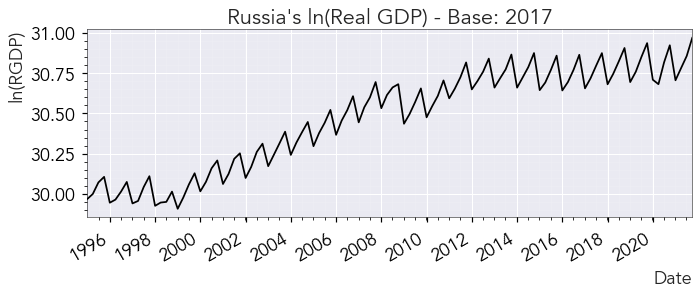

```python
fig, ax = plt.subplots(figsize = (6.4 * 1.5, 4), constrained_layout = True)
data_rgdp = data['lnRGDP']


ax.plot(data_rgdp, color = 'black')
# format axis
ax.set_ylabel('ln(RGDP)', loc = 'top', fontsize = 'medium')
ax.set_xlabel('Date', loc = 'right', fontsize = 'medium')
ax.set_title('Russia\'s ln(Real GDP) - Base: 2017', fontsize = 'large', fontweight = 'bold')
ax.xaxis.set_major_locator(mdates.YearLocator(base = 2, month = 1, day = 1))
ax.xaxis.set_major_formatter(
    mdates.ConciseDateFormatter(ax.xaxis.get_major_locator()))
ax.grid(True, which = 'minor', color = 'white', alpha = 0.1)
ax.set_xlim(data_rgdp.index[0], data_rgdp.index[-1])
ax.xaxis.set_minor_locator(mpl.ticker.AutoMinorLocator())
ax.yaxis.set_minor_locator(mpl.ticker.AutoMinorLocator())



for label in ax.get_xticklabels(which='major'):
    label.set(rotation=30, horizontalalignment='right')

ax.tick_params(which = 'major', colors = 'black', length = 5, width = 1.2,
               labelsize = 'medium')
ax.tick_params(which = 'minor', length = 3, colors = 'black', width = 0.8)

#fig.savefig(save_graph + '02_RussLnRGDP.png', bbox_inches = 'tight')
```

#### **1.2.2. Log(Oil Price)**

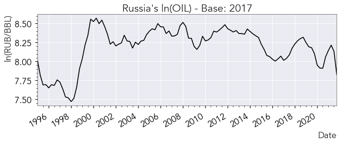

```python
fig, ax = plt.subplots(figsize = (6.4 * 1.5, 4), constrained_layout = True)
data_oil = data['lnOIL']


ax.plot(data_oil, color = 'black')
# format axis
ax.set_ylabel('ln(RUB/BBL)', loc = 'top', fontsize = 'medium')
ax.set_xlabel('Date', loc = 'right', fontsize = 'medium', font = 'Avenir')
ax.set_title('Russia\'s ln(OIL) - Base: 2017', fontsize = 'large', fontweight = 'bold')
ax.xaxis.set_major_locator(mdates.YearLocator(base = 2, month = 1, day = 1))
ax.xaxis.set_major_formatter(
    mdates.ConciseDateFormatter(ax.xaxis.get_major_locator()))
ax.grid(True, which = 'minor', color = 'white', alpha = 0.1)
ax.set_xlim(data_ngdp.index[0], data_ngdp.index[-1])
ax.xaxis.set_minor_locator(mpl.ticker.AutoMinorLocator())
ax.yaxis.set_minor_locator(mpl.ticker.AutoMinorLocator())



for label in ax.get_xticklabels(which='major'):
    label.set(rotation=30, horizontalalignment='right')

ax.tick_params(which = 'major', colors = 'black', length = 5, width = 1.2,
               labelsize = 'medium')
ax.tick_params(which = 'minor', length = 3, colors = 'black', width = 0.8)
#fig.savefig(save_graph + '03_LnOIL.png', bbox_inches = 'tight')
```

## **Ch 2. | Stationarity and Cointegration**

### **2.1 Test for Stationarity and Determination of the Integration Order**

#### **2.1.1. Augmented Dickey-Fuller Test**

The aim of the Augmented Dickey Fuller test is to proof the stationarity of the series.

The underlying model is given by:

$$ \Delta y_{t}=\beta_{0}+\gamma_{0}\delta_{1}t+\gamma_{1}y_{t-1}+\varepsilon_{t} $$

where $\gamma_{0}=\left[1-\alpha\right]$ and $\gamma_{1}=\left[\alpha-1\right]$. If the series has no trend, $\delta_{1}$ is set to zero. If the model has no intercept, $\beta_{0}$ is set to zero. The Augmented version of the test allows for multiple lagged values in the model.

```python
for name, columns in data.iteritems():
    fc.adfuller_test(series = columns, name = name, regression = 'c', autolag = 'BIC')
```

```
    Augmented Dickey-Fuller Test on "lnRGDP"
    -----------------------------------------------
 Null Hypothesis: Data has unit root. Non-Stationary.
 Significance Level    = 0.05
 Test Statistic        = -1.5086
 No. Lags Chosen       = 9
 Critical value 1%     = -3.499
 Critical value 5%     = -2.892
 Critical value 10%    = -2.583
 => P-Value = 0.5292. Weak evidence to reject the Null Hypothesis.
 => Series is Non-Stationary.



    Augmented Dickey-Fuller Test on "lnOIL"
    -----------------------------------------------
 Null Hypothesis: Data has unit root. Non-Stationary.
 Significance Level    = 0.05
 Test Statistic        = -2.0302
 No. Lags Chosen       = 9
 Critical value 1%     = -3.499
 Critical value 5%     = -2.892
 Critical value 10%    = -2.583
 => P-Value = 0.2735. Weak evidence to reject the Null Hypothesis.
 => Series is Non-Stationary.
```

##### **----------------------------------- [2.1.1.] Interpretation of the results: -----------------------------------**

$H_0$: Series is non-stationary:

- lnRGDP: Test statistic |1.5086| < |2.892| -> fail to reject $H_0$;
  - lnRGDP is non-stationary.
- lnOIL: Test statistic |2.0302| < |2.892| -> fail to reject $H_0$;
  - lnOIL is non-stationary.

#### **2.1.2. KPSS Test**

The KPSS test breaks the series into three components:

$$y_{t}=r_{t}+\beta t+\varepsilon_{t}$$

1. A deterministic trend: $\beta t$;
2. A random walk $r_{t}=\mu+\alpha x_{t}$;
3. A white noise $\varepsilon_{t}$.

If the data is stationary, it will be stationary around a fixed intercept $\mu$. The $H_{0}$ states that the series is stationary, say that $\alpha$ and $\beta$ are zero.

```python
for name, columns in data.iteritems():
    fc.kpss_test(series = columns, name = name, regression = 'c', nlags = 9)
```

```
    KPSS test on "lnRGDP"
    -----------------------------------------------
 Null Hypothesis: Data has no unit root. Stationary.
 Significance Level    = 0.05
 Test Statistic        = 1.1231
 No. Lags Chosen       = 9
 Critical value 10%    = 0.347
 Critical value 5%     = 0.463
 Critical value 2.5%   = 0.574
 Critical value 1%     = 0.739
 => P-Value = 0.01. Rejecting Null Hypothesis.
 => Series is not Stationary.



    KPSS test on "lnOIL"
    -----------------------------------------------
 Null Hypothesis: Data has no unit root. Stationary.
 Significance Level    = 0.05
 Test Statistic        = 0.272
 No. Lags Chosen       = 9
 Critical value 10%    = 0.347
 Critical value 5%     = 0.463
 Critical value 2.5%   = 0.574
 Critical value 1%     = 0.739
 => P-Value = 0.1. Weak evidence to reject the Null Hypothesis.
 => Series Stationary.
```

##### **----------------------------------- [2.1.2.] Interpretation of the results: -----------------------------------**

H0: Data is stationary.

##### **----------------------------------- Considerations 2.1 -----------------------------------**

- Both the ADF- and KPSS- Tests states no stationary for ln(RGDP) and only the KPSS-Test asserts that ln(OIL) is stationary;
- In order to avoind the problem of spurious regression, both data must be made stationary if there is no cointegrating relation between them.
- We will analyze now how many differencing do we need in order to make the data I(0), this will also tell us the order of their integration.

#### **2.1.3. Determination of the Integration Order**

##### **2.1.3.1 Visualization of the Data as Growth Rates (1. Differences)**

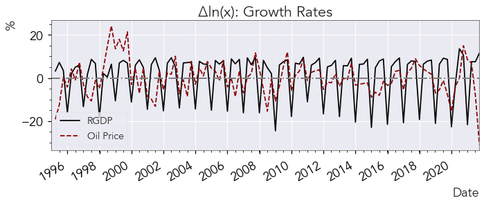

```python
ddata = data[['lnRGDP', 'lnOIL']].diff(1).dropna().copy()
ddata.rename(columns = {
    'lnRGDP': 'dRGDP',
    'lnOIL': 'dOIL'}, inplace = True)
colors = ['black', 'darkred']
labels = ['RGDP', 'Oil Price']

linestyle = ['solid', 'dashed']
fig, ax = plt.subplots(figsize = (6.4 * 1.5, 4), constrained_layout = True)

for i, columns in enumerate(ddata):

    ax.plot(ddata[columns] * 100, color = colors[i], label = labels[i], linestyle = linestyle[i])
ax.hlines(y = 0, xmin = ['1995'], xmax = ['2022'], color = 'grey', linestyle = '-.',
          linewidth = 2)

# format axis
ax.set_ylabel('%', loc = 'top', fontsize = 'medium')
ax.set_xlabel('Date', loc = 'right', fontsize = 'medium')
ax.set_title('Δln(x): Growth Rates', fontsize = 'large', fontweight = 'bold')
ax.xaxis.set_major_locator(mdates.YearLocator(base = 2, month = 1, day = 1))
ax.xaxis.set_major_formatter(
    mdates.ConciseDateFormatter(ax.xaxis.get_major_locator()))
ax.grid(True, which = 'minor', color = 'white', alpha = 0.1)
ax.set_xlim(data_ngdp.index[0], data_ngdp.index[-1])
ax.xaxis.set_minor_locator(mpl.ticker.AutoMinorLocator())
ax.yaxis.set_minor_locator(mpl.ticker.AutoMinorLocator())

ax.legend(fontsize = 14, frameon = True)

for label in ax.get_xticklabels(which='major'):
    label.set(rotation=30, horizontalalignment='right')

ax.tick_params(which = 'major', colors = 'black', length = 5, width = 1.2,
               labelsize = 'medium')
ax.tick_params(which = 'minor', length = 3, colors = 'black', width = 0.8)

#fig.savefig(save_graph + '04_GrowthRates.png', bbox_inches = 'tight')
```

**----------------------------------- Considerations 2.2 -----------------------------------**

- The graphic shows that the growth rates of both series swings around a constant mean (around 0). This indicates a stationarity of the data.
- Recall that stationarity recalls much more than a constament mean. Strict stationarity requires the distribution of the series to be the same along time. This is a very strict condition.
- For our purpose it is enough that the data is covariance stationary:
  - Has constant mean.
  - Has constat variance.
  - Covariance diminishes with time and is not dependent on t but on the distance between the observations h.

##### **2.1.3.2. ADF-Test on Growth Rates**

```python
for names, columns in ddata.iteritems():
    fc.adfuller_test(series = columns, name = names, regression = 'c', autolag = 'BIC')
```

```
    Augmented Dickey-Fuller Test on "dRGDP"
    -----------------------------------------------
 Null Hypothesis: Data has unit root. Non-Stationary.
 Significance Level    = 0.05
 Test Statistic        = -4.043
 No. Lags Chosen       = 4
 Critical value 1%     = -3.496
 Critical value 5%     = -2.89
 Critical value 10%    = -2.582
 => P-Value = 0.0012. Rejecting Null Hypothesis.
 => Series is Stationary.



    Augmented Dickey-Fuller Test on "dOIL"
    -----------------------------------------------
 Null Hypothesis: Data has unit root. Non-Stationary.
 Significance Level    = 0.05
 Test Statistic        = -5.2164
 No. Lags Chosen       = 4
 Critical value 1%     = -3.496
 Critical value 5%     = -2.89
 Critical value 10%    = -2.582
 => P-Value = 0.0. Rejecting Null Hypothesis.
 => Series is Stationary.
```

**----------------------------------- [2.1.3.2] Interpreation of the Results:**

$H_0$: Series is non-stationary:

**----------------------------------- Considerations 2.3:**

The ADF-Test on differences (growth rates) shows that, after differencing once both series, say lnRDP and lnOIL, become stationary. In other words, both series are integrated of order one I(1) and become I(0) stated as growth rates.

In the case of nonstationary series there are two options, either carry out the analysis with their differences, which are stationary, or to proof if there exists a long-term relationship between them, say a cointegration relation which avoids the series to drift away from each other. This is the same as to say that the series have a common stochastic trend.

### **2.2. Cointegration Test**

#### **2.2.1. Engel-Granger Cointegration Test**

##### **2.2.1.1. Theory**

Cointegration means that there is a linear combination of the series in the model such that, two variables which are separately $\mathbf{I}\left(1\right)$ become $\mathbf{I}\left(0\right)$. In such a case, the variables have a common stochastic trend that avoids the series from drifting away from each other; even if they eventually run in opposite directions, in the long-run, they tend to return to the general equilibrium.

The idea proposed by the Engle-Granger cointegration test is that, if such a relation relation exists, this relation should be reflected in the residuals, as these also are computed by a linear combination of the variables. In other words, if $\left\{ \ln\text{Oil}\right\}$ and $\left\{ \ln\text{RGDP}\right\}$ are cointegrated, the residual of a simple regression will be a $\mathbf{I}\left(0\right)$ stationary series.

##### **2.2.1.2. Ordinary Least Square $\ln \text{RGDP}_{t} ~ \ln \text{Oil}_{t}$**

The underlying model is:

$$ \ln\text{RGP}_{t}=\beta_{0}+\beta_{1}\ln\text{OIL}+\varepsilon_{t} $$

```python
regression = sm.ols(formula = 'lnRGDP ~ lnOIL', data = data)
results = regression.fit()

# Obtain residuals:
residuals = results.resid
residuals_2 = data['lnRGDP'] - results.fittedvalues
print(results.summary())
```

```
                            OLS Regression Results
==============================================================================
Dep. Variable:                 lnRGDP   R-squared:                       0.135
Model:                            OLS   Adj. R-squared:                  0.127
Method:                 Least Squares   F-statistic:                     16.52
Date:                Mon, 15 Aug 2022   Prob (F-statistic):           9.27e-05
Time:                        19:54:53   Log-Likelihood:                -19.243
No. Observations:                 108   AIC:                             42.49
Df Residuals:                     106   BIC:                             47.85
Df Model:                           1
Covariance Type:            nonrobust
==============================================================================
                 coef    std err          t      P>|t|      [0.025      0.975]
------------------------------------------------------------------------------
Intercept     26.9156      0.876     30.738      0.000      25.180      28.652
lnOIL          0.4342      0.107      4.064      0.000       0.222       0.646
==============================================================================
Omnibus:                       11.629   Durbin-Watson:                   0.131
Prob(Omnibus):                  0.003   Jarque-Bera (JB):                4.016
Skew:                          -0.079   Prob(JB):                        0.134
Kurtosis:                       2.069   Cond. No.                         259.
==============================================================================

Notes:
[1] Standard Errors assume that the covariance matrix of the errors is correctly specified.
```

**----------------------------------- [2.2.2.] Interpretation of the results:**

##### **2.2.1.3. Plot of the Residuals**

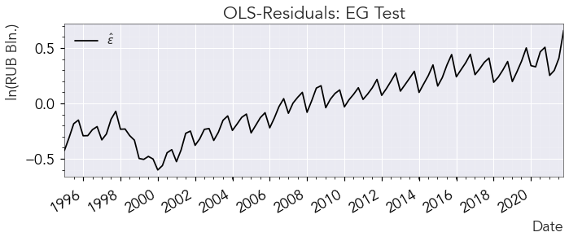

```python
fig, ax = plt.subplots(figsize = (6.4 * 1.5, 4), constrained_layout = True)

ax.plot(residuals, color = 'black', label = "$\hat{ε}$", linestyle = 'solid')

# format axis
ax.set_ylabel('ln(RUB Bln.)', loc = 'top', fontsize = 'medium')
ax.set_xlabel('Date', loc = 'right', fontsize = 'medium')
ax.set_title('OLS-Residuals: EG Test', fontsize = 'large', fontweight = 'bold')
ax.xaxis.set_major_locator(mdates.YearLocator(base = 2, month = 1, day = 1))
ax.xaxis.set_major_formatter(
    mdates.ConciseDateFormatter(ax.xaxis.get_major_locator()))
ax.grid(True, which = 'minor', color = 'white', alpha = 0.1)
ax.set_xlim(data_ngdp.index[0], data_ngdp.index[-1])
ax.xaxis.set_minor_locator(mpl.ticker.AutoMinorLocator())
ax.yaxis.set_minor_locator(mpl.ticker.AutoMinorLocator())

ax.legend(fontsize = 14)

for label in ax.get_xticklabels(which='major'):
    label.set(rotation=30, horizontalalignment='right')

ax.tick_params(which = 'major', colors = 'black', length = 5, width = 1.2,
               labelsize = 'medium')
ax.tick_params(which = 'minor', length = 3, colors = 'black', width = 0.8)
#fig.savefig(save_graph + '05_EG_Residuals.png', bbox_inches = 'tight')
```

##### **2.2.1.4. ADF-Test on Residuals**

```python
fc.adfuller_test(residuals, regression = 'n', name = 'Residuals', autolag = 'BIC')
```

```
    Augmented Dickey-Fuller Test on "Residuals"
    -----------------------------------------------
 Null Hypothesis: Data has unit root. Non-Stationary.
 Significance Level    = 0.05
 Test Statistic        = 0.0504
 No. Lags Chosen       = 8
 Critical value 1%     = -2.589
 Critical value 5%     = -1.944
 Critical value 10%    = -1.614
 => P-Value = 0.7008. Weak evidence to reject the Null Hypothesis.
 => Series is Non-Stationary.
```

**----------------------------------- [2.2.1.4] Interpretation of the results:**

$H_{0}$: There is no cointegration relation (residual is non-stationary)

- Test Statistic $|0.0504| < |-1.944|$
  - $H_{0}$ cannot be rejected.

Outcome: Risiduals are not stationary; accordingly there is no cointegrating relation between the variables and they should be used as growth rates (differenced).

**----------------------------------- Considerations 2.4:**

The ADF-Test shows that there residuals of the OLS are not stationary, meaning that there is no long-term equilibrium between the series lnRGDP and lnOIL. This becomes more evident when we look at the plot of the residuals, one note that after around 2000 the residuals increase steadly. Thus a cointegrating relation between the series lnRGDP and lnOil can be rejected.

### **2.3. Johansen-Cointegration Test**

#### **2.3.1. Selection of the Lag-Length for the Variables $\ln \text{RGDP}$ and $\ln \text{OIL}$ (VAR)**

```python
model = VAR(data)
order_select = model.select_order(20)
order = order_select.bic # Optimal lag-length is 5
print(f'Lag-length selected by information criteria: {order}')
```

```
Lag-length selected by information criteria: 5
```

##### **2.3.1.1. VECM Model**

```python
model = VECM(data, deterministic = 'co')
results_VECM = model.fit()
print(results_VECM.summary())
```

```
Det. terms outside the coint. relation & lagged endog. parameters for equation lnRGDP
==============================================================================
                 coef    std err          z      P>|z|      [0.025      0.975]
------------------------------------------------------------------------------
const         -0.1164      0.318     -0.367      0.714      -0.739       0.506
L1.lnRGDP     -0.1974      0.094     -2.107      0.035      -0.381      -0.014
L1.lnOIL      -0.4165      0.133     -3.138      0.002      -0.677      -0.156
Det. terms outside the coint. relation & lagged endog. parameters for equation lnOIL
==============================================================================
                 coef    std err          z      P>|z|      [0.025      0.975]
------------------------------------------------------------------------------
const          0.5511      0.226      2.434      0.015       0.107       0.995
L1.lnRGDP     -0.0844      0.067     -1.263      0.207      -0.215       0.047
L1.lnOIL       0.4857      0.095      5.132      0.000       0.300       0.671
               Loading coefficients (alpha) for equation lnRGDP
==============================================================================
                 coef    std err          z      P>|z|      [0.025      0.975]
------------------------------------------------------------------------------
ec1            0.0002      0.001      0.402      0.687      -0.001       0.001
               Loading coefficients (alpha) for equation lnOIL
==============================================================================
                 coef    std err          z      P>|z|      [0.025      0.975]
------------------------------------------------------------------------------
ec1           -0.0009      0.000     -2.434      0.015      -0.002      -0.000
          Cointegration relations for loading-coefficients-column 1
==============================================================================
                 coef    std err          z      P>|z|      [0.025      0.975]
------------------------------------------------------------------------------
beta.1         1.0000          0          0      0.000       1.000       1.000
beta.2        69.9732     23.722      2.950      0.003      23.478     116.468
==============================================================================
```

#### **2.3.2. Cointegration test (Johansen)**

Given that the optimal lag-length is 5, the VAR-Model can be stated as follows:

$$\mathbf{y}_{t}=\mathbf{c}+\mathbf{A}_{1}\mathbf{y}_{t-1}+\mathbf{A}_{2}\mathbf{y}_{t-2}+\mathbf{A}_{3}\mathbf{y}_{t-3}+\mathbf{A}_{4}\mathbf{y}_{t-4}+\mathbf{A}_{5}\mathbf{y}_{t-5}+\mathbf{e}_{t}$$

In its VECM version it becomes:

$$\Delta\mathbf{y}_{t}=\Pi\mathbf{y}_{t-1}+\Gamma_{1}\mathbf{y}_{t-1}+\Gamma_{2}\mathbf{y}_{t-2}+\Gamma_{3}\mathbf{y}_{t-3}+\Gamma_{4}\mathbf{y}_{t-4}+\mathbf{e}_{t}$$

How the series behaves depends on the matrix $\Pi$. If it has full rank, then one has a stationary series and the (VAR) model can be estimated using the series without any further transformation. If its rank is between 0 and k, beeing k the number of variables in the model, than there might be a cointegration ralation between the variables; if the rank is zero, one should estimate a VAR in differences.

```python
# The Cointegration test
from statsmodels.tsa.vector_ar.vecm import coint_johansen, select_coint_rank

maxeig_test = coint_johansen(data, det_order = 0, k_ar_diff = 4).max_eig_stat
maxeig_critical = coint_johansen(data, det_order = 0, k_ar_diff = 4).max_eig_stat_crit_vals
trace_test = coint_johansen(data, det_order = 0, k_ar_diff = 4).trace_stat
trace_critical = coint_johansen(data, det_order = 0, k_ar_diff = 4).trace_stat_crit_vals

index = ['H0: r = 0', 'H0: r = 1']
Johansentest = pd.DataFrame({
    'Trace Stat': [trace_test[0], trace_test[1]],
    'Trace Crit 0.05': [trace_critical[0, 1], trace_critical[1, 1]],
    'Max Eigen': [maxeig_test[0], maxeig_test[1]],
    'Max Crit 0.05:': [maxeig_critical[0, 1], maxeig_critical[1, 1]]
    }, index = index)
```

```python
Johansentest
```

|  | Trace Stat | Trace Crit 0.05 | Max Eigen | Max Crit 0.05: |
| --- | --- | --- | --- | --- |
| H0: r = 0 | 9.355043 | 15.4943 | 5.905249 | 14.2639 |
| H0: r = 1 | 3.449794 | 3.8415 | 3.449794 | 3.8415 |

```python
from Johansen import coint_johansen

coint_johansen(data, 0, 4)
```

```
--------------------------------------------------
--> Trace Statistics
variable statistic Crit-90% Crit-95%  Crit-99%
r = 0 	 9.355 13.4294 15.4943 19.9349
r = 1 	 3.4498 2.7055 3.8415 6.6349
--------------------------------------------------
--> Eigen Statistics
variable statistic Crit-90% Crit-95%  Crit-99%
r = 0 	 5.9052 12.2971 14.2639 18.52
r = 1 	 3.4498 2.7055 3.8415 6.6349
--------------------------------------------------
eigenvectors:
 [[ 0.13714816 -4.01526861]
 [-5.2018226   2.68946337]]
--------------------------------------------------
eigenvalues:
 [0.05571997 0.03293846]
--------------------------------------------------
```

```
<Johansen.Holder at 0x17d4bfca0>
```

```python
help(select_coint_rank)
```

[output not shown]

```python
print(f'The selected order is: {order}\n')
print(f'\n\nJohansen\'s cointegration test')
print({fc.cointegration_test(data, order - 1, det_order = 0, alpha = 0.05)})
print(f'\nCointegration Rank: {select_coint_rank(endog = data, det_order = 0, k_ar_diff = order - 1, signif = 0.05, method = "maxeig")}')
print(f'The rank is: {select_coint_rank(endog = data, det_order = -1, k_ar_diff = order - 1, method = "maxeig").rank}')
```

```
The selected order is: 5



Johansen's cointegration test
Name   ::  Test Stat > C(95%)    =>   Signif
 ----------------------------------------
lnRGDP ::  9.36      > 15.4943   =>   False
lnOIL  ::  3.45      > 3.8415    =>   False
{None}

Cointegration Rank: Johansen cointegration test using maximum eigenvalue test statistic with 5% significance level
=====================================
r_0 r_1 test statistic critical value
-------------------------------------
  0   1          5.905          14.26
-------------------------------------
The rank is: 0
```

**----------------------------------- Considerations 2.5:**

As no cointegration relation could be found neither the johansen nor the Engel-Granger cointegration test, the analysis will be based on the the growth rates of the varaibles which are stationary.

## **Ch 3. | Vector Autoregressive Model Estimation (VAR)**

The first step in estimating a vector autoregressive model is to decide on the lag-length of the model. There are mainly four methods that could help the author in this task:

1. - Information criteria;
2. - Maximum Likelihood Ratio Test;
3. - (Partial) Autocorrelation function - Graphical Analysis;
4. - Theory.

### **3.1. Determination of the Lag-Length**

#### **3.1.1. Determination of the Lag-Length Without Seasonal Dummies**

##### **3.1.1.1. Information Criteria**

```python
# [1] Information Criteria (No seasonal dummies)
model_nd = VAR(ddata)
order_info = model_nd.select_order(20)
print(f'Information Criteria: {order_info.summary()}')
optimal_lag = ['AIC: ' + str(order_info.aic), 'BIC: ' + str(order_info.bic), 'HQ: ' + str(order_info.hqic), 'FPE: ' + str(order_info.fpe)]
print(f'\nOptimal lag-length according to information criteria: {optimal_lag}')
```

```
Information Criteria:  VAR Order Selection (* highlights the minimums)
==================================================
       AIC         BIC         FPE         HQIC
--------------------------------------------------
0       -9.733      -9.676   5.931e-05      -9.710
1       -10.01      -9.837   4.509e-05      -9.939
2       -10.38      -10.10   3.104e-05      -10.27
3       -12.12      -11.72   5.470e-06      -11.96
4       -13.02     -12.51*   2.209e-06     -12.82*
5       -13.00      -12.37   2.278e-06      -12.74
6       -13.03      -12.29   2.201e-06      -12.73
7       -13.04      -12.19   2.194e-06      -12.69
8       -12.97      -12.00   2.359e-06      -12.58
9      -13.08*      -12.00  2.127e-06*      -12.64
10      -13.00      -11.81   2.298e-06      -12.52
11      -12.97      -11.67   2.385e-06      -12.45
12      -12.97      -11.56   2.398e-06      -12.40
13      -13.08      -11.54   2.188e-06      -12.46
14      -12.99      -11.35   2.402e-06      -12.33
15      -12.97      -11.22   2.479e-06      -12.27
16      -12.99      -11.12   2.472e-06      -12.24
17      -12.95      -10.97   2.617e-06      -12.15
18      -12.91      -10.81   2.778e-06      -12.06
19      -12.85      -10.64   3.023e-06      -11.96
20      -12.80      -10.47   3.253e-06      -11.86
--------------------------------------------------

Optimal lag-length according to information criteria: ['AIC: 9', 'BIC: 4', 'HQ: 4', 'FPE: 9']
```

##### **3.1.1.2. Maximum Likelihood Ratio Test**

```python
# [2] Maximum Likelihoood Ratio Test
print(f'\n Likelihood Ratio Test:')
order_LR = fc.lag_lengthLR(model_nd, trend = 'c', maxlength = 10);
```

```
 Likelihood Ratio Test:

H0: Including the i-th lag does not improve the model.
----------------------------------------------------------------------------------------------------
     likelihoodfunc  LR - Statistic    pvalue reject H0
lag
10       384.082090        1.786569  0.774939       yes
9        386.069682       -3.975184  1.000000       yes
8        382.644439        6.850486  0.144003       yes
7        381.709300        1.870279  0.759602       yes
6        384.201429       -4.984258  1.000000       yes
5        382.294099        3.814660  0.431670       yes
4        383.471829       -2.355461  1.000000        no
3        339.814383       87.314893  0.000000        no
2        257.853450      163.921866  0.000000        no
----------------------------------------------------------------------------------------------------
```

##### **3.1.1.2. Graphical Inspection**

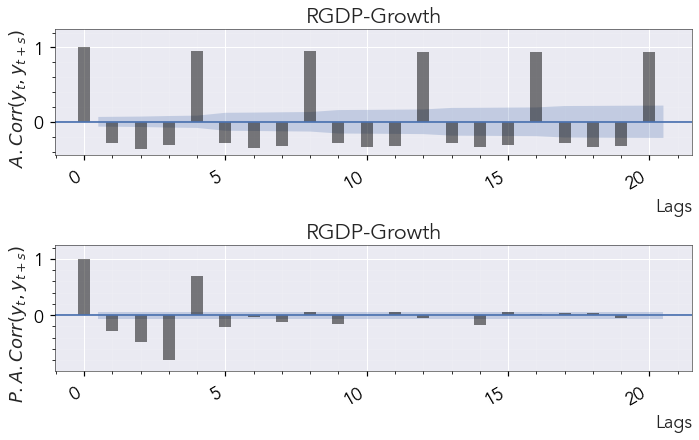

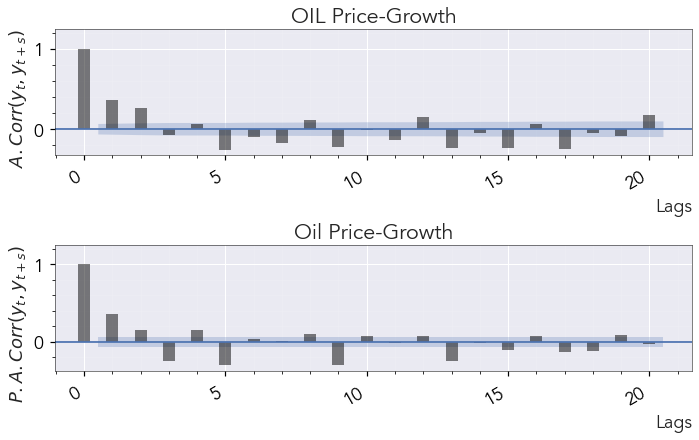

```python
# [3.1.] Plots of the auto- and partial correlation functions for dRGDP
fig, axes = plt.subplots(nrows = 2, ncols = 1, figsize = (6.4 * 1.5, 6), constrained_layout = True)

v_lines = {'color': 'black', 'linestyle': '-', 'linewidth': 12, 'alpha': 0.5}
plot_acf(ddata['dRGDP'], ax = axes[0], lags = 20, alpha = 0.5, use_vlines = True, adjusted = True, title = 'Autocorrelation: RGDP-Growth', auto_ylims = True, vlines_kwargs = v_lines
        , marker = None, markerfacecolor = 'black');

plot_pacf(ddata['dRGDP'], ax = axes[1], lags = 20, alpha = 0.5, use_vlines = True, title = 'Partial Autocorrelation: RGDP-Growth', auto_ylims = True, vlines_kwargs = v_lines
        , marker = None, markerfacecolor = 'black', method = 'ywm');

title = ['RGDP-Growth', 'RGDP-Growth']

y_label = ['$A. Corr(y_t, y_{t+s})$', '$P. A. Corr(y_t, y_{t+s})$']
# format axis
for i, ax in enumerate(axes.flatten()):
    ax.set_ylabel(y_label[i], loc = 'top', fontsize = 'medium')
    ax.set_xlabel('Lags', loc = 'right', fontsize = 'medium')
    ax.set_title(title[i], fontsize = 'large', fontweight = 'bold')
    ax.grid(True, which = 'minor', color = 'white', alpha = 0.1)
    ax.xaxis.set_minor_locator(mpl.ticker.AutoMinorLocator())
    ax.yaxis.set_minor_locator(mpl.ticker.AutoMinorLocator())


    for label in ax.get_xticklabels(which='major'):
        label.set(rotation=30, horizontalalignment='right')

    ax.tick_params(which = 'major', colors = 'black', length = 5, width = 1.2,
               labelsize = 'medium')
    ax.tick_params(which = 'minor', length = 3, colors = 'black', width = 0.8)
#fig.savefig(save_graph + '06.1_LagLength_Graph_Inspection.png', bbox_tight = True)
# [3.2.] Plots of the auto- and partial correlation functions for dOIL
fig, axes = plt.subplots(nrows = 2, ncols = 1, figsize = (6.4 * 1.5, 6), constrained_layout = True)
title = ['OIL Price-Growth', 'Oil Price-Growth']
plot_acf(ddata['dOIL'], ax = axes[0], lags = 20, alpha = 0.5, use_vlines = True, adjusted = True, title = 'Autocorrelation: RGDP-Growth', auto_ylims = True, vlines_kwargs = v_lines
        , marker = None, markerfacecolor = 'black');

plot_pacf(ddata['dOIL'], ax = axes[1], lags = 20, alpha = 0.5, use_vlines = True, title = 'Partial Autocorrelation: RGDP-Growth', auto_ylims = True, vlines_kwargs = v_lines
        , marker = None, markerfacecolor = 'black', method = 'ywm');

for i, ax in enumerate(axes.flatten()):
    ax.set_ylabel(y_label[i], loc = 'top', fontsize = 'medium')
    ax.set_xlabel('Lags', loc = 'right', fontsize = 'medium')
    ax.set_title(title[i], fontsize = 'large', fontweight = 'bold')
    ax.grid(True, which = 'minor', color = 'white', alpha = 0.1)
    ax.xaxis.set_minor_locator(mpl.ticker.AutoMinorLocator())
    ax.yaxis.set_minor_locator(mpl.ticker.AutoMinorLocator())


    for label in ax.get_xticklabels(which='major'):
        label.set(rotation=30, horizontalalignment='right')

    ax.tick_params(which = 'major', colors = 'black', length = 5, width = 1.2,
               labelsize = 'medium')
    ax.tick_params(which = 'minor', length = 3, colors = 'black', width = 0.8)

#fig.savefig(save_graph + '06.2_LagLength_Graph_Inspection.png', bbox_tight = True)
```

```python
# [1] Information criteria (with seasonal dummies)
data_sd.index = ddata.index
model_sd = VAR(ddata, exog = data_sd)
order = model_sd.select_order(20)
print(order.summary())
```

```
 VAR Order Selection (* highlights the minimums)
==================================================
       AIC         BIC         FPE         HQIC
--------------------------------------------------
0       -12.61      -12.33   3.326e-06      -12.50
1       -12.98      -12.58   2.311e-06      -12.82
2       -13.05      -12.54   2.150e-06      -12.85
3       -13.11      -12.49   2.023e-06      -12.86
4      -13.35*     -12.62*  1.594e-06*     -13.06*
5       -13.30      -12.45   1.690e-06      -12.96
6       -13.29      -12.33   1.707e-06      -12.90
7       -13.21      -12.13   1.859e-06      -12.78
8       -13.18      -11.99   1.928e-06      -12.70
9       -13.21      -11.90   1.889e-06      -12.68
10      -13.17      -11.75   1.973e-06      -12.60
11      -13.18      -11.65   1.960e-06      -12.57
12      -13.17      -11.52   2.014e-06      -12.51
13      -13.22      -11.47   1.927e-06      -12.52
14      -13.18      -11.31   2.051e-06      -12.42
15      -13.21      -11.22   2.024e-06      -12.41
16      -13.16      -11.06   2.163e-06      -12.31
17      -13.13      -10.92   2.265e-06      -12.24
18      -13.18      -10.86   2.218e-06      -12.24
19      -13.13      -10.69   2.410e-06      -12.14
20      -13.07      -10.52   2.617e-06      -12.05
--------------------------------------------------
```

**----------------------------------- Considerations 3.1:**

The optimal lag-length according to

```
• Information criteria:

    – AIC: 9;

    – BIC: 4;

    – HQ: 4;

    – FPE: 9.

• LR: 4

• Graphical Inspection - P. autocorrelation: 5;
```

#### **3.1.2. Determination of the Lag-Length With Seasonal Dummies**

##### **3.1.2.1. Information Criteria**

```python
model_sd = VAR(ddata, exog = data_sd)
order_info_sd = model_sd.select_order(20)
print(f'Information Criteria: {order_info_sd.summary()}')
optimal_lag = ['AIC: ' + str(order_info_sd.aic), 'BIC: ' + str(order_info_sd.bic), 'HQ: ' + str(order_info_sd.hqic), 'FPE: ' + str(order_info_sd.fpe)]
print(f'\nOptimal lag-length according to information criteria: {optimal_lag}')
```

```
Information Criteria:  VAR Order Selection (* highlights the minimums)
==================================================
       AIC         BIC         FPE         HQIC
--------------------------------------------------
0       -12.61      -12.33   3.326e-06      -12.50
1       -12.98      -12.58   2.311e-06      -12.82
2       -13.05      -12.54   2.150e-06      -12.85
3       -13.11      -12.49   2.023e-06      -12.86
4      -13.35*     -12.62*  1.594e-06*     -13.06*
5       -13.30      -12.45   1.690e-06      -12.96
6       -13.29      -12.33   1.707e-06      -12.90
7       -13.21      -12.13   1.859e-06      -12.78
8       -13.18      -11.99   1.928e-06      -12.70
9       -13.21      -11.90   1.889e-06      -12.68
10      -13.17      -11.75   1.973e-06      -12.60
11      -13.18      -11.65   1.960e-06      -12.57
12      -13.17      -11.52   2.014e-06      -12.51
13      -13.22      -11.47   1.927e-06      -12.52
14      -13.18      -11.31   2.051e-06      -12.42
15      -13.21      -11.22   2.024e-06      -12.41
16      -13.16      -11.06   2.163e-06      -12.31
17      -13.13      -10.92   2.265e-06      -12.24
18      -13.18      -10.86   2.218e-06      -12.24
19      -13.13      -10.69   2.410e-06      -12.14
20      -13.07      -10.52   2.617e-06      -12.05
--------------------------------------------------

Optimal lag-length according to information criteria: ['AIC: 4', 'BIC: 4', 'HQ: 4', 'FPE: 4']
```

##### **3.1.2.2. Likelihood Ratio Test:**

```python
# [2] Maximum Likelihoood Ratio Test
print(f'\n Likelihood Ratio Test:')
order_LR = fc.lag_lengthLR(model_sd, trend = 'n', maxlength = 10);
```

```
 Likelihood Ratio Test:

H0: Including the i-th lag does not improve the model.
----------------------------------------------------------------------------------------------------
     likelihoodfunc  LR - Statistic    pvalue reject H0
lag
10       403.196466        0.798113  0.938701       yes
9        401.906222        2.580489  0.630283       yes
8        400.840013        2.132417  0.711419       yes
7        401.556989       -1.433952  1.000000       yes
6        406.254539       -9.395100  1.000000       yes
5        405.697597        1.113885  0.892063       yes
4        407.852369       -4.309546  1.000000        no
3        398.016070       19.672598  0.000579       yes
2        396.388005        3.256129  0.515913       yes
----------------------------------------------------------------------------------------------------
```

##### **3.1.2.3. Graphical Inspection**

The autocorrelation function is the same as the one stated in section **3.1.1.3.**

**----------------------------------- Considerations 3.2:**

The optimal lag-length according to

[output not shown]

If one uses the average as the optimal length, one obtains an average of appr. 4 lags.

### **3.2. LR-Test: Decision About Including Seasonal Dummies**

In order to decide whether to include a seasonal dummy or not, following model is calculated:

$$\mathbf{y}_{t}=\mathbf{c}+\delta_{2}\mathbf{s}_{2}+\delta_{3}\mathbf{s}_{3}+\delta_{4}\mathbf{s}_{4}+\beta_{1}\mathbf{y}_{t-1}+\beta_{2}\mathbf{y}_{t-2}+\dots+\beta_{p}\mathbf{y}_{t-p} + \mathbf{e}_{t}$$

The model will be calculated twice once with $p=5$, because this is the optimal lag-length given that no dummies is included; once with $p=4$, as this is the optimal length given that dummies are included.

$$\mathscr{LR}_{\ln}=-2\left[\mathscr{L}_{\ln\left(r\right)}-\mathscr{L}_{\ln\left(u\right)}\right]$$

```python
# p = 5
# Restricted model
model_nd = VAR(ddata)
VAR_fit_nd = model_nd.fit(maxlags = 5, trend = 'c')
llf_r = VAR_fit_nd.llf

# Unrestricted model
sd_LR = data_sd.iloc[:, 1:]
model_sd = VAR(ddata, exog = sd_LR)
VAR_fit_sd = model_sd.fit(maxlags = 5, trend = 'n')
llf_ur = VAR_fit_sd.llf

# LR-Test
LR = -2 * (llf_r - llf_ur)

p_val = 1 - stats.chi2.cdf(LR, 5)
print('Likelihood Ratio Test. Number of lags added: 5')
print(f'Likelihood Ratio Test. Pvalue: {p_val}')


if p_val < 0.05:
    print('reject H0')
else:
    print('fail to reject H0')
```

```
Likelihood Ratio Test. Number of lags added: 5
Likelihood Ratio Test. Pvalue: 0.05959063838486034
fail to reject H0
```

```python
# p = 5
# Restricted model
model_sd = VAR(ddata)
VAR_fit_nd = model_nd.fit(maxlags = 4, trend = 'c')
llf_r = VAR_fit_nd.llf

# Unrestricted model
sd_LR = data_sd.iloc[:, 1:]
model_sd = VAR(ddata, exog = sd_LR)
VAR_fit_sd = model_sd.fit(maxlags = 4, trend = 'n')
llf_ur = VAR_fit_sd.llf

# LR-Test
LR = -2 * (llf_r - llf_ur)

p_val = 1 - stats.chi2.cdf(LR, 6)
print('Likelihood Ratio Test. Number of lags added: 4')
print(f'Likelihood Ratio Test. Pvalue: {p_val}')

if p_val < 0.05:
    print('reject H0')
else:
    print('fail to reject H0')
```

```
Likelihood Ratio Test. Number of lags added: 4
Likelihood Ratio Test. Pvalue: 0.1104635068477654
fail to reject H0
```

**----------------------------------- Considerations 3.3:**

The LR-Test indicates no significant improvement in the model when one includes a seasonal dummy. We conclude that the VAR-Model should be estimated in differences, without seasonal variables. Although the average the components analyzed would indicate an optimality of 5-lags, the HQ and BIC Information criteria are very close to it and are asymptotically correct, if we specified a lag-length in the test which is long enough.

Catch up:

```
- The model will be estimated as:
```

$$\mathbf{y}_{t}=\mathbf{c}+\mathbf{A}_{1}\mathbf{y}_{t-1}+\mathbf{A}_{2}\mathbf{y}_{t-2}+\mathbf{A}_{3}\mathbf{y}_{t-3}+\mathbf{A}_{4}\mathbf{y}_{t-4}+\mathbf{e}_{t}$$

### **3.3. VAR Estimation**

#### **3.3.1. Model Estimation**

**Nota Bene: Make Sure that the first Equation in the VAR system ist dOIL and NOT! dRGDP. If the code below is run an odd number of times, the order of the equations will have dOIL as the first equation, if its run an even number of time, dRGDP will be the first equation!**

```python
# model
data = data[['lnRGDP', 'lnOIL']].diff(1).dropna().copy()
columns = ddata.columns.tolist()
columns = columns[-1:] + columns[:-1]
ddata = ddata[columns]
model = VAR(ddata)
results = model.fit(4, trend = 'c', method = 'ols')
print(results.summary())
print(f'covariance-matrix:\n{results.sigma_u}')
len(ddata)
```

```
  Summary of Regression Results
==================================
Model:                         VAR
Method:                        OLS
Date:           Mon, 15, Aug, 2022
Time:                     20:06:18
--------------------------------------------------------------------
No. of Equations:         2.00000    BIC:                   -12.3119
Nobs:                     103.000    HQIC:                  -12.5858
Log likelihood:           383.472    FPE:                2.84087e-06
AIC:                     -12.7723    Det(Omega_mle):     2.40264e-06
--------------------------------------------------------------------
Results for equation dOIL
===========================================================================
              coefficient       std. error           t-stat            prob
---------------------------------------------------------------------------
const            0.001378         0.007235            0.190           0.849
L1.dOIL          0.719453         0.121599            5.917           0.000
L1.dRGDP        -0.149428         0.150012           -0.996           0.319
L2.dOIL          0.224271         0.130936            1.713           0.087
L2.dRGDP        -0.193596         0.145493           -1.331           0.183
L3.dOIL         -0.443761         0.138729           -3.199           0.001
L3.dRGDP        -0.241825         0.146559           -1.650           0.099
L4.dOIL          0.061666         0.121824            0.506           0.613
L4.dRGDP         0.166993         0.158799            1.052           0.293
===========================================================================

Results for equation dRGDP
===========================================================================
              coefficient       std. error           t-stat            prob
---------------------------------------------------------------------------
const            0.006101         0.003164            1.928           0.054
L1.dOIL          0.063222         0.053175            1.189           0.234
L1.dRGDP        -0.176851         0.065601           -2.696           0.007
L2.dOIL          0.186109         0.057258            3.250           0.001
L2.dRGDP        -0.244963         0.063625           -3.850           0.000
L3.dOIL         -0.042889         0.060667           -0.707           0.480
L3.dRGDP        -0.217365         0.064091           -3.392           0.001
L4.dOIL          0.008199         0.053274            0.154           0.878
L4.dRGDP         0.781734         0.069443           11.257           0.000
===========================================================================

Correlation matrix of residuals
             dOIL     dRGDP
dOIL     1.000000  0.006062
dRGDP    0.006062  1.000000



covariance-matrix:
           dOIL     dRGDP
dOIL   0.003545  0.000009
dRGDP  0.000009  0.000678
```

$\displaystyle 107$

- Cholesky decomposition:

```python
sigma_cholesky = np.linalg.cholesky(results.sigma_u)

sigma_cholesky
```

```
array([[0.0595368 , 0.        ],
       [0.00015783, 0.0260351 ]])
```

#### **3.3.2. Plot: Fitted Values**

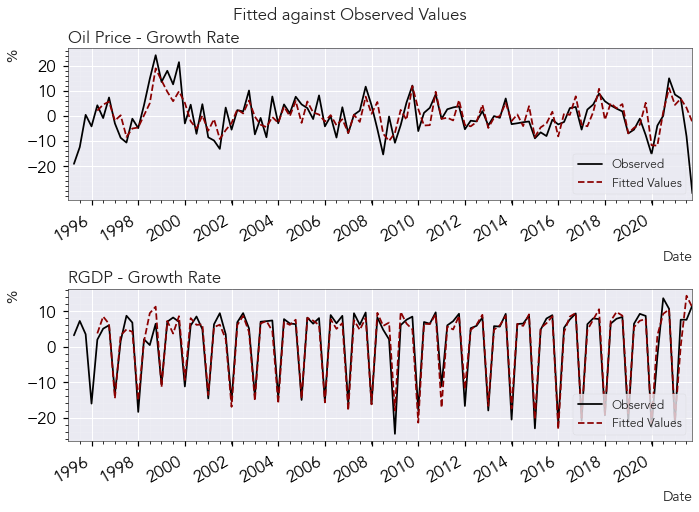

```python
insample_prediction = results.fittedvalues
fig, axes = plt.subplots(nrows = 2, ncols = 1, figsize = (6.4 * 1.5, 7), constrained_layout = True)
labels = ['Observed', 'Fitted Values']
line = ['solid', 'dashed']
color = ['black', 'darkred']
titles = ['Oil Price - Growth Rate', 'RGDP - Growth Rate']
mpl.style.use('seaborn')
mpl.rcParams['font.family'] = 'Avenir'
plt.rcParams['font.size'] = 14
mpl.rcParams['axes.linewidth'] = 0.5
mpl.rc('axes',edgecolor='black')

for i, ax in enumerate(axes.flatten()):
    ax.plot(ddata.iloc[:, i]*100, linestyle = line[0], label  = labels[0], color = color[0])
    ax.plot(insample_prediction.iloc[:, i] * 100, linestyle = line[1], label = labels[1], color = color[1])

    for label in ax.get_xticklabels(which='major'):
        label.set(rotation=30, horizontalalignment='right')
        ax.set_ylabel('$\%$', loc = 'top', fontsize = 'medium')
        ax.set_xlabel('Date', loc = 'right', fontsize = 'medium')
        ax.set_title(titles[i], fontsize = 'large', fontweight = 'bold', loc = 'left')
        ax.xaxis.set_major_locator(mdates.YearLocator(base = 2, month = 1, day = 1))
        ax.xaxis.set_major_formatter(
            mdates.ConciseDateFormatter(ax.xaxis.get_major_locator()))
        ax.grid(True, which = 'minor', color = 'white', alpha = 0.1)
        ax.set_xlim(data_ngdp.index[0], data_ngdp.index[-1])
        ax.xaxis.set_minor_locator(mpl.ticker.AutoMinorLocator())
        ax.yaxis.set_major_locator(mpl.ticker.FixedLocator([-20, -10, 0, 10, 20]))
        ax.yaxis.set_minor_locator(mpl.ticker.AutoMinorLocator())
        ax.legend(fontsize = 12, loc = 'lower right', frameon = True)



        ax.tick_params(which = 'major', colors = 'black', length = 5, width = 1.2,
                       labelsize = 'large')
        ax.tick_params(which = 'minor', length = 3, colors = 'black', width = 0.8)

fig.suptitle('Fitted against Observed Values', fontsize = 'large', fontweight = 'bold', ha = 'center')
#fig.savefig(save_graph + '07_VAR_FittedValues.png', bbox_inches = 'tight')
```

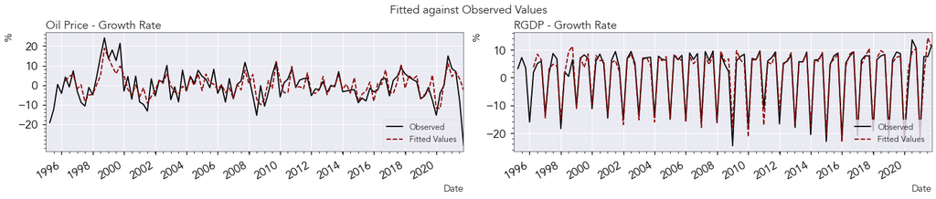

```python
insample_prediction = results.fittedvalues
fig, axes = plt.subplots(nrows = 1, ncols = 2, figsize = (6.4 * 3, 4), constrained_layout = True)
labels = ['Observed', 'Fitted Values']
line = ['solid', 'dashed']
color = ['black', 'darkred']
titles = ['Oil Price - Growth Rate', 'RGDP - Growth Rate']
mpl.style.use('seaborn')
mpl.rcParams['font.family'] = 'Avenir'
plt.rcParams['font.size'] = 14
mpl.rcParams['axes.linewidth'] = 0.5
mpl.rc('axes',edgecolor='black')

for i, ax in enumerate(axes.flatten()):
    ax.plot(ddata.iloc[:, i]*100, linestyle = line[0], label  = labels[0], color = color[0])
    ax.plot(insample_prediction.iloc[:, i] * 100, linestyle = line[1], label = labels[1], color = color[1])

    for label in ax.get_xticklabels(which='major'):
        label.set(rotation=30, horizontalalignment='right')
        ax.set_ylabel('$\%$', loc = 'top', fontsize = 'medium')
        ax.set_xlabel('Date', loc = 'right', fontsize = 'medium')
        ax.set_title(titles[i], fontsize = 'large', fontweight = 'bold', loc = 'left')
        ax.xaxis.set_major_locator(mdates.YearLocator(base = 2, month = 1, day = 1))
        ax.xaxis.set_major_formatter(
            mdates.ConciseDateFormatter(ax.xaxis.get_major_locator()))
        ax.grid(True, which = 'minor', color = 'white', alpha = 0.1)
        ax.set_xlim(data_ngdp.index[0], data_ngdp.index[-1])
        ax.xaxis.set_minor_locator(mpl.ticker.AutoMinorLocator())
        ax.yaxis.set_major_locator(mpl.ticker.FixedLocator([-20, -10, 0, 10, 20]))
        ax.yaxis.set_minor_locator(mpl.ticker.AutoMinorLocator())
        ax.legend(fontsize = 12, loc = 'lower right', frameon = True)



        ax.tick_params(which = 'major', colors = 'black', length = 5, width = 1.2,
                       labelsize = 'large')
        ax.tick_params(which = 'minor', length = 3, colors = 'black', width = 0.8)

fig.suptitle('Fitted against Observed Values', fontsize = 'large', fontweight = 'bold', ha = 'center')
fig.savefig(save_graph + '07_VAR_FittedValues.png', bbox_inches = 'tight')
```

#### **3.3.3. Granger Causality**

```python
# Does RGDP-Growth Granger-cause OIL-Price Growth?
results.test_causality(caused = 'dOIL', causing = 'dRGDP', kind = 'wald', signif = 0.05).summary()
```

Granger causality Wald-test. H_0: dRGDP does not Granger-cause dOIL. Conclusion: reject H_0 at 5% significance level.

| Test statistic | Critical value | p-value | df |
| --- | --- | --- | --- |
| 35.35 | 9.488 | 0.000 | 4 |

```python
# Does OIL-Price Growth Granger Causes RGDP-Growth?
results.test_causality(caused = 'dRGDP', causing = 'dOIL', kind = 'wald', signif = 0.05).summary()
```

Granger causality Wald-test. H_0: dOIL does not Granger-cause dRGDP. Conclusion: reject H_0 at 5% significance level.

| Test statistic | Critical value | p-value | df |
| --- | --- | --- | --- |
| 28.33 | 9.488 | 0.000 | 4 |

```python
# Test instantaneous causality
# Does dOIL instantaneously cause dRGDP?
results.test_inst_causality(causing = 'dOIL').summary()
```

Instantaneous causality Wald-test. H_0: dOIL does not instantaneously cause dRGDP. Conclusion: fail to reject H_0 at 5% significance level.

| Test statistic | Critical value | p-value | df |
| --- | --- | --- | --- |
| 0.003785 | 3.841 | 0.951 | 1 |

```python
# Does dRGDP instanteneously cause dOIL?
results.test_inst_causality(causing = 'dRGDP').summary()
```

Instantaneous causality Wald-test. H_0: dRGDP does not instantaneously cause dOIL. Conclusion: fail to reject H_0 at 5% significance level.

| Test statistic | Critical value | p-value | df |
| --- | --- | --- | --- |
| 0.003785 | 3.841 | 0.951 | 1 |

**----------------------------------- Considerations 3.2:**

The granger test shows dependency of both sides with high significance. The growth in RGDP granger causes the growth in oil prices as well as oil price growth granger-causes growth in RGDP.

#### **3.3.4. Impulse Response**

```python
help(results.irf)
```

[output not shown]

##### **3.3.4.1. Schock: RGDP-Growth**

```python
ir = results.irf(periods = 15)
impulse_dRGDP = ir.plot(impulse = ('dRGDP'), seed = 123456, orth = True, repl=1000000000000, );

# Get data information about the axis with the impulse plot.
ax = impulse_dRGDP.axes[:]
# Get lines from the plot
line0_rgdp = ax[1].get_lines()[0] # Schock + Impulse Response
x0_rgdp = line0_rgdp.get_xdata()
y0_rgdp = line0_rgdp.get_ydata()

line1_rgdp = ax[1].get_lines()[1] # lower confidence band
x1_rgdp = line1_rgdp.get_xdata()
y1_rgdp = line1_rgdp.get_ydata()

line2_rgdp = ax[1].get_lines()[2] # uppder confidence band
x2_rgdp = line2_rgdp.get_xdata()
y2_rgdp = line2_rgdp.get_ydata()

# Get data information about the axis with the response plot
line0_oil = ax[0].get_lines()[0] # Impulse response
x0_oil = line0_oil.get_xdata()
y0_oil = line0_oil.get_ydata()

line1_oil = ax[0].get_lines()[1] # lower confidence band
x1_oil = line1_oil.get_xdata()
y1_oil = line1_oil.get_ydata()

line2_oil = ax[0].get_lines()[2] # upper confidence band
x2_oil = line2_oil.get_xdata()
y2_oil = line2_oil.get_ydata()

plt.close()
```

```
No artists with labels found to put in legend.  Note that artists whose label start with an underscore are ignored when legend() is called with no argument.
No artists with labels found to put in legend.  Note that artists whose label start with an underscore are ignored when legend() is called with no argument.
```

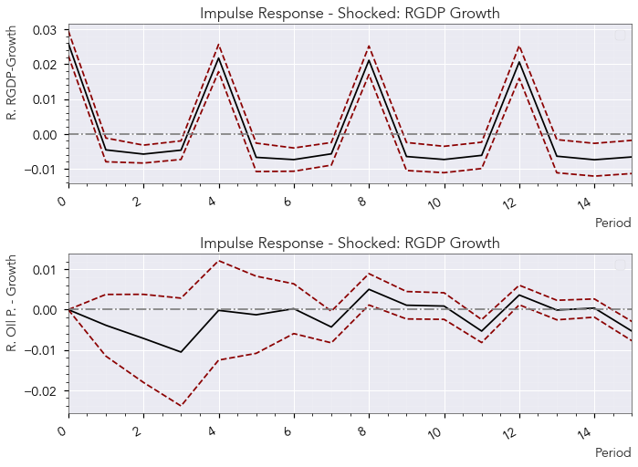

```python
# [1] Plot impulse response function. Impulse 1 standandard deviation in dRGDP, response: dOIL (Shock is orthogonal)

fig, axes = plt.subplots(nrows = 2, ncols = 1, figsize = (6.4 * 1.5, 7), constrained_layout = True)

axes[0].plot(x0_rgdp, y0_rgdp, linestyle = 'solid', color = 'black')
axes[0].plot(x1_rgdp, y1_rgdp, linestyle = '--', color = 'darkred')
axes[0].plot(x2_rgdp, y2_rgdp, linestyle = '--', color = 'darkred')
axes[0].hlines(y = 0, xmin = 0, xmax = 50, color = 'grey', linestyle = '-.')

axes[1].plot(x0_oil, y0_oil, linestyle = 'solid', color = 'black')
axes[1].plot(x1_oil, y1_oil, linestyle = '--', color = 'darkred')
axes[1].plot(x2_oil, y2_oil, linestyle = '--', color = 'darkred')
axes[1].hlines(y = 0, xmin = 0, xmax = 50, color = 'grey', linestyle = '-.')

# Format axis
ylabel = ['R. RGDP-Growth', 'R. OIl P. - Growth']

for i, ax in enumerate(axes.flatten()):
    ax.set_ylabel(ylabel[i], loc = 'top', fontsize = 'medium')
    ax.set_xlabel('Period', loc = 'right', fontsize = 'medium')
    ax.set_title('Impulse Response - Shocked: RGDP Growth', fontsize = 'large', fontweight = 'bold')
    #ax.xaxis.set_major_locator(mdates.YearLocator(base = 2, month = 1, day = 1))
    #ax.xaxis.set_major_formatter(
        #mdates.ConciseDateFormatter(ax.xaxis.get_major_locator()))
    ax.grid(True, which = 'minor', color = 'white', alpha = 0.1)
    ax.set_xlim(x1_rgdp[0], x1_rgdp[-1])
    #ax.xaxis.set_major_locator(mpl.ticker.AutoMajorlocator())
    ax.xaxis.set_minor_locator(mpl.ticker.AutoMinorLocator())
    ax.yaxis.set_minor_locator(mpl.ticker.AutoMinorLocator())

    ax.legend(fontsize = 14, frameon = True)

    for label in ax.get_xticklabels(which='major'):
        label.set(rotation=30, horizontalalignment='right')

    ax.tick_params(which = 'major', colors = 'black', length = 5, width = 1.2,
               labelsize = 'medium')
    ax.tick_params(which = 'minor', length = 3, colors = 'black', width = 0.8)
#fig.savefig(save_graph + '08_IR_Schoked_RGDP.png', bbox_inches = 'tight')
```

```python
# Cumulative Effects (Get Data for cumulative Response from a shock in RGDP)
cum_impulse_dRGDP = ir.plot_cum_effects(impulse = ('dRGDP'), seed = 123456, orth = True, repl=1000000000000);

# Get data information about the axis with the impulse plot.
ax = cum_impulse_dRGDP.axes[:]
# Get lines from the plot
line0_rgdp = ax[1].get_lines()[0] # Schock + Impulse Response
x0_rgdp = line0_rgdp.get_xdata()
y0_rgdp = line0_rgdp.get_ydata()

line1_rgdp = ax[1].get_lines()[1] # lower confidence band
x1_rgdp = line1_rgdp.get_xdata()
y1_rgdp = line1_rgdp.get_ydata()

line2_rgdp = ax[1].get_lines()[2] # uppder confidence band
x2_rgdp = line2_rgdp.get_xdata()
y2_rgdp = line2_rgdp.get_ydata()

# Get data information about the axis with the response plot
line0_oil = ax[0].get_lines()[0] # Impulse response
x0_oil = line0_oil.get_xdata()
y0_oil = line0_oil.get_ydata()

line1_oil = ax[0].get_lines()[1] # lower confidence band
x1_oil = line1_oil.get_xdata()
y1_oil = line1_oil.get_ydata()

line2_oil = ax[0].get_lines()[2] # upper confidence band
x2_oil = line2_oil.get_xdata()
y2_oil = line2_oil.get_ydata()

plt.close()
```

```
No artists with labels found to put in legend.  Note that artists whose label start with an underscore are ignored when legend() is called with no argument.
```

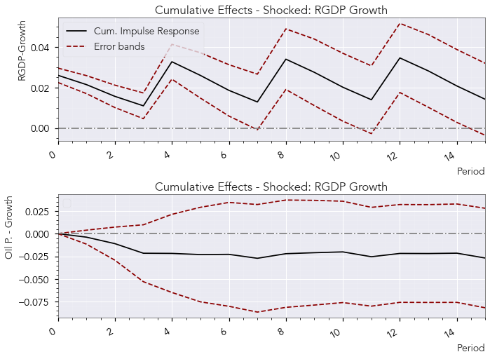

```python
# [1] Plot impulse response function. Impulse 1 standandard deviation in dRGDP, response: dOIL (Shock is orthogonal)

fig, axes = plt.subplots(nrows = 2, ncols = 1, figsize = (6.4 * 1.5, 7), constrained_layout = True)

axes[0].plot(x0_rgdp, y0_rgdp, linestyle = 'solid', color = 'black', label = 'Cum. Impulse Response')
axes[0].plot(x1_rgdp, y1_rgdp, linestyle = '--', color = 'darkred', label = 'Error bands')
axes[0].plot(x2_rgdp, y2_rgdp, linestyle = '--', color = 'darkred')
axes[0].hlines(y = 0, xmin = 0, xmax = 50, color = 'grey', linestyle = '-.')

axes[1].plot(x0_oil, y0_oil, linestyle = 'solid', color = 'black')
axes[1].plot(x1_oil, y1_oil, linestyle = '--', color = 'darkred')
axes[1].plot(x2_oil, y2_oil, linestyle = '--', color = 'darkred')
axes[1].hlines(y = 0, xmin = 0, xmax = 50, color = 'grey', linestyle = '-.')

# Format axis
ylabel = ['RGDP-Growth', 'OIl P. - Growth']

for i, ax in enumerate(axes.flatten()):
    ax.set_ylabel(ylabel[i], loc = 'top', fontsize = 'medium')
    ax.set_xlabel('Period', loc = 'right', fontsize = 'medium')
    ax.set_title('Cumulative Effects - Shocked: RGDP Growth', fontsize = 'large', fontweight = 'bold')
    #ax.xaxis.set_major_locator(mdates.YearLocator(base = 2, month = 1, day = 1))
    #ax.xaxis.set_major_formatter(
        #mdates.ConciseDateFormatter(ax.xaxis.get_major_locator()))
    ax.grid(True, which = 'minor', color = 'white', alpha = 0.1)
    ax.set_xlim(x1_rgdp[0], x1_rgdp[-1])
    #ax.xaxis.set_major_locator(mpl.ticker.AutoMajorlocator())
    ax.xaxis.set_minor_locator(mpl.ticker.AutoMinorLocator())
    ax.yaxis.set_minor_locator(mpl.ticker.AutoMinorLocator())

    ax.legend(fontsize = 14, frameon = True)

    for label in ax.get_xticklabels(which='major'):
        label.set(rotation=30, horizontalalignment='right')

    ax.tick_params(which = 'major', colors = 'black', length = 5, width = 1.2,
               labelsize = 'medium')
    ax.tick_params(which = 'minor', length = 3, colors = 'black', width = 0.8)

#fig.savefig(save_graph + '09_Cum_Response_Schoked_RGDP.png', bbox_inches = 'tight')
```

##### **3.3.4.2. Shock: Oil Price - Growth**

```python
impulse_dOIL = ir.plot(impulse = 'dOIL', seed = 123456, orth = True);

# Get data information about the axis with the impulse plot.
ax = impulse_dOIL.axes[:]
# Get lines from the plot
line0_rgdp = ax[1].get_lines()[0] # Schock + Impulse Response
x0_rgdp = line0_rgdp.get_xdata()
y0_rgdp = line0_rgdp.get_ydata()

line1_rgdp = ax[1].get_lines()[1] # lower confidence band
x1_rgdp = line1_rgdp.get_xdata()
y1_rgdp = line1_rgdp.get_ydata()

line2_rgdp = ax[1].get_lines()[2] # uppder confidence band
x2_rgdp = line2_rgdp.get_xdata()
y2_rgdp = line2_rgdp.get_ydata()

# Get data information about the axis with the response plot
line0_oil = ax[0].get_lines()[0] # Impulse response
x0_oil = line0_oil.get_xdata()
y0_oil = line0_oil.get_ydata()

line1_oil = ax[0].get_lines()[1] # lower confidence band
x1_oil = line1_oil.get_xdata()
y1_oil = line1_oil.get_ydata()

line2_oil = ax[0].get_lines()[2] # upper confidence band
x2_oil = line2_oil.get_xdata()
y2_oil = line2_oil.get_ydata()

plt.close()
```

```
No artists with labels found to put in legend.  Note that artists whose label start with an underscore are ignored when legend() is called with no argument.
No artists with labels found to put in legend.  Note that artists whose label start with an underscore are ignored when legend() is called with no argument.
```

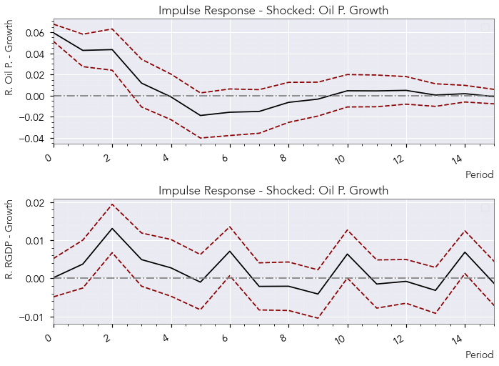

```python
# [2] Plot impulse response function. Impulse 100% deviation in dOIL, response: dRGDP

fig, axes = plt.subplots(nrows = 2, ncols = 1, figsize = (6.4 * 1.5, 7), constrained_layout = True)

axes[1].plot(x0_rgdp, y0_rgdp, linestyle = 'solid', color = 'black')
axes[1].plot(x1_rgdp, y1_rgdp, linestyle = '--', color = 'darkred')
axes[1].plot(x2_rgdp, y2_rgdp, linestyle = '--', color = 'darkred')
axes[1].hlines(y = 0, xmin = 0, xmax = 50, color = 'grey', linestyle = '-.')

axes[0].plot(x0_oil, y0_oil, linestyle = 'solid', color = 'black')
axes[0].plot(x1_oil, y1_oil, linestyle = '--', color = 'darkred')
axes[0].plot(x2_oil, y2_oil, linestyle = '--', color = 'darkred')
axes[0].hlines(y = 0, xmin = 0, xmax = 50, color = 'grey', linestyle = '-.')

# Format axis
ylabel = ['R. Oil P. - Growth', 'R. RGDP - Growth']

for i, ax in enumerate(axes.flatten()):
    ax.set_ylabel(ylabel[i], loc = 'top', fontsize = 'medium')
    ax.set_xlabel('Period', loc = 'right', fontsize = 'medium')
    ax.set_title('Impulse Response - Shocked: Oil P. Growth', fontsize = 'large', fontweight = 'bold')
    #ax.xaxis.set_major_locator(mdates.YearLocator(base = 2, month = 1, day = 1))
    #ax.xaxis.set_major_formatter(
        #mdates.ConciseDateFormatter(ax.xaxis.get_major_locator()))
    ax.grid(True, which = 'minor', color = 'white', alpha = 0.1)
    ax.set_xlim(x1_rgdp[0], x1_rgdp[-1])
    #ax.xaxis.set_major_locator(mpl.ticker.AutoMajorlocator())
    ax.xaxis.set_minor_locator(mpl.ticker.AutoMinorLocator())
    ax.yaxis.set_minor_locator(mpl.ticker.AutoMinorLocator())

    ax.legend(fontsize = 14, frameon = True)

    for label in ax.get_xticklabels(which='major'):
        label.set(rotation=30, horizontalalignment='right')

    ax.tick_params(which = 'major', colors = 'black', length = 5, width = 1.2,
               labelsize = 'medium')
    ax.tick_params(which = 'minor', length = 3, colors = 'black', width = 0.8)

#fig.savefig(save_graph + '10_IR_Schoked_OIL.png', bbox_inches = 'tight')
```

```python
# Cumulative Effects (Get Data for cumulative Response from a shock in OIL Growth)
cum_impulse_dOIL = ir.plot_cum_effects(impulse = ('dOIL'), seed = 123456, orth = True, repl=1000000000000);

# Get data information about the axis with the impulse plot.
ax = cum_impulse_dOIL.axes[:]
# Get lines from the plot
line0_rgdp = ax[1].get_lines()[0] # Schock + Impulse Response
x0_rgdp = line0_rgdp.get_xdata()
y0_rgdp = line0_rgdp.get_ydata()

line1_rgdp = ax[1].get_lines()[1] # lower confidence band
x1_rgdp = line1_rgdp.get_xdata()
y1_rgdp = line1_rgdp.get_ydata()

line2_rgdp = ax[1].get_lines()[2] # uppder confidence band
x2_rgdp = line2_rgdp.get_xdata()
y2_rgdp = line2_rgdp.get_ydata()

# Get data information about the axis with the response plot
line0_oil = ax[0].get_lines()[0] # Impulse response
x0_oil = line0_oil.get_xdata()
y0_oil = line0_oil.get_ydata()

line1_oil = ax[0].get_lines()[1] # lower confidence band
x1_oil = line1_oil.get_xdata()
y1_oil = line1_oil.get_ydata()

line2_oil = ax[0].get_lines()[2] # upper confidence band
x2_oil = line2_oil.get_xdata()
y2_oil = line2_oil.get_ydata()

plt.close()
```

```
No artists with labels found to put in legend.  Note that artists whose label start with an underscore are ignored when legend() is called with no argument.
No artists with labels found to put in legend.  Note that artists whose label start with an underscore are ignored when legend() is called with no argument.
```

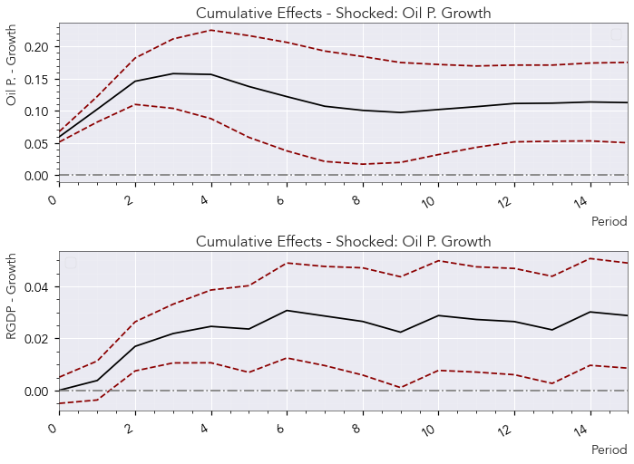

```python
# [2] Plot Cummlative Effects to a Shok in Oil Price-Growth

fig, axes = plt.subplots(nrows = 2, ncols = 1, figsize = (6.4 * 1.5, 7), constrained_layout = True)

axes[1].plot(x0_rgdp, y0_rgdp, linestyle = 'solid', color = 'black')
axes[1].plot(x1_rgdp, y1_rgdp, linestyle = '--', color = 'darkred')
axes[1].plot(x2_rgdp, y2_rgdp, linestyle = '--', color = 'darkred')
axes[1].hlines(y = 0, xmin = 0, xmax = 50, color = 'grey', linestyle = '-.')

axes[0].plot(x0_oil, y0_oil, linestyle = 'solid', color = 'black')
axes[0].plot(x1_oil, y1_oil, linestyle = '--', color = 'darkred')
axes[0].plot(x2_oil, y2_oil, linestyle = '--', color = 'darkred')
axes[0].hlines(y = 0, xmin = 0, xmax = 50, color = 'grey', linestyle = '-.')

# Format axis
ylabel = ['Oil P. - Growth', 'RGDP - Growth']

for i, ax in enumerate(axes.flatten()):
    ax.set_ylabel(ylabel[i], loc = 'top', fontsize = 'medium')
    ax.set_xlabel('Period', loc = 'right', fontsize = 'medium')
    ax.set_title('Cumulative Effects - Shocked: Oil P. Growth', fontsize = 'large', fontweight = 'bold')
    #ax.xaxis.set_major_locator(mdates.YearLocator(base = 2, month = 1, day = 1))
    #ax.xaxis.set_major_formatter(
        #mdates.ConciseDateFormatter(ax.xaxis.get_major_locator()))
    ax.grid(True, which = 'minor', color = 'white', alpha = 0.1)
    ax.set_xlim(x1_rgdp[0], x1_rgdp[-1])
    #ax.xaxis.set_major_locator(mpl.ticker.AutoMajorlocator())
    ax.xaxis.set_minor_locator(mpl.ticker.AutoMinorLocator())
    ax.yaxis.set_minor_locator(mpl.ticker.AutoMinorLocator())

    ax.legend(fontsize = 14, frameon = True)

    for label in ax.get_xticklabels(which='major'):
        label.set(rotation=30, horizontalalignment='right')

    ax.tick_params(which = 'major', colors = 'black', length = 5, width = 1.2,
               labelsize = 'medium')
    ax.tick_params(which = 'minor', length = 3, colors = 'black', width = 0.8)

#fig.savefig(save_graph + '11_Cum_Response_Schoked_OIL.png', bbox_inches = 'tight')
```

```python
# 1 [Table with the comulative effects]
print(f'{["Cumulative effect on dRGDP to a shock to dOIL", "Cumulative effect on dRGDP to a shock on dRGDP"]}')
print(ir.orth_cum_effects[:, 1])
```

```
['Cumulative effect on dRGDP to a shock to dOIL', 'Cumulative effect on dRGDP to a shock on dRGDP']
[[0.00015783 0.0260351 ]
 [0.00389395 0.02143076]
 [0.01698146 0.01562145]
 [0.02188549 0.01094147]
 [0.02462958 0.03271425]
 [0.02362242 0.0259724 ]
 [0.03073039 0.0185858 ]
 [0.02860958 0.01285088]
 [0.02652759 0.03398423]
 [0.02240924 0.02748091]
 [0.02877911 0.02012292]
 [0.02728212 0.01394799]
 [0.02647943 0.03459901]
 [0.02330495 0.02818299]
 [0.03016816 0.02075536]
 [0.02877101 0.01413025]]
```

```python
# 2 [Table with the comulative effects]
print(f'{["Cumulative effect on dOIL to a shock to dOIL", "Cumulative effect on dRGDP to a shock on dOIL"]}')
print(ir.orth_cum_effects[:, 0])
```

```
['Cumulative effect on dOIL to a shock to dOIL', 'Cumulative effect on dRGDP to a shock on dOIL']
[[ 0.0595368   0.        ]
 [ 0.10234716 -0.00389037]
 [ 0.14591076 -0.01104157]
 [ 0.15771664 -0.02159552]
 [ 0.15651065 -0.0217809 ]
 [ 0.13769839 -0.02305918]
 [ 0.12195961 -0.02282406]
 [ 0.10696864 -0.0271479 ]
 [ 0.10057    -0.02209692]
 [ 0.09726324 -0.02100309]
 [ 0.10184933 -0.02011631]
 [ 0.10631701 -0.02545081]
 [ 0.11127141 -0.02181482]
 [ 0.11178044 -0.02191839]
 [ 0.11361349 -0.02153023]
 [ 0.11265651 -0.02688975]]
```

- Long run effects of an orthogonal shock to the system:

```python
LRE_OIL = ir.orth_lr_effects[0]
LRE_RGDP = ir.orth_lr_effects[1]

print(f'Long Run effect on dOIL to a shock on itself: {LRE_OIL[0]}')
print(f'Long Run effect on dOIL to a shock on dRGDP: {LRE_OIL[1]}')
print(f'Long Run effect on dRGDP to a shock on itself: {LRE_RGDP[1]}')
print(f'Long Run effect on dRGDP to a shock on dOIL: {LRE_RGDP[0]}')
```

```
Long Run effect on dOIL to a shock on itself: 0.10950824011661242
Long Run effect on dOIL to a shock on dRGDP: -0.023366964175703296
Long Run effect on dRGDP to a shock on itself: 0.024514208132872143
Long Run effect on dRGDP to a shock on dOIL: 0.027596926747905582
```

## **Ch 4. | Analysis of Residuals**

One recall that the OLS-assumptions about residuals are:

- 1. Normality;
- 2. No (serial) correlation;
- 3. Homoscedasticity;

### **4.1. Jarque-Bera Normality Test**

```
Jarque-Bera Normality Test:
normality (skew and kurtosis) test. H_0: data generated by normally-distributed process. Conclusion: reject H_0 at 5% significance level.
========================================
Test statistic Critical value p-value df
----------------------------------------
         143.3          9.488   0.000  4
----------------------------------------
```

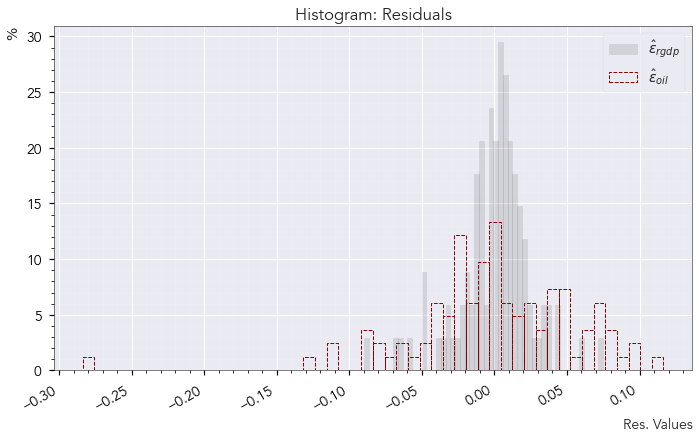

```python
# obtain residuals
residuals = results.resid
#[1.] Jarque-Bera Normality test
print('Jarque-Bera Normality Test:')
print(results.test_normality().summary())

# Plot distribution of the residuals (Histogram)
fig, ax = plt.subplots(nrows = 1, figsize = (6.4 * 1.5, 6), constrained_layout = True)
ax.hist(residuals['dRGDP'], fill = True, edgecolor = 'black', linewidth = 0.5, color = 'black', alpha = 0.1,
        label = '$\hat{ε}_{rgdp}$', density = True, bins = 50);
ax.hist(residuals['dOIL'], fill = None, edgecolor = 'darkred', linewidth = 1, label =  '$\hat{ε}_{oil}$', density = True, bins = 50, linestyle = '--');



ax.set_ylabel('$\%$', loc = 'top', fontsize = 'medium')
ax.set_xlabel('Res. Values', loc = 'right', fontsize = 'medium')
ax.set_title('Histogram: Residuals', fontsize = 'large', fontweight = 'bold')
#ax.xaxis.set_major_locator(mdates.YearLocator(base = 2, month = 1, day = 1))
#ax.xaxis.set_major_formatter(
    #mdates.ConciseDateFormatter(ax.xaxis.get_major_locator()))
ax.grid(True, which = 'minor', color = 'white', alpha = 0.1)
#ax.set_xlim(min(residuals), max(residuals))
#ax.xaxis.set_major_locator(mpl.ticker.AutoMajorlocator())
ax.xaxis.set_minor_locator(mpl.ticker.AutoMinorLocator())
ax.yaxis.set_minor_locator(mpl.ticker.AutoMinorLocator())

ax.legend(fontsize = 14, frameon = True)

for label in ax.get_xticklabels(which='major'):
    label.set(rotation=30, horizontalalignment='right')

ax.tick_params(which = 'major', colors = 'black', length = 5, width = 1.2,
               labelsize = 'medium')
ax.tick_params(which = 'minor', length = 3, colors = 'black', width = 0.8)

#fig.savefig(save_graph + '12_JarqueBera_Resid_Normality.png', bbox_inches = 'tight')
```

```python
### Jarque Bera Individualy
# dOIL
smt.jarque_bera(results.resid['dOIL']) # Reject null hypoethesis of homoscedasticity.
```

$\displaystyle \left( 117.878614452403, \ 2.52920542372708 \cdot 10^{-26}, \ -1.19740106643951, \ 7.66173619634739\right)$

```python
# dRGDP
smt.jarque_bera(results.resid['dRGDP']) # Reject null hypoethsis
```

$\displaystyle \left( 25.0909311096875, \ 3.56101281543839 \cdot 10^{-6}, \ -0.595926473777246, \ 5.1037863725283\right)$

### **4.2. Portmanteau-Test For Whiteness of Residuals (No Autocorrelation)**

```python
# [2.] Portmanteu-Test for Residual autocorrelation
print('Portmanteau-Test for residual autocorrelation:')
print(results.test_whiteness(9).summary())
```

```
Portmanteau-Test for residual autocorrelation:
Portmanteau-test for residual autocorrelation. H_0: residual autocorrelation up to lag 9 is zero. Conclusion: fail to reject H_0 at 5% significance level.
========================================
Test statistic Critical value p-value df
----------------------------------------
         30.80          31.41   0.058 20
----------------------------------------
```

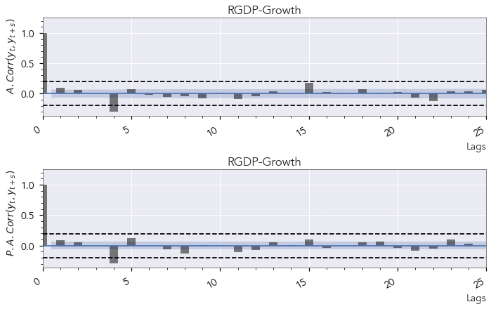

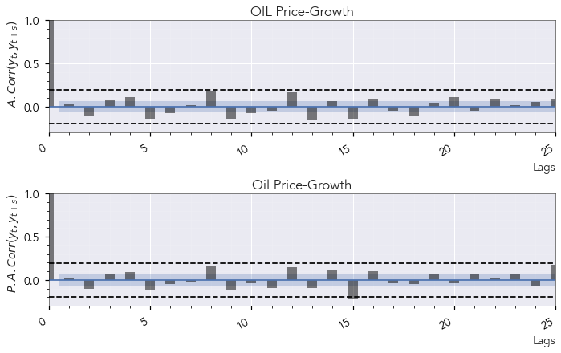

```python
residuals = results.resid


# Plots of the auto- and partial correlation functions for dRGDP residuals
fig, axes = plt.subplots(nrows = 2, ncols = 1, figsize = (6.4 * 1.5, 6), constrained_layout = True)

v_lines = {'color': 'black', 'linestyle': '-', 'linewidth': 12, 'alpha': 0.5}
plot_acf(residuals['dRGDP'], ax = axes[0], lags = 25, alpha = 0.5, use_vlines = True, adjusted = True, title = 'Autocorrelation: RGDP-Growth', auto_ylims = True, vlines_kwargs = v_lines
        , marker = None, markerfacecolor = 'black');

plot_pacf(residuals['dRGDP'], ax = axes[1], lags = 25, alpha = 0.5, use_vlines = True, title = 'Partial Autocorrelation: RGDP-Growth', auto_ylims = True, vlines_kwargs = v_lines
        , marker = None, markerfacecolor = 'black', method = 'ywm');

title = ['RGDP-Growth', 'RGDP-Growth']

y_label = ['$A. Corr(y_t, y_{t+s})$', '$P. A. Corr(y_t, y_{t+s})$']
# format axis
for i, ax in enumerate(axes.flatten()):
    ax.set_ylabel(y_label[i], loc = 'top', fontsize = 'medium')
    ax.set_xlabel('Lags', loc = 'right', fontsize = 'medium')
    ax.set_title(title[i], fontsize = 'large', fontweight = 'bold')
    ax.grid(True, which = 'minor', color = 'white', alpha = 0.1)
    ax.xaxis.set_minor_locator(mpl.ticker.AutoMinorLocator())
    ax.yaxis.set_minor_locator(mpl.ticker.AutoMinorLocator())


    for label in ax.get_xticklabels(which='major'):
        label.set(rotation=30, horizontalalignment='right')

    ax.tick_params(which = 'major', colors = 'black', length = 5, width = 1.2,
               labelsize = 'medium')
    ax.tick_params(which = 'minor', length = 3, colors = 'black', width = 0.8)
    ax.hlines(y = 2 / np.sqrt(len(residuals)), xmin = 0, xmax = 25, color = 'black', linestyle = '--')
    ax.hlines(y = -2 / np.sqrt(len(residuals)), xmin = 0, xmax = 25, color = 'black', linestyle = '--')
    ax.set_xlim(0, 25)
# Plots of the auto- and partial correlation functions for dOIL residuals
fig, axes = plt.subplots(nrows = 2, ncols = 1, figsize = (6.4 * 1.5, 6), constrained_layout = True)
title = ['OIL Price-Growth', 'Oil Price-Growth']
plot_acf(residuals['dOIL'], ax = axes[0], lags = 25, alpha = 0.5, use_vlines = True, adjusted = True, title = 'Autocorrelation: RGDP-Growth', auto_ylims = True, vlines_kwargs = v_lines
        , marker = None, markerfacecolor = 'black', bartlett_confint = False);

plot_pacf(residuals['dOIL'], ax = axes[1], lags = 25, alpha = 0.5, use_vlines = True, title = 'Partial Autocorrelation: RGDP-Growth', auto_ylims = True, vlines_kwargs = v_lines
        , marker = None, markerfacecolor = 'black', method = 'ywm');


for i, ax in enumerate(axes.flatten()):
    ax.set_ylabel(y_label[i], loc = 'top', fontsize = 'medium')
    ax.set_xlabel('Lags', loc = 'right', fontsize = 'medium')
    ax.set_title(title[i], fontsize = 'large', fontweight = 'bold')
    ax.grid(True, which = 'minor', color = 'white', alpha = 0.1)
    ax.xaxis.set_minor_locator(mpl.ticker.AutoMinorLocator())
    ax.yaxis.set_minor_locator(mpl.ticker.AutoMinorLocator())
    ax.hlines(y = 2 / np.sqrt(len(residuals)), xmin = 0, xmax = 25, color = 'black', linestyle = '--')
    ax.hlines(y = -2 / np.sqrt(len(residuals)), xmin = 0, xmax = 25, color = 'black', linestyle = '--')
    ax.set_xlim(0, 25)
    ax.set_ylim(-0.3, 1)

    for label in ax.get_xticklabels(which='major'):
        label.set(rotation=30, horizontalalignment='right')

    ax.tick_params(which = 'major', colors = 'black', length = 5, width = 1.2,
               labelsize = 'medium')
    ax.tick_params(which = 'minor', length = 3, colors = 'black', width = 0.8)

#fig.savefig(save_graph + '13_Corr_Residuals.png', bbox_inches = 'tight')
```

### **4.3. Test for Heteroscedasticity**

#### **4.3.1. Test for ARCH Effekt**

```python
# Test for ARCH effect: dOIL residuals
arch_dOIL = smd.het_arch(results.resid['dOIL'], nlags = 4, ddof = 8)

name = ['lm', 'lmpval', 'fval', 'fpval']

lzip(name, arch_dOIL) # Do not Reject H0: Homoscedasticity
```

```
[('lm', 9.064025964621653),
 ('lmpval', 0.05951890881272876),
 ('fval', 2.599647013125608),
 ('fpval', 0.04100328366517641)]
```

```python
# Test for ARCH effect: dRGDP residuals
arch_dRGDP = smd.het_arch(results.resid['dRGDP'], nlags = 4, ddof = 8)
name = ['lm', 'lmpval', 'fval', 'fpval']

lzip(name, arch_dRGDP) # Reject H0: Homoscedasticity
```

```
[('lm', 19.223810725800117),
 ('lmpval', 0.0007102249233853725),
 ('fval', 6.29400302000553),
 ('fpval', 0.00015656870673751145)]
```

### **Extra: Break-var test (Analogous to Goldfeld-Quandt):**

```python
test_statistic, p_values = smts.stattools.breakvar_heteroskedasticity_test(results.resid, subset_length = 1/3, alternative = 'two-sided', use_f = False)
test_statistic, p_values

# p values do not reject homoscedasticity for both equations in the VAR system
```

```
(array([1.4886942 , 0.92577103]), array([0.06649307, 0.81614393]))
```

#### **4.3.2 White Test**

```python
# Create dataframe with dRGDP and its lagged values
Lddata = ddata.copy()
Lddata['L1.dRGDP'] = ddata['dRGDP'].shift(1)
Lddata['L2.dRGDP'] = ddata['dRGDP'].shift(2)
Lddata['L3.dRGDP'] = ddata['dRGDP'].shift(3)
Lddata['L4.dRGDP'] = ddata['dRGDP'].shift(4)

Lddata['L1.dOIL'] = ddata['dOIL'].shift(1)
Lddata['L2.dOIL'] = ddata['dOIL'].shift(2)
Lddata['L3.dOIL'] = ddata['dOIL'].shift(3)
Lddata['L4.dOIL'] = ddata['dOIL'].shift(4)

Lddata.dropna(inplace = True)
```

```python
# Testing Heteroscedasticity of RGDP-Growth
y = Lddata['dRGDP']

#define predictor variables
x = Lddata.iloc[:, 2: 10]

#add constant to predictor variables
x = smpi.add_constant(x)

#fit regression model
model = smpi.OLS(y, x).fit()

white_test = smd.het_white(model.resid, model.model.exog)

labels = ['Test Statistic', 'Test Statistic p-value', 'F-Statistic', 'F-Test p-value']

#print results of White's test
print(dict(zip(labels, white_test)))
```

```
{'Test Statistic': 56.96566682448628, 'Test Statistic p-value': 0.09088043337387762, 'F-Statistic': 1.6311978709964894, 'F-Test p-value': 0.04041193461402886}
```

```python
# Testing Heteroscedasticity of Oil Price - Growth
y = Lddata['dOIL']

#define predictor variables
x = Lddata.iloc[:, 2: 10]

#add constant to predictor variables
x = smpi.add_constant(x)

#fit regression model
model = smpi.OLS(y, x).fit()

white_test = smd.het_white(model.resid, model.model.exog)

labels = ['Test Statistic', 'Test Statistic p-value', 'F-Statistic', 'F-Test p-value']

#print results of White's test
print(dict(zip(labels, white_test)))
```

```
{'Test Statistic': 69.84044427690797, 'Test Statistic p-value': 0.007849886247079756, 'F-Statistic': 2.776346118396545, 'F-Test p-value': 0.00015076280774917297}
```

```python
# Testing heteroscedasticity of OIL Price-Growth # With the year 2021
y = Lddata.iloc[:, 1]

#define predictor variables
x = Lddata.iloc[:, 2: 10]

#add constant to predictor variables
x = smpi.add_constant(x)

#fit regression model
model = smpi.OLS(y, x).fit()

white_test = smd.het_white(model.resid, model.model.exog)

labels = ['Test Statistic', 'Test Statistic p-value', 'F-Statistic', 'F-Test p-value']

#print results of White's test
print(dict(zip(labels, white_test)))
```

```
{'Test Statistic': 56.96566682448628, 'Test Statistic p-value': 0.09088043337387762, 'F-Statistic': 1.6311978709964894, 'F-Test p-value': 0.04041193461402886}
```

```python
# Testing Heteroscedasticity of OIL Price-Growth # Exclude the year 2021
y = Lddata.iloc[:-4, 1]

#define predictor variables
x = Lddata.iloc[:-4, 2: 10]

#add constant to predictor variables
x = smpi.add_constant(x)

#fit regression model
model = smpi.OLS(y, x).fit()

white_test = smd.het_white(model.resid, model.model.exog)

labels = ['Test Statistic', 'Test Statistic p-value', 'F-Statistic', 'F-Test p-value']

#print results of White's test
print(dict(zip(labels, white_test)))
```

```
{'Test Statistic': 51.11546797477591, 'Test Statistic p-value': 0.21437602013487347, 'F-Statistic': 1.3100810874413342, 'F-Test p-value': 0.1714990861116692}
```

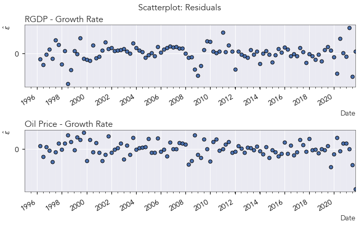

```python
# obtain residuals
residuals = results.resid
#[1.] Scatterplot
# Plot distribution of the residuals (Histogram)
fig, axes = plt.subplots(nrows = 2, figsize = (6.4 * 1.5, 6), constrained_layout = True)

axes[0].scatter(ddata.index[4:], residuals['dRGDP'], edgecolor = 'black', linewidth = 1, facecolor = None);
axes[1].scatter(ddata.index[4:], residuals['dOIL'], edgecolor = 'black', linewidth = 1);
titles = ['RGDP - Growth Rate', 'Oil Price - Growth Rate']

for i, ax in enumerate(axes.flatten()):



    for label in ax.get_xticklabels(which='major'):
        label.set(rotation=30, horizontalalignment='right')
        ax.set_ylabel('$\hat{ε}$', loc = 'top', fontsize = 'medium')
        ax.set_xlabel('Date', loc = 'right', fontsize = 'medium')
        ax.set_title(titles[i], fontsize = 'large', fontweight = 'bold', loc = 'left')
        ax.xaxis.set_major_locator(mdates.YearLocator(base = 2, month = 1, day = 1))
        ax.xaxis.set_major_formatter(
            mdates.ConciseDateFormatter(ax.xaxis.get_major_locator()))
        ax.grid(True, which = 'minor', color = 'white', alpha = 0.1)
        ax.set_xlim(data_ngdp.index[0], data_ngdp.index[-1])
        ax.xaxis.set_minor_locator(mpl.ticker.AutoMinorLocator())
        ax.yaxis.set_major_locator(mpl.ticker.FixedLocator([-20, -10, 0, 10, 20]))
        ax.yaxis.set_minor_locator(mpl.ticker.AutoMinorLocator())
        ax.tick_params(which = 'major', colors = 'black', length = 5, width = 1.2,
                       labelsize = 'medium')
        ax.tick_params(which = 'minor', length = 3, colors = 'black', width = 0.8)
fig.suptitle('Scatterplot: Residuals', fontsize = 'large', fontweight = 'bold')
#fig.savefig(save_graph + '14_Resid_Het.png', bbox_inches = 'tight')
```

### **4.4. Ramsey Reset Test: Correct Functional Form**

```python
# Testing the correct function form of Oil Price - Growth
y = Lddata['dOIL']

#define predictor variables
x = Lddata.iloc[:, 2: 10]

#add constant to predictor variables
x = smpi.add_constant(x)

#fit regression model
model = smpi.OLS(y, x).fit()

ramsey_test = smd.linear_reset(model, power = 3, test_type = 'fitted', use_f = False, cov_type = "HC3")



#print results of ramsey reset test
print(ramsey_test.summary())
```

```
<Wald test (chi2): statistic=2.5315618643058677, p-value=0.282018972439474, df_denom=2>
```

```python
# Testing the correct functional form of RGDP - Growth

y = Lddata['dRGDP']

#define predictor variables
x = Lddata.iloc[:, 2: 10]

#add constant to predictor variables
x = smpi.add_constant(x)

#fit regression model
model = smpi.OLS(y, x).fit()

white_test = ramsey_test = smd.linear_reset(model, power = 3, test_type = 'fitted', use_f = False, cov_type = "HC3")


#print results of White's test
print(ramsey_test.summary())
```

```
<Wald test (chi2): statistic=24.415170264379686, p-value=4.9924432828591565e-06, df_denom=2>
```

## **5. Bootstrapping the Sampling Distribution of the OLS-Coefficients And Test Statistics**

**Nota Bene: (For the sake of all bootstraps) When the bootstraps were done, the equation dRGDP was equation 1 in the VAR-System. Therefore, the coefficients presented in this file are not the coefficients given in the Paper, but exactly the contrary. Meaning that, in the Paper the coefficient $\phi_{i}^{11}$ is the coefficient $\phi_{i}^{21}$ in the bootstrapped values and so on...**

```
- More concreate, the bootstraps were done following the equation as:
```

$$\begin{bmatrix}dRGDP\\ dOIL \end{bmatrix}=\begin{bmatrix}\phi_{0,2}\\ \phi_{0,1} \end{bmatrix}+\sum_{i=1}^{4}\begin{bmatrix}\phi_{i}^{11} & \phi_{i}^{12}\\ \phi_{i}^{21} & \phi_{i}^{22} \end{bmatrix}\begin{bmatrix}dRGDP\\ dOIL \end{bmatrix}_{t-i}+\begin{bmatrix}\varepsilon_{1}\\ \varepsilon_{2} \end{bmatrix}_{t}$$

Still it does not change anything on the results of the bootstraps. (The equations were changed in the paper for the sake of the impulse response function)

### **5.1. Theory**

1. **Wald Test for Granger Causality:** The regression model reads as following for equation i:

$$ \mathbf{y}_{i,t} = \mathbf{X}\beta+\varepsilon_{t} $$

where $\mathbf{X}=\begin{bmatrix}1 & \mathbf{y}_{i,t-1} & \mathbf{y}_{j,t-1} & \mathbf{y}_{i,t-2} & \mathbf{y}_{j,t-2} & \mathbf{y}_{i,t-3} & \mathbf{y}_{j,t-3} & \mathbf{y}_{i,t-4} & \mathbf{y}_{j,t-4}\end{bmatrix}$.

As the test for homoscedasticity rejects the hypothesis of homoscedastic errors, the stated standard errors of the regression estimators are invalid, which possibly makes the test for Granger-Causality invalid as well.

Recall that the Wald-Test as well as the Likelihood ratio test both converge to a $\chi^{2}$ distribution. Further both rely on the normality of parameters. This is not the case here.

Thus, instead of relying on theroy and on the asymptotic properties of these tests, we use a bootstrapping method to derive the distribution of the Wald-Test for our sake, forcing the null hypothesis to be true.

- The test consists in estimating n times the coefficients (heteroscedastic robust) by sampling with replacement. The sampling in Regression can be done in two ways, one by the residuals and one by resampling $\left(y_{i}^{*},x_{i}^{*}\right)$ pairwise. We choose the latter method, as this keeps the structure of the residuals, which are heteroscedastic in the present discussion.
- By each repetition the $\hat{\Sigma}^{*}$ matrix is computed for the bootstrapped coefficients and and Wald test is carried out. It is important to note, that we force the null hypothesis to be true. As we see the sample coefficients are the population values, the Wald statistic becomes:

$$\mathbf{W}_{i} = \left(\mathbf{R}\mathbf{b}^{*}-\mathbf{b}\right)^{T}\left(\mathbf{R}\hat{\Sigma}^{*}\mathbf{R}^{T}\right)^{-1}\left(\mathbf{R}\mathbf{b}^{*}-\mathbf{b}\right)$$

- Where $\mathbf{b}^{*}$ is a vector with the bootstrapped coefficients and \mathbf{b} is the coefficients estimates from the origianl sample data.

The restriction matrices for this firtst and second regression are:

- $R_{1}=\begin{bmatrix}0 & 0 & 1 & 0 & 0 & 0 & 0 & 0 & 0\\ 0 & 0 & 0 & 0 & 1 & 0 & 0 & 0 & 0\\ 0 & 0 & 0 & 0 & 0 & 0 & 1 & 0 & 0\\ 0 & 0 & 0 & 0 & 0 & 0 & 0 & 0 & 1\end{bmatrix}$
- $R_{2}=\begin{bmatrix}0 & 1 & 0 & 0 & 0 & 0 & 0 & 0 & 0\\0 & 0 & 0 & 1 & 0 & 0 & 0 & 0 & 0\\0 & 0 & 0 & 0 & 0 & 1 & 0 & 0 & 0\\0 & 0 & 0 & 0 & 0 & 0 & 0 & 1 & 0\end{bmatrix}$
2. The T-Statistic for Inference about a single coefficient.

Recall that the T-test is in small samples T distributed and that this distribution converges to a normal distribution, when the OLS-Assumptions hold.

As the **VAR** regression of statsmodels do not allows us to correct for the heteroscedasticity of the residuals and the residuals do not follow a normal distribution, the standard error of the estimated coefficients cannot be used in the T-Test.

For this reason, a bootstrap of the T-Statistic for all coefficient (just like in the terms explained above) gives the reader the distribution under $H0$. This allows us to make inferences about a single coefficient.

3. The Ramsey-Reset Test

The Ramsey Reset test includes polynomials of fitted values of the dependent variable as regressors. Let our model be represented by:

$$\begin{bmatrix}y_{1,t}\\ y_{2,t} \end{bmatrix} = \beta+\sum_{k=1}^{k=4}\begin{bmatrix}\phi_{k}^{11} & \phi_{k}^{12}\\ \phi_{k}^{21} & \phi_{k}^{22} \end{bmatrix}\begin{bmatrix}y_{1,t-k}\\ y_{2,t-k} \end{bmatrix}+\begin{bmatrix}\widehat{y}_{1,t}^{2} & \widehat{y}_{1,t}^{3}\\ \widehat{y}_{2,t}^{2} & \widehat{y}_{2,t}^{3} \end{bmatrix}\begin{bmatrix}\varPsi_{1}\\ \varPsi_{2} \end{bmatrix}+\upsilon_{t}$$

In a more concise way:

$$ \mathbf{y}_{i} = \mathbf{X}_{i}\beta_{i} $$

where $\mathbf{X}_{i}=\begin{bmatrix}1 & \mathbf{y}_{i,t-1} & \mathbf{y}_{j,t-1} & \mathbf{y}_{i,t-2} & \mathbf{y}_{j,t-2} & \mathbf{y}_{i,t-3} & \mathbf{y}_{j,t-3} & \mathbf{y}_{i,t-4} & \mathbf{y}_{j,t-4} & \mathbf{\hat{y}}_{i}^{2} & \hat{\mathbf{y}}_{i}^{3}\end{bmatrix}$, with $\left[i,j\right]=\left[1,2\right]$ and $\beta_{i}=\begin{bmatrix}\beta_{i0} & \phi_{1}^{i1} & \phi_{1}^{i2} & \dots & \phi_{4}^{i1} & \phi_{4}^{i2} & \varPsi_{1} & \varPsi_{2}\end{bmatrix}$.

We would like to test whether the linear model is a good model to fit the data. This is the same as saying, we would like $\varPsi_{1}=\varPsi_{2}=0$. The null hypothesis is tested by means of a Wald test and under the null hypothesis, this test is $\chi^{2}\left(q\right)$ distributed, being $q$ the number of restriction. So our restriction matrix equals:

$$R_{i} = \begin{bmatrix}0 & 0 & 0 & 0 & 0 & 0 & 0 & 0 & 0 & 1 & 0\\ 0 & 0 & 0 & 0 & 0 & 0 & 0 & 0 & 0 & 0 & 1 \end{bmatrix}$$

for each regression. Again is the problem with the non-normality and heteroscedasticity of the residuals. (Under the null hypothesis the Wald-Test will not follow a $\chi^{2}$ distribution), as the error term is not normal and thus also not the variance covariance matrix of the estimated parameters. Accordingly we need to estimate the distribution of this test under the null hypothesis being true!

### **5.2. The Bootstrapp**

```python
# Create dataframe with dRGDP and its lagged values
Lddata = ddata.copy()
Lddata['L1.dRGDP'] = ddata['dRGDP'].shift(1)
Lddata['L2.dRGDP'] = ddata['dRGDP'].shift(2)
Lddata['L3.dRGDP'] = ddata['dRGDP'].shift(3)
Lddata['L4.dRGDP'] = ddata['dRGDP'].shift(4)

Lddata['L1.dOIL'] = ddata['dOIL'].shift(1)
Lddata['L2.dOIL'] = ddata['dOIL'].shift(2)
Lddata['L3.dOIL'] = ddata['dOIL'].shift(3)
Lddata['L4.dOIL'] = ddata['dOIL'].shift(4)

Lddata.dropna(inplace = True)

####################### Procedure:

# First bootstrap the regression coefficients dRGDP ~ L1.dRGDP + L1dOIL + ... + L4.dRGDP + L5.dOIL + ε
#boot_eq1_1mio, boot_eq2_1mio = fc.bootstrap_coeff(data = Lddata, reps = 1000000, regression1 = 'dRGDP ~ Q("L1.dRGDP") + Q("L1.dOIL") + Q("L2.dRGDP") + Q("L2.dOIL") + Q("L3.dRGDP") + Q("L3.dOIL") + Q("L4.dRGDP") + Q("L4.dOIL")',
         #regression2 = 'dOIL ~ Q("L1.dRGDP") + Q("L1.dOIL") + Q("L2.dRGDP") + Q("L2.dOIL") + Q("L3.dRGDP") + Q("L3.dOIL") + Q("L4.dRGDP") + Q("L4.dOIL")')
#Bootstrapping
# = bootstrap(data = Lddata, reps = 1000000, regression1 = 'dRGDP ~ Q("L1.dRGDP") + Q("L1.dOIL") + Q("L2.dRGDP") + Q("L2.dOIL") + Q("L3.dRGDP") + Q("L3.dOIL") + Q("L4.dRGDP") + Q("L4.dOIL")',
         #regression2 = 'dOIL ~ Q("L1.dRGDP") + Q("L1.dOIL") + Q("L2.dRGDP") + Q("L2.dOIL") + Q("L3.dRGDP") + Q("L3.dOIL") + Q("L4.dRGDP") + Q("L4.dOIL")')

# Export the estimated coefficients
#boot_eq1_1mio.to_csv(path_bootstrapp + '00_CoefficientsEq1_1000000.csv')
#boot_eq2_1mio.to_csv(path_boostrapp + '00_CoefficientsEq2_1000000.csv')
```

```python
# Import the data set with the bootstrapped estimators
boot_dRGDP = pd.read_csv(path_bootstrapp + '00_CoefficientsEq1_1000000.csv', index_col = 'Unnamed: 0')
boot_dOIL = pd.read_csv(path_bootstrapp + '00_CoefficientsEq2_1000000.csv', index_col = 'Unnamed: 0')
boot_dRGDP.rename(columns = {
    'b0': 'Intercept',
    'b1': 'L1.dRGDP',
    'b2': 'L1.dOIL',
    'b3': 'L2.dRGDP',
    'b4': 'L2.dOIL',
    'b5': 'L3.dRGDP',
    'b6': 'L3.dOIL',
    'b7': 'L4.dRGDP',
    'b8': 'L4.dOIL'}, inplace = True)

boot_dOIL.columns = boot_dRGDP.columns

boot_dRGDP.shape, boot_dOIL.shape
```

$\displaystyle \left( \left( 1000000, \ 9\right), \ \left( 1000000, \ 9\right)\right)$

### **5.3. Wald-Statistic Test**

If the coefficients are asymptotical normally distributed, then we can compute the variance-covariance matrix from the bootstrapped coefficients and use them in the Wald Test. In this case the Wald-Test would follow a $\chi^{2}$ distribution. If this is not the case, then we need to derive the distribution of the test.

#### **5.3.1. Mean and Variance-Covariance Matrix of the Bootstrapped Coefficients**

```python
mean_coeff_dRGDP = boot_dRGDP.mean()
mean_coeff_dOIL = boot_dOIL.mean()
var_cov_dRGDP = boot_dRGDP.cov()
var_cov_dOIL = boot_dOIL.cov()
```

```python
print(f'mean coefficients dRGDP: \n\n{mean_coeff_dRGDP}\n'),
print(f'mean coefficients dOIL: \n\n{mean_coeff_dOIL}\n')
```

```
mean coefficients dRGDP:

Intercept    0.006206
L1.dRGDP    -0.176803
L1.dOIL      0.060879
L2.dRGDP    -0.241424
L2.dOIL      0.183770
L3.dRGDP    -0.216574
L3.dOIL     -0.041416
L4.dRGDP     0.782222
L4.dOIL      0.009011
dtype: float64

mean coefficients dOIL:

Intercept    0.001213
L1.dRGDP    -0.142447
L1.dOIL      0.713564
L2.dRGDP    -0.189539
L2.dOIL      0.222532
L3.dRGDP    -0.236587
L3.dOIL     -0.445176
L4.dRGDP     0.168572
L4.dOIL      0.062199
dtype: float64
```

- Again the VAR-Model for Comparison:

```python
results.summary()
```

```
  Summary of Regression Results
==================================
Model:                         VAR
Method:                        OLS
Date:           Mon, 15, Aug, 2022
Time:                     20:44:59
--------------------------------------------------------------------
No. of Equations:         2.00000    BIC:                   -12.3119
Nobs:                     103.000    HQIC:                  -12.5858
Log likelihood:           383.472    FPE:                2.84087e-06
AIC:                     -12.7723    Det(Omega_mle):     2.40264e-06
--------------------------------------------------------------------
Results for equation dOIL
===========================================================================
              coefficient       std. error           t-stat            prob
---------------------------------------------------------------------------
const            0.001378         0.007235            0.190           0.849
L1.dOIL          0.719453         0.121599            5.917           0.000
L1.dRGDP        -0.149428         0.150012           -0.996           0.319
L2.dOIL          0.224271         0.130936            1.713           0.087
L2.dRGDP        -0.193596         0.145493           -1.331           0.183
L3.dOIL         -0.443761         0.138729           -3.199           0.001
L3.dRGDP        -0.241825         0.146559           -1.650           0.099
L4.dOIL          0.061666         0.121824            0.506           0.613
L4.dRGDP         0.166993         0.158799            1.052           0.293
===========================================================================

Results for equation dRGDP
===========================================================================
              coefficient       std. error           t-stat            prob
---------------------------------------------------------------------------
const            0.006101         0.003164            1.928           0.054
L1.dOIL          0.063222         0.053175            1.189           0.234
L1.dRGDP        -0.176851         0.065601           -2.696           0.007
L2.dOIL          0.186109         0.057258            3.250           0.001
L2.dRGDP        -0.244963         0.063625           -3.850           0.000
L3.dOIL         -0.042889         0.060667           -0.707           0.480
L3.dRGDP        -0.217365         0.064091           -3.392           0.001
L4.dOIL          0.008199         0.053274            0.154           0.878
L4.dRGDP         0.781734         0.069443           11.257           0.000
===========================================================================

Correlation matrix of residuals
             dOIL     dRGDP
dOIL     1.000000  0.006062
dRGDP    0.006062  1.000000
```

```python
# The standard error of the bootstrapped coefficients
se_coeff_dRGDP = boot_dRGDP.std()
se_coeff_dOIL = boot_dOIL.std()
print(f'standard-error coefficients dRGDP: \n\n{se_coeff_dRGDP}')
print(f'standard-error coefficients dOIL: \n\n{se_coeff_dOIL}')
```

```
standard-error coefficients dRGDP:

Intercept    0.003611
L1.dRGDP     0.079754
L1.dOIL      0.060813
L2.dRGDP     0.065932
L2.dOIL      0.068339
L3.dRGDP     0.062628
L3.dOIL      0.061632
L4.dRGDP     0.071906
L4.dOIL      0.064744
dtype: float64
standard-error coefficients dOIL:

Intercept    0.007901
L1.dRGDP     0.136479
L1.dOIL      0.174054
L2.dRGDP     0.128793
L2.dOIL      0.130797
L3.dRGDP     0.178378
L3.dOIL      0.182504
L4.dRGDP     0.160132
L4.dOIL      0.115877
dtype: float64
```

- Variance-Covariance matrix for RGDP-Growth coefficients:

```python
cov_dRGDP = np.asarray(boot_dRGDP)
boot_dRGDP.cov()
```

|  | Intercept | L1.dRGDP | L1.dOIL | L2.dRGDP | L2.dOIL | L3.dRGDP | L3.dOIL | L4.dRGDP | L4.dOIL |
| --- | --- | --- | --- | --- | --- | --- | --- | --- | --- |
| Intercept | 0.000013 | -0.000203 | 0.000051 | -0.000162 | -0.000088 | -0.000138 | 0.000002 | -0.000174 | 0.000092 |
| L1.dRGDP | -0.000203 | 0.006361 | -0.001606 | 0.004264 | 0.002979 | 0.004314 | -0.000240 | 0.004853 | -0.002915 |
| L1.dOIL | 0.000051 | -0.001606 | 0.003698 | -0.001399 | -0.001181 | -0.000359 | -0.001810 | -0.000176 | 0.001347 |
| L2.dRGDP | -0.000162 | 0.004264 | -0.001399 | 0.004347 | 0.000867 | 0.003144 | 0.001027 | 0.003773 | -0.002332 |
| L2.dOIL | -0.000088 | 0.002979 | -0.001181 | 0.000867 | 0.004670 | 0.001446 | -0.000786 | 0.001729 | -0.002255 |
| L3.dRGDP | -0.000138 | 0.004314 | -0.000359 | 0.003144 | 0.001446 | 0.003922 | -0.000957 | 0.003676 | -0.001281 |
| L3.dOIL | 0.000002 | -0.000240 | -0.001810 | 0.001027 | -0.000786 | -0.000957 | 0.003798 | -0.000044 | -0.001511 |
| L4.dRGDP | -0.000174 | 0.004853 | -0.000176 | 0.003773 | 0.001729 | 0.003676 | -0.000044 | 0.005171 | -0.002930 |
| L4.dOIL | 0.000092 | -0.002915 | 0.001347 | -0.002332 | -0.002255 | -0.001281 | -0.001511 | -0.002930 | 0.004192 |

- Variance-Covariance matrix for Oil Price-Growth coefficients:

```python
cov_dOIL = np.asarray(boot_dOIL.cov())
boot_dOIL.cov()
```

|  | Intercept | L1.dRGDP | L1.dOIL | L2.dRGDP | L2.dOIL | L3.dRGDP | L3.dOIL | L4.dRGDP | L4.dOIL |
| --- | --- | --- | --- | --- | --- | --- | --- | --- | --- |
| Intercept | 0.000062 | -0.000620 | -0.000718 | -0.000573 | 0.000276 | -0.001061 | 0.000808 | -0.000852 | -0.000008 |
| L1.dRGDP | -0.000620 | 0.018627 | 0.004216 | 0.013571 | 0.001860 | 0.018793 | -0.009923 | 0.017928 | -0.002150 |
| L1.dOIL | -0.000718 | 0.004216 | 0.030295 | 0.006281 | -0.011453 | 0.018880 | -0.020804 | 0.015149 | 0.005626 |
| L2.dRGDP | -0.000573 | 0.013571 | 0.006281 | 0.016588 | -0.005193 | 0.015870 | -0.004097 | 0.017540 | -0.003085 |
| L2.dOIL | 0.000276 | 0.001860 | -0.011453 | -0.005193 | 0.017108 | -0.005171 | 0.003005 | -0.005649 | -0.002199 |
| L3.dRGDP | -0.001061 | 0.018793 | 0.018880 | 0.015870 | -0.005171 | 0.031819 | -0.023819 | 0.024519 | 0.003147 |
| L3.dOIL | 0.000808 | -0.009923 | -0.020804 | -0.004097 | 0.003005 | -0.023819 | 0.033308 | -0.013809 | -0.009407 |
| L4.dRGDP | -0.000852 | 0.017928 | 0.015149 | 0.017540 | -0.005649 | 0.024519 | -0.013809 | 0.025642 | -0.002304 |
| L4.dOIL | -0.000008 | -0.002150 | 0.005626 | -0.003085 | -0.002199 | 0.003147 | -0.009407 | -0.002304 | 0.013427 |

#### **5.3.2. Plot of the Sampling Distribution of $\beta$**

##### **5.3.2.1. RGDP-Growth Rate Coefficients**

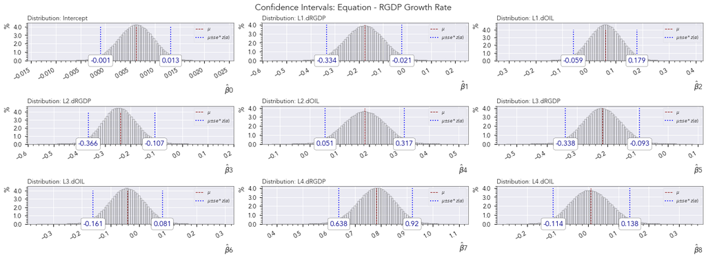

```python
fig, axes = plt.subplots(nrows = 3, ncols = 3, figsize = (6.4 * 3, 7), constrained_layout = True)

for i, ax in enumerate(axes.flatten()):
    ax.hist(boot_dRGDP[boot_dRGDP.columns[i]], fill = None, edgecolor = 'black', bins = 100, density = False)
    ax.set_title('Distribution: ' + str(boot_dRGDP.columns[i]), loc = 'left')
    locs = ax.get_yticks()
    ax.set_yticks(locs, np.round(locs/len(boot_dRGDP) * 100,3), minor=False)
    # format axis
    ax.set_ylabel('%', loc = 'top', fontsize = 'medium')
    ax.vlines(ymin = 0, ymax = 40000, x = mean_coeff_dRGDP[i], color = 'darkred', linewidth = 1, linestyle = 'dashed', label = '$μ$')

    # Create confidence intervals
    ax.vlines(ymin = 0, ymax = 40000, x = np.quantile(boot_dRGDP[boot_dRGDP.columns[i]], 0.025), color = 'blue', linestyle = 'dotted', label = '$μ±se*z(α)$')
    ax.annotate(text = str(round(np.quantile(boot_dRGDP[boot_dRGDP.columns[i]], 0.025), 3)), xy = [np.quantile(boot_dRGDP[boot_dRGDP.columns[i]], 0.025), 10], va="center", ha="center",
                  bbox=dict(boxstyle="round", fc="w"), weight = 'bold', color = 'darkblue')
    ax.annotate(text = str(round(np.quantile(boot_dRGDP[boot_dRGDP.columns[i]], 0.975), 3)), xy = [np.quantile(boot_dRGDP[boot_dRGDP.columns[i]], 0.975), 10], weight = 'bold', va="center", ha="center",
                  bbox=dict(boxstyle="round", fc="w"), color = 'darkblue')
    ax.vlines(ymin = 0, ymax = 40000, x = np.quantile(boot_dRGDP[boot_dRGDP.columns[i]], 0.975), color = 'blue', linestyle = 'dotted')
    ax.legend()
    ax.set_xlabel('$\hat{β}$' + str(i), loc = 'right', fontsize = 'medium')
    fig.suptitle('Confidence Intervals: Equation - RGDP Growth Rate', fontsize = 'large', weight = 'bold')

    #ax.grid(True, which = 'minor', color = 'white', alpha = 0.1)
    ax.xaxis.set_minor_locator(mpl.ticker.AutoMinorLocator())
    ax.yaxis.set_minor_locator(mpl.ticker.AutoMinorLocator())
    ax.legend(fontsize = 8, frameon = True)

    for label in ax.get_xticklabels(which='major'):
        label.set(rotation=30, horizontalalignment='right')

    ax.tick_params(which = 'major', colors = 'black', length = 5, width = 1.2,
                   labelsize = 'small')
    ax.tick_params(which = 'minor', length = 3, colors = 'black', width = 0.8)
#fig.savefig(save_graph + '16_Boot_RGDP_CI.png', bbox_inches = 'tight')
```

##### **5.3.2.1. Oil Price-Growth Rate Coefficients**

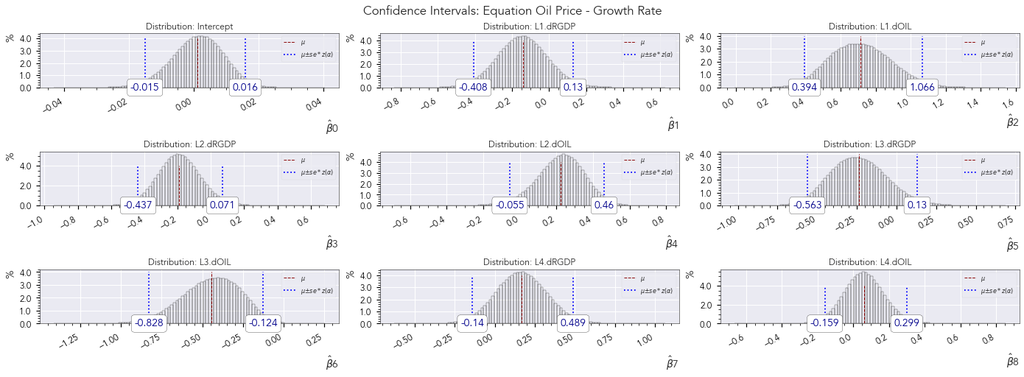

```python
fig, axes = plt.subplots(nrows = 3, ncols = 3, figsize = (6.4 * 3, 7), constrained_layout = True)

for i, ax in enumerate(axes.flatten()):
    ax.hist(boot_dOIL[boot_dOIL.columns[i]], fill = None, edgecolor = 'black', bins = 100, density = False)
    ax.set_title('Distribution: ' + str(boot_dOIL.columns[i]))
    locs = ax.get_yticks()
    ax.set_yticks(locs, np.round(locs/len(boot_dOIL) * 100,3), minor=False)
    # format axis
    ax.set_ylabel('%', loc = 'top', fontsize = 'medium')
    ax.vlines(ymin = 0, ymax = 40000, x = mean_coeff_dOIL[i], color = 'darkred', linewidth = 1, linestyle = 'dashed', label = '$μ$')

    # Create confidence intervals
    ax.vlines(ymin = 0, ymax = 40000, x = np.quantile(boot_dOIL[boot_dOIL.columns[i]], 0.025), color = 'blue', linestyle = 'dotted', label = '$μ±se*z(α)$')
    ax.annotate(text = str(round(np.quantile(boot_dOIL[boot_dOIL.columns[i]], 0.025), 3)), xy = [np.quantile(boot_dOIL[boot_dOIL.columns[i]], 0.025), 10], va="center", ha="center",
                  bbox=dict(boxstyle="round", fc="w"), weight = 'bold', color = 'darkblue')
    ax.annotate(text = str(round(np.quantile(boot_dOIL[boot_dOIL.columns[i]], 0.975), 3)), xy = [np.quantile(boot_dOIL[boot_dOIL.columns[i]], 0.975), 10], weight = 'bold', va="center", ha="center",
                  bbox=dict(boxstyle="round", fc="w"), color = 'darkblue')
    ax.vlines(ymin = 0, ymax = 40000, x = np.quantile(boot_dOIL[boot_dOIL.columns[i]], 0.975), color = 'blue', linestyle = 'dotted')
    ax.legend()
    ax.set_xlabel('$\hat{β}$' + str(i), loc = 'right', fontsize = 'medium')
    fig.suptitle('Confidence Intervals: Equation Oil Price - Growth Rate', fontsize = 'large', weight = 'bold')

    #ax.grid(True, which = 'minor', color = 'white', alpha = 0.1)
    ax.xaxis.set_minor_locator(mpl.ticker.AutoMinorLocator())
    ax.yaxis.set_minor_locator(mpl.ticker.AutoMinorLocator())
    ax.legend(fontsize = 8, frameon = True)

    for label in ax.get_xticklabels(which='major'):
        label.set(rotation=30, horizontalalignment='right')

    ax.tick_params(which = 'major', colors = 'black', length = 5, width = 1.2,
                   labelsize = 'small')
    ax.tick_params(which = 'minor', length = 3, colors = 'black', width = 0.8)
#fig.savefig(save_graph + '17_Boot_OIL_CI.png', bbox_inches = 'tight')
```

#### **5.3.3. Jarque-Bera Test: Normality of the Coefficients**

##### **5.3.3.1. RGDP-Growth Coefficients**

```python
for i in boot_dRGDP:
    jarque_bera_test = stats.jarque_bera(boot_dRGDP[i])
    print(jarque_bera_test)
```

```
Jarque_beraResult(statistic=770.1565230785433, pvalue=0.0)
Jarque_beraResult(statistic=91.03988488585405, pvalue=0.0)
Jarque_beraResult(statistic=441.25897357332525, pvalue=0.0)
Jarque_beraResult(statistic=5113.303966072381, pvalue=0.0)
Jarque_beraResult(statistic=492.2794694244226, pvalue=0.0)
Jarque_beraResult(statistic=177.5311904202153, pvalue=0.0)
Jarque_beraResult(statistic=389.80706603069154, pvalue=0.0)
Jarque_beraResult(statistic=1525.5821798091483, pvalue=0.0)
Jarque_beraResult(statistic=1785.9456702769262, pvalue=0.0)
```

**----------------------------------- Considerations 5.1:**

- After one million repetition, the sampling distribution of the coefficients did not converge to a normal distribution. Thus, we cannot rely on the $\chi^2$ distribution even asymptotically. We will need to derive the distribution of the Wald-Test for Granger Causality by bootstrapping it.

### **5.4. Bootstrap: Wald-Test**

#### **5.4.1. The Bootstrap**

```python
# Create Restriction matrices for the wald test
# Regression 1

R1 = np.array([
    [0, 0, 1, 0, 0, 0, 0, 0, 0],
    [0, 0, 0, 0, 1, 0, 0, 0, 0],
    [0, 0, 0, 0, 0, 0, 1, 0, 0],
    [0, 0, 0, 0, 0, 0, 0, 0, 1],
])

# Regression 2
R2 = np.array([
    [0, 1, 0, 0, 0, 0, 0, 0, 0],
    [0, 0, 0, 1, 0, 0, 0, 0, 0],
    [0, 0, 0, 0, 0, 1, 0, 0, 0],
    [0, 0, 0, 0, 0, 0, 0, 1, 0],
])

#boot_eq1GC, boot_eq2GC, GCWaldtest = fc.bootstrap_Wald(data = Lddata, reps = 200000, regression1 = 'dRGDP ~ Q("L1.dRGDP") + Q("L1.dOIL") + Q("L2.dRGDP") + Q("L2.dOIL") + Q("L3.dRGDP") + Q("L3.dOIL") + Q("L4.dRGDP") + Q("L4.dOIL")',
         #regression2 = 'dOIL ~ Q("L1.dRGDP") + Q("L1.dOIL") + Q("L2.dRGDP") + Q("L2.dOIL") + Q("L3.dRGDP") + Q("L3.dOIL") + Q("L4.dRGDP") + Q("L4.dOIL")', rest_matrix1 = R1, rest_matrix2 = R2)
#boot_eqGC.to_csv(path_bootstrapp + '01_BootstrapEq1GCWald.csv')
#boot_eqGC.to_csv(path_bootstrapp + '01_BootstrapEq2GCWald.csv')
#GCWaldtest.to_csv(path_bootstrapp + '01_GCWald.csv')
```

```python
# Import dataset with the 200,000 WaldTests
GCWaldtest = pd.read_csv(path_bootstrapp + '01_GCWald.csv')
GCWaldtest.drop(index = 0, inplace = True)
GCWaldtest.drop(columns = 'Unnamed: 0', inplace = True)
GCWaldtest
```

|  | Wald-Test1 | Wald-Test2 |
| --- | --- | --- |
| 1 | 1.966601 | 4.992330 |
| 2 | 0.313530 | 1.898128 |
| 3 | 3.112574 | 3.131193 |
| 4 | 2.980390 | 4.584687 |
| 5 | 5.855069 | 2.677782 |
| ... | ... | ... |
| 199995 | 0.419129 | 5.684359 |
| 199996 | 2.474119 | 5.512692 |
| 199997 | 4.966870 | 3.796660 |
| 199998 | 9.987509 | 2.117918 |
| 199999 | 7.069341 | 0.982684 |

199999 rows × 2 columns

#### **5.4.2. The Monte Carlo P-Value**

$$Pr\left[T<T_{\left(r\right)}^{*}\Bigg|H_{0}\right] = \frac{r}{R+1}$$

> where as usual $T_{\left(r\right)}^{*}$ denotes the $r^{th}$ ordered value. If exactly k of the simulated $t^{*}$ values exceed t and none equal it, then

$$p = Pr\left(T\geq t\bigg|H_{0}\right)\\ p = p_{mc}\\ p_{mc} = \frac{k+1}{R+1}\\ $$

> If T is continuous, then it follows [...] that under $H_{0}$ the distribution of the corresponding random variable p_{mc} is uniform one \left(\frac{1}{R+1},\dots,\frac{R}{R+1},1\right). This results [...] guarantees that $p_{mc}$ has the error rate interpretation. In this sense the Monte Carlo test is exact.

> [...] If $T$ is discrete, then repeat values of $t^{*}$ can occur. If exactly $l$ of the $t^{*}$ values equal $t$, then it is sometimes advacated that one bounds the significance probability,

$$\frac{k+1}{R+1}\leq p_{mc} \leq\frac{k+l+1}{R+1}$$

> Our strict interpretation of $p=Pr\left(T\geq t\bigg|H_{0}\right)$ would have us use the upper bound, and so we adopt the general defination

$$p_{mc} = \frac{1+\#\left\{ t_{r}^{*}\geq t\right\} }{R+1}$$"

Source: Davison, A., & Hinkley, D. (1997). The Basic Bootstraps. In Bootstrap Methods and their Application (Cambridge Series in Statistical and Probabilistic Mathematics, pp. 140-141). Cambridge: Cambridge University Press. doi:10.1017/CBO9780511802843.003

```python
# Calculate the Wald Test for the coefficients with the null hypotheses that b(i) = 0
reg_dRGDP = sm.ols(formula = 'dRGDP ~ Q("L1.dRGDP") + Q("L1.dOIL") + Q("L2.dRGDP") + Q("L2.dOIL") + Q("L3.dRGDP") + Q("L3.dOIL") + Q("L4.dRGDP") + Q("L4.dOIL")', data = Lddata).fit(cov_type = 'HC3')
reg_dOIL = sm.ols(formula = 'dOIL ~ Q("L1.dRGDP") + Q("L1.dOIL") + Q("L2.dRGDP") + Q("L2.dOIL") + Q("L3.dRGDP") + Q("L3.dOIL") + Q("L4.dRGDP") + Q("L4.dOIL")', data = Lddata).fit(cov_type = 'HC3')

cov_dRGDP = reg_dRGDP.cov_params()
cov_dOIL = reg_dOIL.cov_params()

#Wald Test equation one, the null hypothesis is that b2, b4, b6, b8 = 0
# Wald Test equation two, the null hypothesis is that b1, b3, b5, b7 = 0
W_dRGDP = (R1 @ reg_dRGDP.params).T @ np.linalg.inv(R1 @ cov_dRGDP @ R1.T) @ (R1 @ reg_dRGDP.params)
W_dOIL = (R2 @ reg_dOIL.params).T @ np.linalg.inv(R2 @ cov_dOIL @ R2.T) @ (R2 @ reg_dOIL.params)

print(W_dRGDP)
print(W_dOIL)
```

```
15.096686523402258
46.506698967293
```

```python
# Calculate the p-value
filt1 = GCWaldtest['Wald-Test1'] >= W_dRGDP
filt2 = GCWaldtest['Wald-Test2'] >= W_dOIL
N = len(GCWaldtest)
# The number of bootstrapped Wald-Tests that has a value greater than the one computed from the regression is
p_GCdRGDP = (len(GCWaldtest.loc[filt1, 'Wald-Test1']) + 1) / (N + 1)
p_GCdOIL = (len(GCWaldtest.loc[filt2, 'Wald-Test2']) + 1) / (N + 1)

print(f'pval dRGDP: {p_GCdRGDP}')
print(f'pval dOIL: {p_GCdOIL}')
```

```
pval dRGDP: 0.03159
pval dOIL: 7.5e-05
```

```python
#### Comparison with the P-Values of stats VAR-Model wich assumes that the distribution of the test is 𝛘²(4) for each equation.

print('Comparison with Granger Causality Test, where the structure of the residuals is ignored.\n')
results.test_causality(caused = 'dRGDP', causing = 'dOIL', kind = 'wald', signif = 0.05).summary()
```

```
Comparison with Granger Causality Test, where the structure of the residuals is ignored.
```

Granger causality Wald-test. H_0: dOIL does not Granger-cause dRGDP. Conclusion: reject H_0 at 5% significance level.

| Test statistic | Critical value | p-value | df |
| --- | --- | --- | --- |
| 28.33 | 9.488 | 0.000 | 4 |

```python
results.test_causality(caused = 'dOIL', causing = 'dRGDP', kind = 'wald', signif = 0.05).summary()
```

Granger causality Wald-test. H_0: dRGDP does not Granger-cause dOIL. Conclusion: reject H_0 at 5% significance level.

| Test statistic | Critical value | p-value | df |
| --- | --- | --- | --- |
| 35.35 | 9.488 | 0.000 | 4 |

#### **5.4.3. Comparison of the Theoretical with the Empirical W-Test Distribution: Plot of the Data**

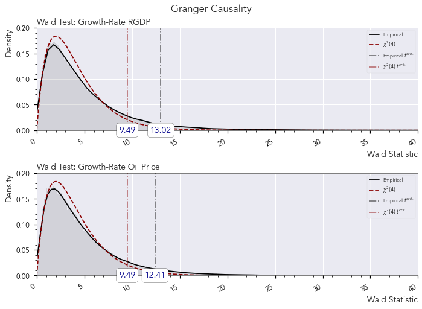

```python
# Compare distribution with chi2 distribution with 4 degrees of freedom

# Chi-Square distribution
x = np.linspace(0, 40, num = 400)
fx = stats.chi2.pdf(x, 4)
W_stat_theoretical = stats.chi2.ppf(1 - 0.05, df = 4)
W_stat_empirical = [np.quantile(GCWaldtest['Wald-Test1'], 0.95), np.quantile(GCWaldtest['Wald-Test2'], 0.95)]

fig, axes = plt.subplots(nrows = 2, ncols = 1, figsize = (6.4 * 1.5, 7), constrained_layout = True)
labels = ['Wald Test: Growth-Rate RGDP', 'Wald Test: Growth-Rate Oil Price']
xAxes = ['Wald-Stat']
fig.suptitle('Granger Causality', fontsize = 'large', weight = 'bold')
for i, ax in enumerate(axes.flatten()):
    sns.distplot(GCWaldtest[GCWaldtest.columns[i]], hist = True, kde = True, bins = 2000, hist_kws = {'edgecolor': None, 'fill': 'grey', 'alpha': 0.1},
             kde_kws = {'label': 'Empirical'}, color = 'black', ax = axes[i])
    ax.plot(x, fx, color = 'darkred', linestyle = 'dashed', label = '$\chi^{2}(4)$')
    ax.vlines(x = W_stat_empirical[i], ymin = 0, ymax = 0.2, color = 'black', linestyle = '-.', label = 'Empirical $t^{crit.}$', alpha = 0.5)
    ax.vlines(x = W_stat_theoretical, ymin = 0, ymax = 0.2, color = 'darkred', linestyle = '-.', label = '$\chi^{2}(4)$ $t^{crit.}$', alpha = 0.5)
    ax.set_title(labels[i], weight = 'bold', fontsize = 'medium', loc = 'left')
    ax.legend()

    locs = ax.get_yticks()
    #ax.set_yticks(locs, round(locs * 100), minor=False)
    # format axis
    ax.set_ylabel('Density', loc = 'top', fontsize = 'medium')
    ax.set_xlabel('Wald Statistic', loc = 'right', fontsize = 'medium')

    #ax.grid(True, which = 'minor', color = 'white', alpha = 0.1)
    ax.xaxis.set_minor_locator(mpl.ticker.AutoMinorLocator())
    ax.yaxis.set_minor_locator(mpl.ticker.AutoMinorLocator())
    ax.legend(fontsize = 8, frameon = True)
    ax.set_xlim(0, 40)
    ax.set_ylim(0, 0.2)
    for label in ax.get_xticklabels(which='major'):
        label.set(rotation=30, horizontalalignment='right')

    ax.tick_params(which = 'major', colors = 'black', length = 5, width = 1.2,
                   labelsize = 'small')
    ax.tick_params(which = 'minor', length = 3, colors = 'black', width = 0.8)

    ax.annotate(text = round(W_stat_theoretical, 2), xy = [W_stat_theoretical, 0], weight = 'bold', va="center", ha="center", bbox=dict(boxstyle="round", fc="w"), color = 'darkblue')
    ax.annotate(text = round(W_stat_empirical[i], 2), xy = [W_stat_empirical[i], 0], weight = 'bold', va="center", ha="center", bbox=dict(boxstyle="round", fc="w"), color = 'darkblue')
#fig.savefig(save_graph + '20_GCWaldTest.png', bbox_inches = 'tight')
```

**----------------------------------- Considerations 5.2:**

By comparing the theoretical $\chi^{2}\left(4\right)$ with the empirical distribution, one sees that reliance on the theoretical distribution would lead to rejection of the null hypothesis too often.

But we can based on the p-value (monte carlo) still asserting that dRGDP cause dOIL and that dOIL causes dRGDP.

### **5.5. Bootstrap: T-Test**

#### **5.5.1. The Bootstrap**

```python
#boot_eq1V3, boot_eq2V3, T_test1, T_test2, var1, var2 = fc.bootstrap_Tstat(data = Lddata, reps = 200000, regression1 = 'dRGDP ~ Q("L1.dRGDP") + Q("L1.dOIL") + Q("L2.dRGDP") + Q("L2.dOIL") + Q("L3.dRGDP") + Q("L3.dOIL") + Q("L4.dRGDP") + Q("L4.dOIL")',
                                                                   #regression2 = 'dOIL ~ Q("L1.dRGDP") + Q("L1.dOIL") + Q("L2.dRGDP") + Q("L2.dOIL") + Q("L3.dRGDP") + Q("L3.dOIL") + Q("L4.dRGDP") + Q("L4.dOIL")')

#T_test1.to_csv(path_bootstrapp + '/02_BootstrapEq1_T_Test.csv')
#T_test2.to_csv(path_bootstrapp + '02_BootstrapEq2_T_Test.csv')
#boot_eq1V3.to_csv(path_bootstrapp + '02_BootstrapEq1_Coeff_T_Test.csv')
#boot_eq2V3.to_csv(path_bootstrapp + '02_BootstrapEq2_Coeff_T_Test.csv')
#var1.to_csv(path_bootstrapp + '02_BootstrapEq1_T_Test_VAR.csv')
#var2.to_csv(path_bootstrapp + '02_BootstrapEq2_T_Test_VAR.csv')

T_test1 = pd.read_csv(path_bootstrapp + '02_BootstrapEq1_T_Test.csv')
T_test2 = pd.read_csv(path_bootstrapp + '02_BootstrapEq2_T_Test.csv')

T_test1.drop(columns = 'Unnamed: 0', inplace = True)
T_test2.drop(columns = 'Unnamed: 0', inplace = True)

T_test1.drop(index = 0, inplace = True)
T_test2.drop(index = 0, inplace = True)
```

```python
#T_test1.drop(index = 0, inplace = True)
#T_test2.drop(index = 0, inplace = True)

# Rename columns of T_Test
T_test1.rename(columns = {
    'T_b0': 'T_stat: Intercept',
    'T_b1': 'T_stat: L1.dRGDP',
    'T_b2': 'T_stat: L1.dOIL',
    'T_b3': 'T_stat: L2.dRGDP',
    'T_b4': 'T_stat: L2.dOIL',
    'T_b5': 'T_stat: L3.dRGDP',
    'T_b6': 'T_stat: L3.dOIL',
    'T_b7': 'T_stat: L4.dRGDP',
    'T_b8': 'T_stat: L4.dOIL'
}, inplace = True)

T_test2.columns = T_test1.columns
```

#### **5.5.2. T-Critical Values: Plots**

```python
# Carry out T-test with the estimated coefficients and get the results
# Regression dRGDP
Tregression_rgdp = sm.ols(formula = 'dRGDP ~ Q("L1.dRGDP") + Q("L1.dOIL") + Q("L2.dRGDP") + Q("L2.dOIL") + Q("L3.dRGDP") + Q("L3.dOIL") + Q("L4.dRGDP") + Q("L4.dOIL")',
                          data = Lddata).fit(cov_type = 'HC3').tvalues

Tregression_oil = sm.ols(formula = 'dOIL ~ Q("L1.dRGDP") + Q("L1.dOIL") + Q("L2.dRGDP") + Q("L2.dOIL") + Q("L3.dRGDP") + Q("L3.dOIL") + Q("L4.dRGDP") + Q("L4.dOIL")',
                          data = Lddata).fit(cov_type = 'HC3').tvalues
# calculate t-invervals
intervals1 = np.zeros((9, 3))
intervals2 = np.zeros((9, 3))
interpretation = np.zeros(9)
for i in range(9):
    intervals1[i] = np.quantile(T_test1.iloc[:, i], (0.025, 0.975))[0], np.quantile(T_test1.iloc[:, i], (0.025, 0.975))[1], Tregression_rgdp[i]
    intervals2[i] = np.quantile(T_test1.iloc[:, i], (0.025, 0.975))[0], np.quantile(T_test2.iloc[:, i], (0.025, 0.975))[1], Tregression_oil[i]


T_intervals1 = pd.DataFrame(data = intervals1, columns = ['lower', 'upper', 'T-statistic'], index = cov_dRGDP.index)
T_intervals2 = pd.DataFrame(data = intervals2, columns = ['lower', 'upper', 'T-statistic'], index = cov_dOIL.index)

T_intervals1['Reject H0'] = interpretation
T_intervals2['Reject H0'] = interpretation

# Confidence Intervals dRGDP ~ dOIL
for i, value in enumerate(T_intervals1['T-statistic']):
    if (value >= T_intervals1.iloc[i, 0]) & (value <= T_intervals1.iloc[i, 1]):
        T_intervals1.iloc[i, 3] = False
    else:
        T_intervals1.iloc[i, 3] = True

# Confidence Intervals dOIL ~ dRDGP
for i, value in enumerate(T_intervals2['T-statistic']):
    if (value >= T_intervals2.iloc[i, 0]) & (value <= T_intervals2.iloc[i, 1]):
        T_intervals2.iloc[i, 3] = False
    else:
        T_intervals2.iloc[i, 3] = True

print('T-Test critical values: Eq. dRGDP:')
T_intervals1
```

```
T-Test critical values: Eq. dRGDP:
```

|  | lower | upper | T-statistic | Reject H0 |
| --- | --- | --- | --- | --- |
| Intercept | -1.825388 | 2.128131 | 1.523700 | False |
| Q("L1.dRGDP") | -1.988897 | 1.991225 | -1.981299 | False |
| Q("L1.dOIL") | -1.932618 | 2.002053 | 0.956924 | False |
| Q("L2.dRGDP") | -1.950319 | 1.927835 | -3.438908 | True |
| Q("L2.dOIL") | -2.451664 | 1.817695 | 2.399364 | True |
| Q("L3.dRGDP") | -1.904128 | 1.921485 | -3.242669 | True |
| Q("L3.dOIL") | -1.818860 | 2.125687 | -0.639313 | False |
| Q("L4.dRGDP") | -1.842468 | 2.014197 | 9.974610 | True |
| Q("L4.dOIL") | -2.005914 | 2.121834 | 0.110472 | False |

```python
print('T-Test critical values: Eq. dOIL:')
T_intervals2
```

```
T-Test critical values: Eq. dOIL:
```

|  | lower | upper | T-statistic | Reject H0 |
| --- | --- | --- | --- | --- |
| Intercept | -1.825388 | 2.273063 | 0.159440 | False |
| Q("L1.dRGDP") | -1.988897 | 1.910347 | -1.040037 | False |
| Q("L1.dOIL") | -1.932618 | 1.698468 | 3.683434 | True |
| Q("L2.dRGDP") | -1.950319 | 1.827040 | -1.459661 | False |
| Q("L2.dOIL") | -2.451664 | 2.217110 | 1.642812 | False |
| Q("L3.dRGDP") | -1.904128 | 1.709980 | -1.208883 | False |
| Q("L3.dOIL") | -1.818860 | 2.649369 | -2.183438 | True |
| Q("L4.dRGDP") | -1.842468 | 1.810293 | 0.967815 | False |
| Q("L4.dOIL") | -2.005914 | 1.703149 | 0.513981 | False |

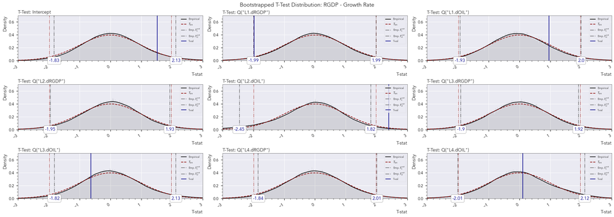

```python
# Compare with T-Values # First Equation:
x = np.linspace(-10, 10, num = 100)
t_dist = stats.t.pdf(x, df = 103 - 9)

t_crit_theoretical = [stats.t.ppf(1 - 0.025, df = 103 - 9), stats.t.ppf(0.025, df = 103 - 9)]
fig, axes = plt.subplots(nrows = 3, ncols = 3, figsize = (6.4 * 4, 9), constrained_layout = True)

for i, ax in enumerate(axes.flatten()):
    sns.distplot(T_test1[T_test1.columns[i]], hist = True, kde = True, bins = 2000, hist_kws = {'edgecolor': None, 'fill': 'grey', 'alpha': 0.1},
             kde_kws = {'label': 'Empirical'}, color = 'black', ax = ax)
    ax.plot(x, t_dist, color = 'darkred', linestyle = 'dashed', label = '$T_{94}$')
    ax.vlines(x = t_crit_theoretical[0], ymin = 0, ymax = 1, color = 'darkred', linestyle = '-.', alpha = 0.5)
    ax.vlines(x = t_crit_theoretical[1], ymin = 0, ymax = 1, color = 'darkred', linestyle = '-.', alpha = 0.5)

    ax.vlines(x = T_intervals1.iloc[i, 0], ymin = 0, ymax = 1, label = 'Emp. $t^{crit}_{L}$', color = 'black', linestyle = '-.', alpha = 0.5)
    ax.vlines(x = T_intervals1.iloc[i, 1], ymin = 0, ymax = 1, label = 'Emp. $t^{crit}_{U}$', color = 'black', linestyle = '-.', alpha = 0.5)
    ax.vlines(x = T_intervals1.iloc[i, 2], ymin = 0, ymax = 1, label = 'T-val', linestyle = 'solid', color = 'darkblue')
    fig.suptitle('Bootstrapped T-Test Distribution: RGDP - Growth Rate', fontsize = 'large', weight = 'bold')
    ax.set_xlim(-3, 3)
    ax.set_ylim(0, 0.7)
    ax.set_xlabel('T-stat', loc = 'right', fontsize = 'medium')
    ax.set_ylabel('Density', loc = 'top', fontsize = 'medium')
    ax.set_title('T-Test: ' + T_intervals1.index[i], fontsize = 'medium', weight = 'bold', loc = 'left')
    ax.annotate(text = round(T_intervals1.iloc[i, 0], 2), xy = [T_intervals1.iloc[i, 0], 0], weight = 'bold', va="center", ha="center", bbox=dict(boxstyle="round", fc="w"), color = 'darkblue')
    ax.annotate(text = round(T_intervals1.iloc[i, 1], 2), xy = [T_intervals1.iloc[i, 1], 0], weight = 'bold', va="center", ha="center", bbox=dict(boxstyle="round", fc="w"), color = 'darkblue')

    #locs = ax.get_yticks()
    #ax.set_yticks(locs, round(locs * 100), minor=False)
    # format axis

    #ax.grid(True, which = 'minor', color = 'white', alpha = 0.1)
    ax.xaxis.set_minor_locator(mpl.ticker.AutoMinorLocator())
    ax.yaxis.set_minor_locator(mpl.ticker.AutoMinorLocator())
    ax.legend(fontsize = 8, frameon = True)

    for label in ax.get_xticklabels(which='major'):
        label.set(rotation=30, horizontalalignment='right')

    ax.tick_params(which = 'major', colors = 'black', length = 5, width = 1.2,
                   labelsize = 'small')
    ax.tick_params(which = 'minor', length = 3, colors = 'black', width = 0.8)
#fig.savefig(save_graph + '18_TDist_RGDP.png', bbox_inches = 'tight')
```

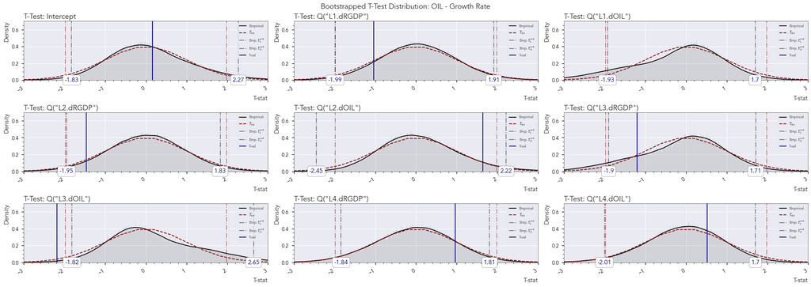

```python
### #Second Equation

# Compare with T-Values # First Equation:
x = np.linspace(-10, 10)
t_dist = stats.t.pdf(x, df = 103 - 9)

t_crit_theoretical = [stats.t.ppf(1 - 0.025, df = 103 - 9), stats.t.ppf(0.025, df = 103 - 9)]
fig, axes = plt.subplots(nrows = 3, ncols = 3, figsize = (6.4 * 4, 9), constrained_layout = True)

for i, ax in enumerate(axes.flatten()):
    sns.distplot(T_test2[T_test2.columns[i]], hist = True, kde = True, bins = 2000, hist_kws = {'edgecolor': None, 'fill': 'grey', 'alpha': 0.1},
             kde_kws = {'label': 'Empirical'}, color = 'black', ax = ax)
    ax.plot(x, t_dist, color = 'darkred', linestyle = 'dashed', label = '$T_{94}$')
    ax.vlines(x = t_crit_theoretical[0], ymin = 0, ymax = 1, color = 'darkred', linestyle = '-.', alpha = 0.5)
    ax.vlines(x = t_crit_theoretical[1], ymin = 0, ymax = 1, color = 'darkred', linestyle = '-.', alpha = 0.5)

    ax.vlines(x = T_intervals2.iloc[i, 0], ymin = 0, ymax = 1, label = 'Emp. $t^{crit}_{L}$', color = 'black', linestyle = '-.', alpha = 0.5)
    ax.vlines(x = T_intervals2.iloc[i, 1], ymin = 0, ymax = 1, label = 'Emp. $t^{crit}_{U}$', color = 'black', linestyle = '-.', alpha = 0.5)
    ax.vlines(x = T_intervals2.iloc[i, 2], ymin = 0, ymax = 1, label = 'T-val', linestyle = 'solid', color = 'darkblue')
    fig.suptitle('Bootstrapped T-Test Distribution: OIL - Growth Rate', fontsize = 'large', weight = 'bold')
    ax.set_xlim(-3, 3)
    ax.set_ylim(0, 0.7)
    ax.set_xlabel('T-stat', loc = 'right', fontsize = 'medium')
    ax.set_ylabel('Density', loc = 'top', fontsize = 'medium')
    ax.set_title('T-Test: ' + T_intervals2.index[i], fontsize = 'large', weight = 'bold', loc = 'left')
    ax.annotate(text = round(T_intervals2.iloc[i, 0], 2), xy = [T_intervals2.iloc[i, 0], 0], weight = 'bold', va="center", ha="center", bbox=dict(boxstyle="round", fc="w"), color = 'darkblue')
    ax.annotate(text = round(T_intervals2.iloc[i, 1], 2), xy = [T_intervals2.iloc[i, 1], 0], weight = 'bold', va="center", ha="center", bbox=dict(boxstyle="round", fc="w"), color = 'darkblue')

    #locs = ax.get_yticks()
    #ax.set_yticks(locs, round(locs * 100), minor=False)
    # format axis

    #ax.grid(True, which = 'minor', color = 'white', alpha = 0.1)
    ax.xaxis.set_minor_locator(mpl.ticker.AutoMinorLocator())
    ax.yaxis.set_minor_locator(mpl.ticker.AutoMinorLocator())
    ax.legend(fontsize = 8, frameon = True)

    for label in ax.get_xticklabels(which='major'):
        label.set(rotation=30, horizontalalignment='right')

    ax.tick_params(which = 'major', colors = 'black', length = 5, width = 1.2,
                   labelsize = 'small')
    ax.tick_params(which = 'minor', length = 3, colors = 'black', width = 0.8)

#fig.savefig(save_graph + '19_TDist_OIL.png', bbox_inches = 'tight')
```

### **5.6. The Ramsey-Reset Test (Bootstrapp)**

#### **5.6.1. Procedure**

```python
#boot_eq1_Ramsey, boot_eq2_Ramsey, Waldtest_Ramsey = fc.bootstrap_Ramsey(data = Lddata, reps = 200000, regression1 = 'dRGDP ~ Q("L1.dRGDP") + Q("L1.dOIL") + Q("L2.dRGDP") + Q("L2.dOIL") + Q("L3.dRGDP") + Q("L3.dOIL") + Q("L4.dRGDP") + Q("L4.dOIL")',
         #regression2 = 'dOIL ~ Q("L1.dRGDP") + Q("L1.dOIL") + Q("L2.dRGDP") + Q("L2.dOIL") + Q("L3.dRGDP") + Q("L3.dOIL") + Q("L4.dRGDP") + Q("L4.dOIL")')

#boot_eq1_Ramsey.to_csv(path_bootstrapp + '03_Eq1_coeff_Ramsey.csv')
#boot_eq2_Ramsey.to_csv(path_bootstrapp + '03_Eq2_coeff_Ramsey.csv')
#Waldtest_Ramsey.to_csv(path_bootstrapp + '03_WaldTest_Ramsey.csv')
```

```python
# import bootstrapped datasets
Waldtest_Ramsey = pd.read_csv(path_bootstrapp + '03_WaldTest_Ramsey.csv')
Waldtest_Ramsey.drop(index = 0, inplace = True)
Waldtest_Ramsey.drop(columns = 'Unnamed: 0', inplace = True)

Waldtest_Ramsey.head()
```

|  | Wald-Test1 | Wald-Test2 |
| --- | --- | --- |
| 1 | 2.525695 | 0.168434 |
| 2 | 0.290696 | 0.648311 |
| 3 | 2.218053 | 0.342906 |
| 4 | 1.547404 | 0.993782 |
| 5 | 0.157757 | 3.970225 |

#### **5.6.2. Monte Carlo P-value**

```python
# Create polynomials of the fitted values

reg_dRGDP = sm.ols(formula = 'dRGDP ~ Q("L1.dRGDP") + Q("L1.dOIL") + Q("L2.dRGDP") + Q("L2.dOIL") + Q("L3.dRGDP") + Q("L3.dOIL") + Q("L4.dRGDP") + Q("L4.dOIL")', data = Lddata).fit(cov_type = 'HC3')
reg_dOIL = sm.ols(formula = 'dOIL ~ Q("L1.dRGDP") + Q("L1.dOIL") + Q("L2.dRGDP") + Q("L2.dOIL") + Q("L3.dRGDP") + Q("L3.dOIL") + Q("L4.dRGDP") + Q("L4.dOIL")', data = Lddata).fit(cov_type = 'HC3')

dRGDP_fit = reg_dRGDP.fittedvalues
dOIL_fit = reg_dOIL.fittedvalues

Lddata["y1_sqrt"] = dRGDP_fit ** 2
Lddata["y1_cub"] = dRGDP_fit ** 3
Lddata["y2_sqrt"] = dOIL_fit ** 2
Lddata["y2_cub"] = dOIL_fit ** 3

# Create restriction matrix
R = np.array([
        [0, 0, 0, 0, 0, 0, 0, 0, 0, 1, 0],
        [0, 0, 0, 0, 0, 0, 0, 0, 0, 0, 1]
])

# 2. Stage OLS with polynomials included

reg_dRGDP_Ramsey = sm.ols(formula = 'dRGDP ~ Q("L1.dRGDP") + Q("L1.dOIL") + Q("L2.dRGDP") + Q("L2.dOIL") + Q("L3.dRGDP") + Q("L3.dOIL") + Q("L4.dRGDP") + Q("L4.dOIL") + Q("y1_sqrt") + Q("y1_cub")',
                          data = Lddata).fit(cov_type = 'HC3')
reg_dOIL_Ramsey = sm.ols(formula = 'dOIL ~ Q("L1.dRGDP") + Q("L1.dOIL") + Q("L2.dRGDP") + Q("L2.dOIL") + Q("L3.dRGDP") + Q("L3.dOIL") + Q("L4.dRGDP") + Q("L4.dOIL") + Q("y2_sqrt") + Q("y2_cub")',
                          data = Lddata).fit(cov_type = 'HC3')

cov_dRGDP_Ramsey = reg_dRGDP_Ramsey.cov_params()
cov_dOIL_Ramsey = reg_dOIL_Ramsey.cov_params()
# Wthe null hypothesis is that the polynomials coefficients are not significant different than zero

W_dRGDP_Ramsey = (R @ reg_dRGDP_Ramsey.params).T @ np.linalg.inv(R @ cov_dRGDP_Ramsey @ R.T) @ (R @ reg_dRGDP_Ramsey.params)
W_dOIL_Ramsey = (R @ reg_dOIL_Ramsey.params).T @ np.linalg.inv(R @ cov_dOIL_Ramsey @ R.T) @ (R @ reg_dOIL_Ramsey.params)
```

```python
W_dRGDP_Ramsey, W_dOIL_Ramsey
```

$\displaystyle \left( 24.4151702643796, \ 2.53156186430585\right)$

```python
# Calculate the p-value
filt1 = Waldtest_Ramsey['Wald-Test1'] >= W_dRGDP_Ramsey
filt2 = Waldtest_Ramsey['Wald-Test2'] >= W_dOIL_Ramsey
N = len(Waldtest_Ramsey)
# The number of bootstrapped Wald-Tests that has a value greater than the one computed from the regression is
p_Ramsey_dRGDP = (len(Waldtest_Ramsey.loc[filt1, 'Wald-Test1']) + 1) / (N + 1)
p_Ramsey_dOIL = (len(Waldtest_Ramsey.loc[filt2, 'Wald-Test2']) + 1) / (N + 1)

print(f'pval dRGDP: {p_Ramsey_dRGDP}')
print(f'pval dOIL: {p_Ramsey_dOIL}')
```

```
pval dRGDP: 0.00239
pval dOIL: 0.227405
```

```python
smd.linear_reset(reg_dRGDP, power= 3, test_type='fitted', use_f=False, cov_type='HC3', cov_kwargs=None)
```

```
<class 'statsmodels.stats.contrast.ContrastResults'>
<Wald test (chi2): statistic=24.415170264379572, p-value=4.992443282859435e-06, df_denom=2>
```

```python
smd.linear_reset(reg_dOIL, power= 3, test_type='fitted', use_f=False, cov_type='HC3', cov_kwargs=None)
```

```
<class 'statsmodels.stats.contrast.ContrastResults'>
<Wald test (chi2): statistic=2.531561864305862, p-value=0.2820189724394748, df_denom=2>
```

#### **5.6.2. Plot Distribution**

```python
reg_dOIL_Ramsey.params
```

```
Intercept       -0.007634
Q("L1.dRGDP")   -0.059822
Q("L1.dOIL")     0.661882
Q("L2.dRGDP")   -0.115869
Q("L2.dOIL")     0.222700
Q("L3.dRGDP")   -0.124137
Q("L3.dOIL")    -0.447251
Q("L4.dRGDP")    0.242228
Q("L4.dOIL")     0.051344
Q("y2_sqrt")     1.976880
Q("y2_cub")      3.604911
dtype: float64
```

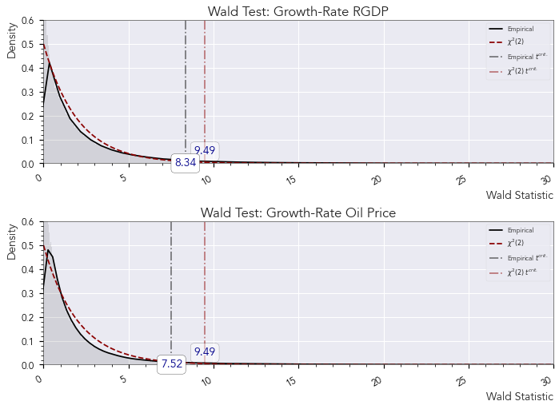

```python
# Compare distribution with chi2 distribution with 2 degrees of freedom

# Chi-Square distribution
x = np.linspace(0, 40, num = 400)
fx = stats.chi2.pdf(x, 2)
W_stat_theoretical = stats.chi2.ppf(1 - 0.05, df = 4)
W_stat_empirical = [np.quantile(Waldtest_Ramsey['Wald-Test1'], 0.95), np.quantile(Waldtest_Ramsey['Wald-Test2'], 0.95)]

fig, axes = plt.subplots(nrows = 2, ncols = 1, figsize = (6.4 * 1.5, 7), constrained_layout = True)
labels = ['Wald Test: Growth-Rate RGDP', 'Wald Test: Growth-Rate Oil Price']
xAxes = ['Wald-Stat']

for i, ax in enumerate(axes.flatten()):
    sns.distplot(Waldtest_Ramsey[Waldtest_Ramsey.columns[i]], hist = True, kde = True, bins = 2000, hist_kws = {'edgecolor': None, 'fill': 'grey', 'alpha': 0.1},
             kde_kws = {'label': 'Empirical'}, color = 'black', ax = axes[i])
    ax.plot(x, fx, color = 'darkred', linestyle = 'dashed', label = '$\chi^{2}(2)$')
    ax.vlines(x = W_stat_empirical[i], ymin = 0, ymax = 0.6, color = 'black', linestyle = '-.', label = 'Empirical $t^{crit.}$', alpha = 0.5)
    ax.vlines(x = W_stat_theoretical, ymin = 0, ymax = 0.6, color = 'darkred', linestyle = '-.', label = '$\chi^{2}(2)$ $t^{crit.}$', alpha = 0.5)
    ax.set_title(labels[i], weight = 'bold', fontsize = 'large')
    ax.legend()

    locs = ax.get_yticks()
    #ax.set_yticks(locs, round(locs * 100), minor=False)
    # format axis
    ax.set_ylabel('Density', loc = 'top', fontsize = 'medium')
    ax.set_xlabel('Wald Statistic', loc = 'right', fontsize = 'medium')

    #ax.grid(True, which = 'minor', color = 'white', alpha = 0.1)
    ax.xaxis.set_minor_locator(mpl.ticker.AutoMinorLocator())
    ax.yaxis.set_minor_locator(mpl.ticker.AutoMinorLocator())
    ax.legend(fontsize = 8, frameon = True)
    ax.set_xlim(0, 30)
    ax.set_ylim(0, 0.6)
    for label in ax.get_xticklabels(which='major'):
        label.set(rotation=30, horizontalalignment='right')

    ax.tick_params(which = 'major', colors = 'black', length = 5, width = 1.2,
                   labelsize = 'small')
    ax.tick_params(which = 'minor', length = 3, colors = 'black', width = 0.8)

    ax.annotate(text = round(W_stat_theoretical, 2), xy = [W_stat_theoretical, 0 + 0.05], weight = 'bold', va="center", ha="center", bbox=dict(boxstyle="round", fc="w", alpha = 0.5), color = 'darkblue')
    ax.annotate(text = round(W_stat_empirical[i], 2), xy = [W_stat_empirical[i], 0], weight = 'bold', va="center", ha="center", bbox=dict(boxstyle="round", fc="w"), color = 'darkblue')
```

## **Ch. 06 | Forecasting**

```python
Lddata.head()
```

| date | dOIL | dRGDP | L1.dRGDP | L2.dRGDP | L3.dRGDP | L4.dRGDP | L1.dOIL | L2.dOIL | L3.dOIL | L4.dOIL | y1_sqrt | y1_cub | y2_sqrt | y2_cub |
| --- | --- | --- | --- | --- | --- | --- | --- | --- | --- | --- | --- | --- | --- | --- |
| 1996-04-01 | 0.041832 | 0.019222 | -0.160528 | 0.034550 | 0.071889 | 0.031454 | -0.042286 | 0.003781 | -0.125064 | -0.192074 | 0.001355 | 0.000050 | 0.000425 | 8.771979e-06 |
| 1996-07-01 | -0.009172 | 0.050145 | 0.019222 | -0.160528 | 0.034550 | 0.071889 | 0.041832 | -0.042286 | 0.003781 | -0.125064 | 0.007107 | 0.000599 | 0.001976 | 8.785975e-05 |
| 1996-10-01 | 0.072966 | 0.059755 | 0.050145 | 0.019222 | -0.160528 | 0.034550 | -0.009172 | 0.041832 | -0.042286 | 0.003781 | 0.004029 | 0.000256 | 0.003196 | 1.806853e-04 |
| 1997-01-01 | -0.030436 | -0.133542 | 0.059755 | 0.050145 | 0.019222 | -0.160528 | 0.072966 | -0.009172 | 0.041832 | -0.042286 | 0.021215 | -0.003090 | 0.000378 | -7.354653e-06 |
| 1997-04-01 | -0.087883 | 0.015324 | -0.133542 | 0.059755 | 0.050145 | 0.019222 | -0.030436 | 0.072966 | -0.009172 | 0.041832 | 0.000999 | 0.000032 | 0.000004 | 7.576985e-09 |

## **Ch 6 | Test for structural breaks**

### **6.1. Recursive Estimation**

```python
# [1] Estimation for the RGDP-Growth Rate Equation
import statsmodels.api as smp
endog = Lddata['dRGDP']
exog = smp.add_constant(
    Lddata[['L1.dRGDP', 'L1.dOIL', 'L2.dRGDP', 'L2.dOIL', 'L3.dRGDP', 'L3.dOIL', 'L4.dRGDP', 'L4.dOIL']]
)
mod = smp.RecursiveLS(Lddata['dRGDP'], exog)
res_rgdp = mod.fit()

res_rgdp.summary()
```

Statespace Model Results

| Dep. Variable: | dRGDP | No. Observations: | 103 |
| --- | --- | --- | --- |
| Model: | RecursiveLS | Log Likelihood | 202.187 |
| Date: | Mon, 15 Aug 2022 | R-squared: | 0.947 |
| Time: | 20:47:06 | AIC | -386.374 |
| Sample: | 04-01-1996 | BIC | -362.661 |
|  | - 10-01-2021 | HQIC | -376.769 |
| Covariance Type: | nonrobust | Scale | 0.001 |

|  | coef | std err | z | P>\|z\| | [0.025 | 0.975] |
| --- | --- | --- | --- | --- | --- | --- |
| const | 0.0061 | 0.003 | 1.928 | 0.054 | -9.99e-05 | 0.012 |
| L1.dRGDP | -0.1769 | 0.066 | -2.696 | 0.007 | -0.305 | -0.048 |
| L1.dOIL | 0.0632 | 0.053 | 1.189 | 0.234 | -0.041 | 0.167 |
| L2.dRGDP | -0.2450 | 0.064 | -3.850 | 0.000 | -0.370 | -0.120 |
| L2.dOIL | 0.1861 | 0.057 | 3.250 | 0.001 | 0.074 | 0.298 |
| L3.dRGDP | -0.2174 | 0.064 | -3.392 | 0.001 | -0.343 | -0.092 |
| L3.dOIL | -0.0429 | 0.061 | -0.707 | 0.480 | -0.162 | 0.076 |
| L4.dRGDP | 0.7817 | 0.069 | 11.257 | 0.000 | 0.646 | 0.918 |
| L4.dOIL | 0.0082 | 0.053 | 0.154 | 0.878 | -0.096 | 0.113 |

| Ljung-Box (L1) (Q): | 1.43 | Jarque-Bera (JB): | 13.35 |
| --- | --- | --- | --- |
| Prob(Q): | 0.23 | Prob(JB): | 0.00 |
| Heteroskedasticity (H): | 1.34 | Skew: | -0.48 |
| Prob(H) (two-sided): | 0.42 | Kurtosis: | 4.58 |

Warnings:  
[1] Parameters and covariance matrix estimates are RLS estimates conditional on the entire sample.

```python
# [2] Recursive estimation for OIL-Price Growth Rate
endog = Lddata['dOIL']
exog = smp.add_constant(
    Lddata[['L1.dRGDP', 'L1.dOIL', 'L2.dRGDP', 'L2.dOIL', 'L3.dRGDP', 'L3.dOIL', 'L4.dRGDP', 'L4.dOIL']]
)
mod = smp.RecursiveLS(endog, exog)
res_oil = mod.fit()

res_oil.summary()
```

Statespace Model Results

| Dep. Variable: | dOIL | No. Observations: | 103 |
| --- | --- | --- | --- |
| Model: | RecursiveLS | Log Likelihood | 124.437 |
| Date: | Mon, 15 Aug 2022 | R-squared: | 0.493 |
| Time: | 20:47:06 | AIC | -230.873 |
| Sample: | 04-01-1996 | BIC | -207.160 |
|  | - 10-01-2021 | HQIC | -221.269 |
| Covariance Type: | nonrobust | Scale | 0.004 |

|  | coef | std err | z | P>\|z\| | [0.025 | 0.975] |
| --- | --- | --- | --- | --- | --- | --- |
| const | 0.0014 | 0.007 | 0.190 | 0.849 | -0.013 | 0.016 |
| L1.dRGDP | -0.1494 | 0.150 | -0.996 | 0.319 | -0.443 | 0.145 |
| L1.dOIL | 0.7195 | 0.122 | 5.917 | 0.000 | 0.481 | 0.958 |
| L2.dRGDP | -0.1936 | 0.145 | -1.331 | 0.183 | -0.479 | 0.092 |
| L2.dOIL | 0.2243 | 0.131 | 1.713 | 0.087 | -0.032 | 0.481 |
| L3.dRGDP | -0.2418 | 0.147 | -1.650 | 0.099 | -0.529 | 0.045 |
| L3.dOIL | -0.4438 | 0.139 | -3.199 | 0.001 | -0.716 | -0.172 |
| L4.dRGDP | 0.1670 | 0.159 | 1.052 | 0.293 | -0.144 | 0.478 |
| L4.dOIL | 0.0617 | 0.122 | 0.506 | 0.613 | -0.177 | 0.300 |

| Ljung-Box (L1) (Q): | 0.28 | Jarque-Bera (JB): | 155.04 |
| --- | --- | --- | --- |
| Prob(Q): | 0.60 | Prob(JB): | 0.00 |
| Heteroskedasticity (H): | 2.47 | Skew: | -1.44 |
| Prob(H) (two-sided): | 0.01 | Kurtosis: | 8.60 |

Warnings:  
[1] Parameters and covariance matrix estimates are RLS estimates conditional on the entire sample.

### **6.2.3. Cumulative Sum Test**

```python
# Get Information plot_cumsum() #

############################ For RGDP CUSUM 2 ##################################

cusum2_rgdp = res_rgdp.plot_cusum_squares()

# Get data information from the axis with the cusum2 plot
ax = plt.gca()
# Get lines from the plot
line0_c2rgdp = ax.get_lines()[0] # recursive estimation
x0_c2rgdp = line0_c2rgdp .get_xdata()
y0_c2rgdp = line0_c2rgdp .get_ydata()

line1_c2rgdp = ax.get_lines()[1] # ratio line
x1_c2rgdp = line1_c2rgdp.get_xdata()
y1_c2rgdp = line1_c2rgdp.get_ydata()

line2_c2rgdp = ax.get_lines()[2] # uppder confidence band
x2_c2rgdp = line2_c2rgdp.get_xdata()
y2_c2rgdp = line2_c2rgdp.get_ydata()

line3_c2rgdp = ax.get_lines()[3] # lower confidence band
x3_c2rgdp = line3_c2rgdp.get_xdata()
y3_c2rgdp = line3_c2rgdp.get_ydata()

plt.close()
############################ For OIL CUSUM 2 ##################################

cusum2_oil = res_oil.plot_cusum_squares()

# Get data information from the axis with the cusum2 plot
ax = plt.gca()
# Get lines from the plot
line0_c2oil = ax.get_lines()[0] # recursive estimation
x0_c2oil = line0_c2oil .get_xdata()
y0_c2oil = line0_c2oil .get_ydata()

line1_c2oil = ax.get_lines()[1] # ratio line
x1_c2oil = line1_c2oil.get_xdata()
y1_c2oil = line1_c2oil.get_ydata()

line2_c2oil = ax.get_lines()[2] # uppder confidence band
x2_c2oil = line2_c2oil.get_xdata()
y2_c2oil = line2_c2oil.get_ydata()

line3_c2oil = ax.get_lines()[3] # lower confidence band
x3_c2oil = line3_c2oil.get_xdata()
y3_c2oil = line3_c2oil.get_ydata()


plt.close()

################## FOR RGDP CUSUM #######################
cusum_rgdp = res_rgdp.plot_cusum()
# Get data information from the axis with the cusum2 plot
ax = plt.gca()
# Get lines from the plot
line0_crgdp = ax.get_lines()[0] # recursive estimation
x0_crgdp = line0_crgdp.get_xdata()
y0_crgdp = line0_crgdp.get_ydata()

line1_crgdp = ax.get_lines()[1] # upper confidence band
x1_crgdp = line1_crgdp.get_xdata()
y1_crgdp = line1_crgdp.get_ydata()

line2_crgdp = ax.get_lines()[2] # Lower confidence band
x2_crgdp = line2_crgdp.get_xdata()
y2_crgdp = line2_crgdp.get_ydata()

#line3_crgdp = ax.get_lines()[3] # lower confidence band
#x3_crgdp = line3_crgdp.get_xdata()
#y3_crgdp = line3_crgdp.get_ydata()

plt.close()


################## FOR OIL CUSUM #######################

cusum_oil = res_oil.plot_cusum()
# Get data information from the axis with the cusum2 plot
ax = plt.gca()
# Get lines from the plot
line0_coil = ax.get_lines()[0] # recursive estimation
x0_coil = line0_coil.get_xdata()
y0_coil = line0_coil.get_ydata()

line1_coil = ax.get_lines()[1] # upper confidence band
x1_coil = line1_coil.get_xdata()
y1_coil = line1_coil.get_ydata()

line2_coil = ax.get_lines()[2] # Lower confidence band
x2_coil = line2_coil.get_xdata()
y2_coil = line2_coil.get_ydata()

#line3_crgdp = ax.get_lines()[3] # lower confidence band
#x3_crgdp = line3_crgdp.get_xdata()
#y3_crgdp = line3_crgdp.get_ydata()

plt.close()
```

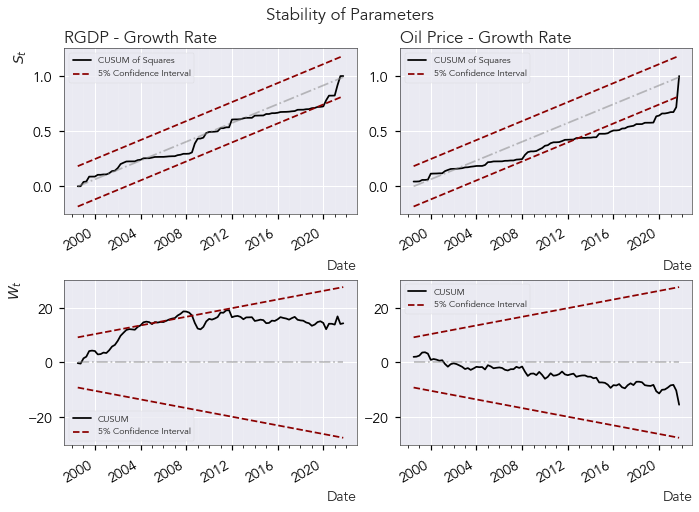

```python
### Create Plot with the information of the Cumulative Sum Squares Test

fig, axes = plt.subplots(nrows = 2, ncols = 2, figsize = (6.4 * 1.5, 7), constrained_layout = True)


labels = ['RGDP - Growth Rate', 'Oil Price Growth Rate']
ylabels = ['$S_t$', None, '$W_t$', None]

axes[0][0].plot(x0_c2rgdp, y0_c2rgdp, linestyle = 'solid', color = 'black', label = 'CUSUM of Squares')
axes[0][0].plot(x1_c2rgdp, y1_c2rgdp, linestyle = '-.', color = 'grey', alpha = 0.5)
axes[0][0].plot(x2_c2rgdp, y2_c2rgdp, linestyle = '--', color = 'darkred', label = '5% Confidence Interval')
axes[0][0].plot(x3_c2rgdp, y3_c2rgdp, linestyle = '--', color = 'darkred')
#axes[0].hlines(y = 0, xmin = 0, xmax = 50, color = 'grey', linestyle = '-.')

axes[0][1].plot(x0_c2oil, y0_c2oil, linestyle = 'solid', color = 'black', label = 'CUSUM of Squares')
axes[0][1].plot(x1_c2oil, y1_c2oil, linestyle = '-.', color = 'grey', alpha = 0.5)
axes[0][1].plot(x2_c2oil, y2_c2oil, linestyle = '--', color = 'darkred', label = '5% Confidence Interval')
axes[0][1].plot(x3_c2oil, y3_c2oil, linestyle = '--', color = 'darkred')


# PLOT CUSUM
axes[1][0].plot(x0_crgdp, y0_crgdp, linestyle = 'solid', color = 'black', label = 'CUSUM')
axes[1][0].plot(x1_crgdp, y1_crgdp, linestyle = '--', color = 'darkred')
axes[1][0].plot(x2_crgdp, y2_crgdp, linestyle = '--', color = 'darkred', label = '5% Confidence Interval')
axes[1][0].hlines(y = 0, xmin = x2_crgdp.min(), xmax = x2_crgdp.max(), color = 'grey', linestyle = '-.',alpha = 0.5)
#axes[0].hlines(y = 0, xmin = 0, xmax = 50, color = 'grey', linestyle = '-.')

axes[1][1].plot(x0_coil, y0_coil, linestyle = 'solid', color = 'black', label = 'CUSUM')
axes[1][1].plot(x1_coil, y1_coil, linestyle = '--', color = 'darkred')
axes[1][1].plot(x2_coil, y2_coil, linestyle = '--', color = 'darkred', label = '5% Confidence Interval')
axes[1][1].hlines(y = 0, xmin = x2_crgdp.min(), xmax = x2_crgdp.max(), color = 'grey', linestyle = '-.',alpha = 0.5)

#axes[1].hlines(y = 0, xmin = 0, xmax = 50, color = 'grey', linestyle = '-.')

# Format axis
#ylabel = ['R. RGDP-Growth', 'R. OIl P. - Growth']
titles = ['RGDP - Growth Rate', 'Oil Price - Growth Rate', None, None]
for i, ax in enumerate(axes.flatten()):
    ax.set_ylabel(ylabels[i], loc = 'top', fontsize = 'medium')
    ax.set_xlabel('Date', loc = 'right', fontsize = 'medium')
    ax.set_title(titles[i], fontsize = 'large', fontweight = 'bold', loc = 'left')
    ax.legend(fontsize = 9, frameon = True)
    #ax.xaxis.set_major_locator(mdates.YearLocator(base = 2, month = 1, day = 1))
    #ax.xaxis.set_major_formatter(
        #mdates.ConciseDateFormatter(ax.xaxis.get_major_locator()))
    ax.grid(True, which = 'minor', color = 'white', alpha = 0.1)
    ax.xaxis.set_minor_locator(mpl.ticker.AutoMinorLocator())
    #ax.yaxis.set_minor_locator(mpl.ticker.AutoMinorLocator())

    #ax.legend(fontsize = 14, frameon = True)

    for label in axes[0][0].get_xticklabels(which='major'):
        label.set(rotation=30, horizontalalignment='right')

    for label in axes[1][0].get_xticklabels(which='major'):
        label.set(rotation=30, horizontalalignment='right')

    for label in axes[1][1].get_xticklabels(which='major'):
        label.set(rotation=30, horizontalalignment='right')

    for label in axes[0][1].get_xticklabels(which='major'):
        label.set(rotation=30, horizontalalignment='right')
    ax.tick_params(which = 'major', colors = 'black', length = 5, width = 1.2,
               labelsize = 'medium')
    ax.tick_params(which = 'minor', length = 3, colors = 'black', width = 0.8)
fig.suptitle('Stability of Parameters')

#fig.savefig(save_graph + '15_CUSUM.png', bbox_inches = 'tight')
```

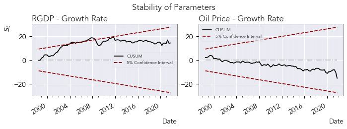

```python
# Get only cumulative sum
### Create Plot with the information of the Cumulative Sum Squares Test

fig, axes = plt.subplots(nrows = 1, ncols = 2, figsize = (6.4 * 1.5, 3.5), constrained_layout = True)


labels = ['RGDP - Growth Rate', 'Oil Price Growth Rate']
ylabels = ['$S_t$', None, '$W_t$', None]



# PLOT CUSUM
axes[0].plot(x0_crgdp, y0_crgdp, linestyle = 'solid', color = 'black', label = 'CUSUM')
axes[0].plot(x1_crgdp, y1_crgdp, linestyle = '--', color = 'darkred')
axes[0].plot(x2_crgdp, y2_crgdp, linestyle = '--', color = 'darkred', label = '5% Confidence Interval')
axes[0].hlines(y = 0, xmin = x2_crgdp.min(), xmax = x2_crgdp.max(), color = 'grey', linestyle = '-.',alpha = 0.5)
#axes[0].hlines(y = 0, xmin = 0, xmax = 50, color = 'grey', linestyle = '-.')

axes[1].plot(x0_coil, y0_coil, linestyle = 'solid', color = 'black', label = 'CUSUM')
axes[1].plot(x1_coil, y1_coil, linestyle = '--', color = 'darkred')
axes[1].plot(x2_coil, y2_coil, linestyle = '--', color = 'darkred', label = '5% Confidence Interval')
axes[1].hlines(y = 0, xmin = x2_crgdp.min(), xmax = x2_crgdp.max(), color = 'grey', linestyle = '-.',alpha = 0.5)

#axes[1].hlines(y = 0, xmin = 0, xmax = 50, color = 'grey', linestyle = '-.')

# Format axis
#ylabel = ['R. RGDP-Growth', 'R. OIl P. - Growth']
titles = ['RGDP - Growth Rate', 'Oil Price - Growth Rate', None, None]
for i, ax in enumerate(axes.flatten()):
    ax.set_ylabel(ylabels[i], loc = 'top', fontsize = 'medium')
    ax.set_xlabel('Date', loc = 'right', fontsize = 'medium')
    ax.set_title(titles[i], fontsize = 'large', fontweight = 'bold', loc = 'left')
    ax.legend(fontsize = 9, frameon = True)
    #ax.xaxis.set_major_locator(mdates.YearLocator(base = 2, month = 1, day = 1))
    #ax.xaxis.set_major_formatter(
        #mdates.ConciseDateFormatter(ax.xaxis.get_major_locator()))
    ax.grid(True, which = 'minor', color = 'white', alpha = 0.1)
    ax.xaxis.set_minor_locator(mpl.ticker.AutoMinorLocator())
    #ax.yaxis.set_minor_locator(mpl.ticker.AutoMinorLocator())

    #ax.legend(fontsize = 14, frameon = True)

    for label in axes[0].get_xticklabels(which='major'):
        label.set(rotation=30, horizontalalignment='right')

    for label in axes[1].get_xticklabels(which='major'):
        label.set(rotation=30, horizontalalignment='right')


    ax.tick_params(which = 'major', colors = 'black', length = 5, width = 1.2,
               labelsize = 'medium')
    ax.tick_params(which = 'minor', length = 3, colors = 'black', width = 0.8)
fig.suptitle('Stability of Parameters')

#fig.savefig(save_graph + '15.2_CUSUM.png', bbox_inches = 'tight')
```

### **Extra: Model Without year 2021**

```python
ddata_2021 = ddata.iloc[:-4, :].copy()
```

```python
model_2021 = VAR(ddata_2021).fit(ic = 'bic', trend = 'c')
```

```python
model_2021.summary()
```

```
  Summary of Regression Results
==================================
Model:                         VAR
Method:                        OLS
Date:           Mon, 15, Aug, 2022
Time:                     20:47:14
--------------------------------------------------------------------
No. of Equations:         2.00000    BIC:                   -12.8141
Nobs:                     99.0000    HQIC:                  -13.0950
Log likelihood:           394.703    FPE:                1.69995e-06
AIC:                     -13.2859    Det(Omega_mle):     1.42843e-06
--------------------------------------------------------------------
Results for equation dOIL
===========================================================================
              coefficient       std. error           t-stat            prob
---------------------------------------------------------------------------
const            0.006184         0.006149            1.006           0.315
L1.dOIL          0.558141         0.105200            5.306           0.000
L1.dRGDP        -0.140898         0.127670           -1.104           0.270
L2.dOIL          0.323965         0.111049            2.917           0.004
L2.dRGDP        -0.226310         0.122026           -1.855           0.064
L3.dOIL         -0.291431         0.118787           -2.453           0.014
L3.dRGDP        -0.344949         0.125901           -2.740           0.006
L4.dOIL          0.028301         0.104321            0.271           0.786
L4.dRGDP         0.127601         0.135287            0.943           0.346
===========================================================================

Results for equation dRGDP
===========================================================================
              coefficient       std. error           t-stat            prob
---------------------------------------------------------------------------
const            0.004988         0.002989            1.669           0.095
L1.dOIL          0.053349         0.051142            1.043           0.297
L1.dRGDP        -0.125705         0.062066           -2.025           0.043
L2.dOIL          0.193047         0.053986            3.576           0.000
L2.dRGDP        -0.224320         0.059322           -3.781           0.000
L3.dOIL         -0.032063         0.057748           -0.555           0.579
L3.dRGDP        -0.190244         0.061206           -3.108           0.002
L4.dOIL         -0.012879         0.050715           -0.254           0.800
L4.dRGDP         0.822452         0.065769           12.505           0.000
===========================================================================

Correlation matrix of residuals
             dOIL     dRGDP
dOIL     1.000000 -0.058280
dRGDP   -0.058280  1.000000
```

```python
model_2021.test_causality(causing ='dRGDP', caused = 'dOIL', kind = 'Wald').summary()
```

Granger causality Wald-test. H_0: dRGDP does not Granger-cause dOIL. Conclusion: reject H_0 at 5% significance level.

| Test statistic | Critical value | p-value | df |
| --- | --- | --- | --- |
| 60.49 | 9.488 | 0.000 | 4 |

```python
help(model_2021.test_causality)
```

[output not shown]

```python
test_statistic, p_values = smts.stattools.breakvar_heteroskedasticity_test(results.resid['dRGDP'], subset_length = 1/3, alternative = 'two-sided', use_f = False)
```

```python
p_values
```

$\displaystyle 0.816143926065104$

```python
results.summary()
```

```
  Summary of Regression Results
==================================
Model:                         VAR
Method:                        OLS
Date:           Mon, 15, Aug, 2022
Time:                     20:47:17
--------------------------------------------------------------------
No. of Equations:         2.00000    BIC:                   -12.3119
Nobs:                     103.000    HQIC:                  -12.5858
Log likelihood:           383.472    FPE:                2.84087e-06
AIC:                     -12.7723    Det(Omega_mle):     2.40264e-06
--------------------------------------------------------------------
Results for equation dOIL
===========================================================================
              coefficient       std. error           t-stat            prob
---------------------------------------------------------------------------
const            0.001378         0.007235            0.190           0.849
L1.dOIL          0.719453         0.121599            5.917           0.000
L1.dRGDP        -0.149428         0.150012           -0.996           0.319
L2.dOIL          0.224271         0.130936            1.713           0.087
L2.dRGDP        -0.193596         0.145493           -1.331           0.183
L3.dOIL         -0.443761         0.138729           -3.199           0.001
L3.dRGDP        -0.241825         0.146559           -1.650           0.099
L4.dOIL          0.061666         0.121824            0.506           0.613
L4.dRGDP         0.166993         0.158799            1.052           0.293
===========================================================================

Results for equation dRGDP
===========================================================================
              coefficient       std. error           t-stat            prob
---------------------------------------------------------------------------
const            0.006101         0.003164            1.928           0.054
L1.dOIL          0.063222         0.053175            1.189           0.234
L1.dRGDP        -0.176851         0.065601           -2.696           0.007
L2.dOIL          0.186109         0.057258            3.250           0.001
L2.dRGDP        -0.244963         0.063625           -3.850           0.000
L3.dOIL         -0.042889         0.060667           -0.707           0.480
L3.dRGDP        -0.217365         0.064091           -3.392           0.001
L4.dOIL          0.008199         0.053274            0.154           0.878
L4.dRGDP         0.781734         0.069443           11.257           0.000
===========================================================================

Correlation matrix of residuals
             dOIL     dRGDP
dOIL     1.000000  0.006062
dRGDP    0.006062  1.000000
```

## **Ch 7 | Forecasting and Variance Decomposition**

### **7.1. Obtain Forecast-Data**

```python
# Set the innitial values
lag_order = results.k_ar
print(lag_order)
```

```
4
```

```python
# Plot forecast
Forecast = results.plot_forecast(8);

# First forecast is for the growth rate of the OIL price
# Get data
ax = Forecast.axes[:]

# Get lines from the plot
line0_FC_dOIL = ax[0].get_lines()[0] # Series (my dataset)
x0_FC_dOIL = line0_FC_dOIL.get_xdata()
y0_FC_dOIL = line0_FC_dOIL.get_ydata()

line1_FC_dOIL = ax[0].get_lines()[1] # Forecasted value
x1_FC_dOIL = line1_FC_dOIL.get_xdata()
y1_FC_dOIL = line1_FC_dOIL.get_ydata()

line2_FC_dOIL = ax[0].get_lines()[2] # Lower error band
x2_FC_dOIL = line2_FC_dOIL.get_xdata()
y2_FC_dOIL = line2_FC_dOIL.get_ydata()

line3_FC_dOIL = ax[0].get_lines()[3] # Upper error band
x3_FC_dOIL = line3_FC_dOIL.get_xdata()
y3_FC_dOIL = line3_FC_dOIL.get_ydata()



# Get upper and lower bands for forecast of drgdp
line2_FC_dRGDP = ax[1].get_lines()[2] # Lower error Band
x2_FC_dRGDP = line2_FC_dRGDP.get_xdata()
y2_FC_dRGDP = line2_FC_dRGDP.get_ydata()

line3_FC_dRGDP = ax[1].get_lines()[3] # Upper error band
x3_FC_dRGDP = line3_FC_dRGDP.get_xdata()
y3_FC_dRGDP = line3_FC_dRGDP.get_ydata()

plt.close()
```

```python
# Forecast the next 2 years (8 periods)
Forecast =  results.forecast(ddata.values[-lag_order: ], 8)
indexes = ['2022-01-01', '2022-04-01', '2022-07-01', '2022-10-01', '2023-01-01', '2023-04-01', '2023-07-01', '2023-10-01']
Forecast_pd = pd.DataFrame({
    'dOIL': np.asarray(Forecast[: , 0]),
    'dRGDP': Forecast[:, 1]
}, index = indexes)

Forecast_pd.index = pd.to_datetime(Forecast_pd.index, format = '%Y-%m-%d')

#python_df = pd.concat([country_respondents, country_python_users], axis = 'columns', sort = False)
#Forecast_pd = pd.concat([ddata, Forecast_pd], axis = 'rows', sort = False)

ErrorBands_pd = pd.DataFrame({
    'dOIL_lower': y2_FC_dOIL,
    'dOIL_upper': y3_FC_dOIL,
    'dRGDP_lower': y2_FC_dRGDP,
    'dRGDP_upper': y3_FC_dRGDP
}, index = indexes)

ErrorBands_pd.index = pd.to_datetime(Forecast_pd.index, format = '%Y-%m-%d')


Union1_oil = np.asarray(ddata.iloc[-1, 0])
Union2_oil = np.asarray(Forecast_pd.iloc[0, 0])
Union1_rgdp = np.asarray(ddata.iloc[-1, 1])
Union2_rgdp = np.asarray(Forecast_pd.iloc[0, 1])
Union = pd.DataFrame({
    'dOIL': [Union1_oil, Union2_oil],
    'dRGDP': [Union1_rgdp, Union2_rgdp]
})

Union.index = ddata.index[-1], Forecast_pd.index[0]

Forecast_pd, Union
```

```
(                dOIL     dRGDP
 2022-01-01 -0.351897 -0.256285
 2022-04-01 -0.270319 -0.010192
 2022-07-01 -0.103923  0.034345
 2022-10-01  0.081201  0.104456
 2023-01-01  0.072158 -0.224415
 2023-04-01  0.104254  0.026684
 2023-07-01  0.070058  0.076185
 2023-10-01  0.103312  0.137931,
                             dOIL                dRGDP
 2021-10-01   -0.3097870700884471  0.11583387645519494
 2022-01-01  -0.35189699396737567  -0.2562848904413032)
```

### **7.2. Plot The Forecasted Data**

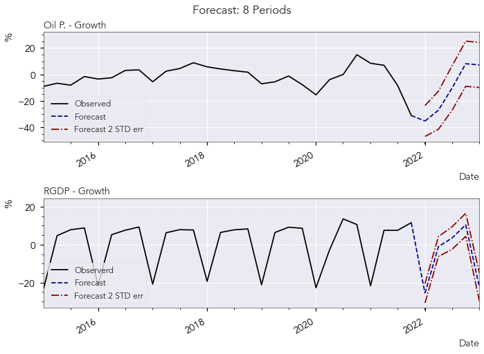

```python
# Plot Forecasted Data
import datetime
# First Plot the Dataset (ddata)
fig, axes = plt.subplots(nrows = 2, ncols = 1, figsize = (6.4 * 1.5, 7), constrained_layout = True)

axes[0].plot(ddata['dOIL'] * 100, linestyle = 'solid', color = 'black', label = 'Observed')
axes[1].plot(ddata['dRGDP'] * 100, linestyle = 'solid', color = 'black', label = 'Observerd')
# Plot the Forecasted data
axes[0].plot(Forecast_pd['dOIL'] * 100, color = 'darkblue', label = 'Forecast', linestyle = '--')
axes[1].plot(Forecast_pd['dRGDP'] * 100, color = 'darkblue', label = 'Forecast', linestyle = '--')

axes[0].plot(Union['dOIL'] * 100, color = 'darkblue', linestyle = '--')
axes[1].plot(Union['dRGDP'] * 100, color = 'darkblue', linestyle = '--')

# Confidence interval
axes[0].plot(ErrorBands_pd['dOIL_lower'] * 100, color = 'darkred', linestyle = '-.', label = 'Forecast 2 STD err')
axes[0].plot(ErrorBands_pd['dOIL_upper'] * 100, color = 'darkred', linestyle = '-.')
axes[1].plot(ErrorBands_pd['dRGDP_lower'] * 100, color = 'darkred', linestyle = '-.', label = 'Forecast 2 STD err')
axes[1].plot(ErrorBands_pd['dRGDP_upper'] * 100, color = 'darkred', linestyle = '-.')


axes[0].set_xlim(datetime.date(2015, 1, 1), datetime.date(2023, 1, 1))
axes[1].set_xlim(datetime.date(2015, 1, 1), datetime.date(2023, 1, 1))


# Format axis
Titles = ['Oil P. - Growth', 'RGDP - Growth']

for i, ax in enumerate(axes.flatten()):
    ax.set_ylabel('$\%$', loc = 'top', fontsize = 'medium')
    ax.set_xlabel('Date', loc = 'right', fontsize = 'medium')
    ax.set_title(Titles[i], fontsize = 'medium', fontweight = 'bold', loc = 'left')
    ax.xaxis.set_major_locator(mdates.YearLocator(base = 2, month = 1, day = 1))
    ax.xaxis.set_major_formatter(
        mdates.ConciseDateFormatter(ax.xaxis.get_major_locator()))
    ax.grid(True, which = 'minor', color = 'white', alpha = 0.1)
    #ax.xaxis.set_major_locator(mpl.ticker.AutoMajorlocator())
    ax.xaxis.set_minor_locator(mpl.ticker.AutoMinorLocator())
    ax.yaxis.set_minor_locator(mpl.ticker.AutoMinorLocator())

    ax.legend(fontsize = 12, frameon = True, loc = 'lower left')

    for label in ax.get_xticklabels(which='major'):
        label.set(rotation=30, horizontalalignment='right')

    ax.tick_params(which = 'major', colors = 'black', length = 5, width = 1.2,
               labelsize = 'medium')
    ax.tick_params(which = 'minor', length = 3, colors = 'black', width = 0.8)

fig.suptitle('Forecast: 8 Periods')
#fig(save_graph + '21_Forecast.png', bbox_inches = 'tight')
```

### **7.3. Variance Decomposition**

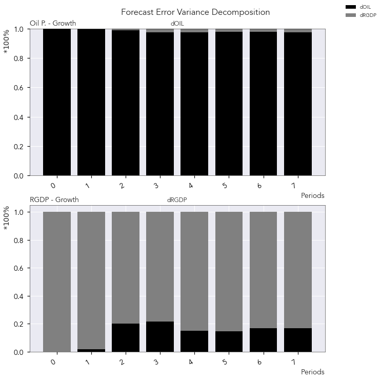

```python
Variance_Decomp = results.fevd(8).plot();

axes = Variance_Decomp.axes[:]
fig = plt.gcf()
Titles = ['Oil P. - Growth', 'RGDP - Growth']

for i, ax in enumerate(axes):
    ax.set_ylabel('$*100\%$', loc = 'top', fontsize = 'medium')
    ax.set_xlabel('Periods', loc = 'right', fontsize = 'medium')
    ax.set_title(Titles[i], fontsize = 'medium', fontweight = 'bold', loc = 'left')



    for label in ax.get_xticklabels(which='major'):
        label.set(rotation=30, horizontalalignment='right')

    ax.tick_params(which = 'major', colors = 'black', length = 5, width = 1.2,
               labelsize = 'medium')
    ax.tick_params(which = 'minor', length = 3, colors = 'black', width = 0.8)

fig.suptitle('Forecast Error Variance Decomposition')
#fig.savefig(save_graph + '22_VAR_Decomposition.png', bbox_inches = 'tight')
```

```python
print(results.fevd(8).summary())
```

```
FEVD for dOIL
         dOIL     dRGDP
0    1.000000  0.000000
1    0.997193  0.002807
2    0.990972  0.009028
3    0.976600  0.023400
4    0.976600  0.023400
5    0.977441  0.022559
6    0.978116  0.021884
7    0.976532  0.023468

FEVD for dRGDP
         dOIL     dRGDP
0    0.000037  0.999963
1    0.019612  0.980388
2    0.201806  0.798194
3    0.217134  0.782866
4    0.150007  0.849993
5    0.146015  0.853985
6    0.168041  0.831959
7    0.166949  0.833051


None
```